# Tarea Metodos Numericos

Liliana Contreras Segundo

17 noviembre, 2025

# Ejercicios a mano

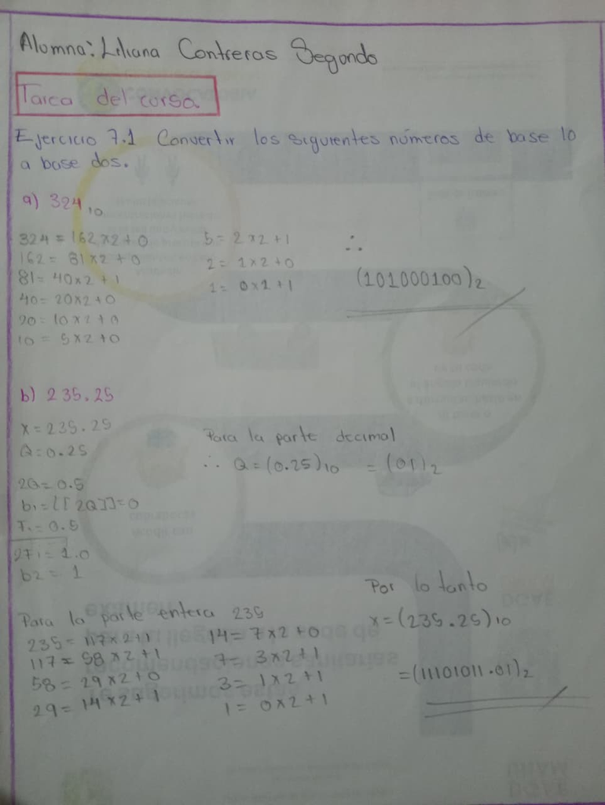

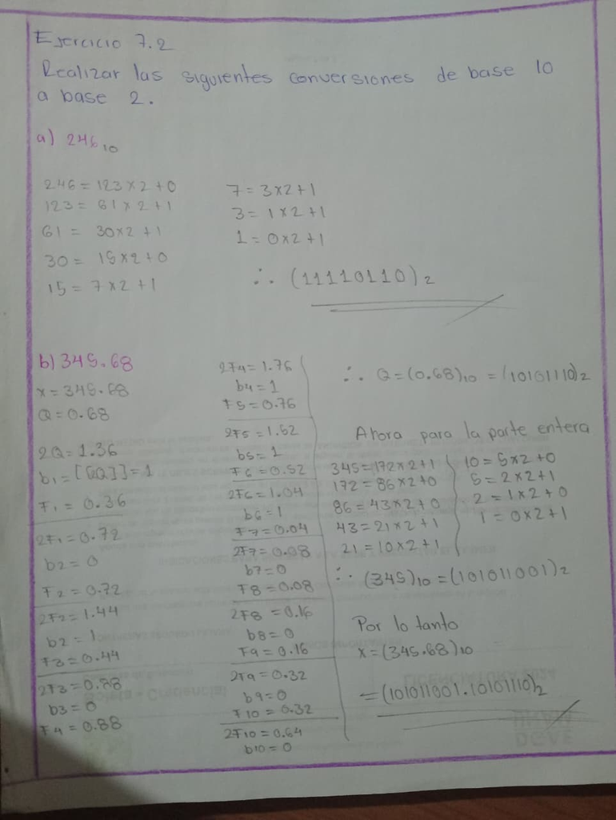

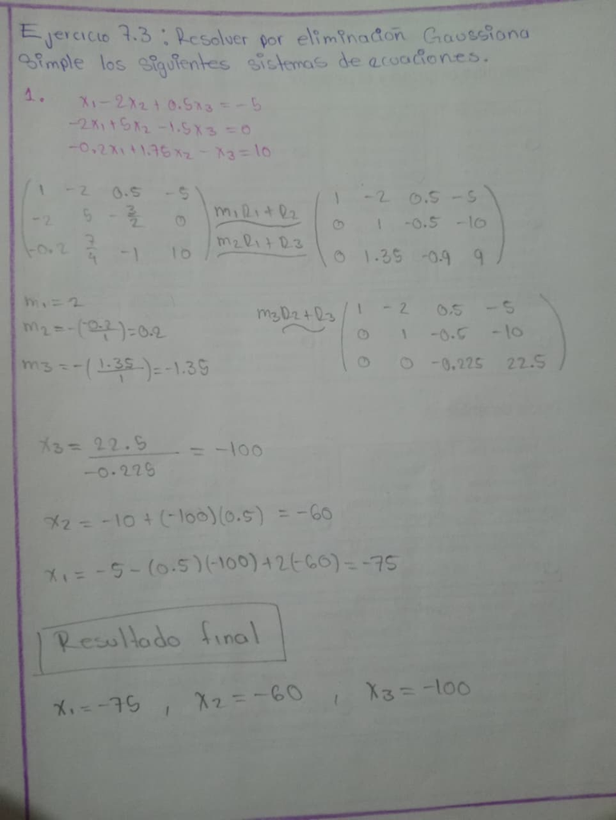

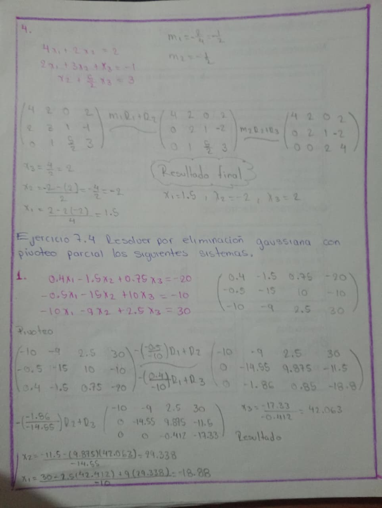

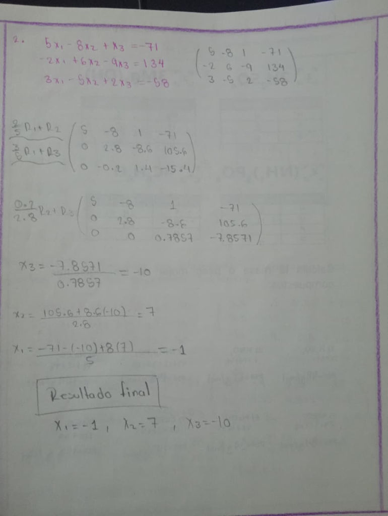

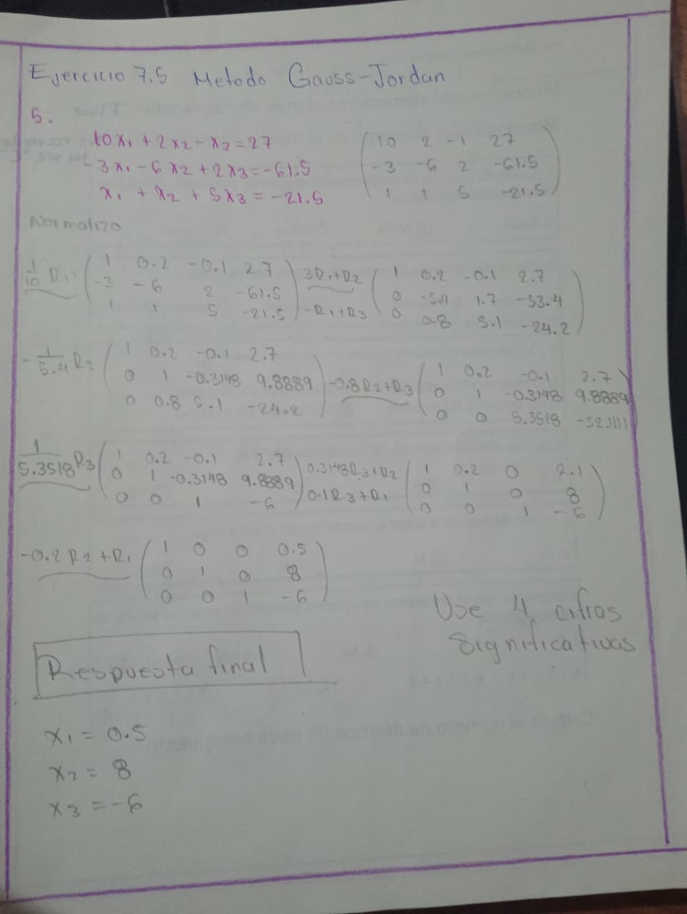

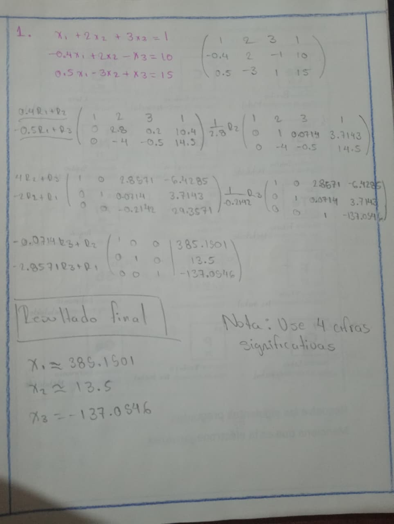

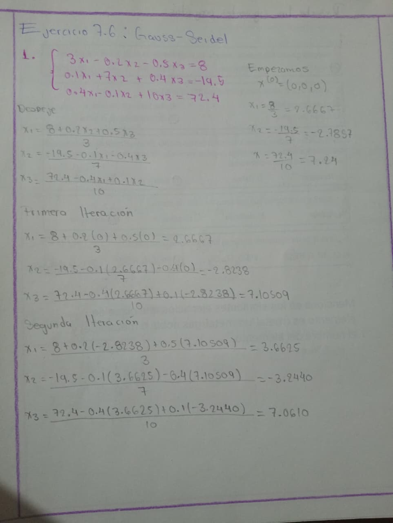

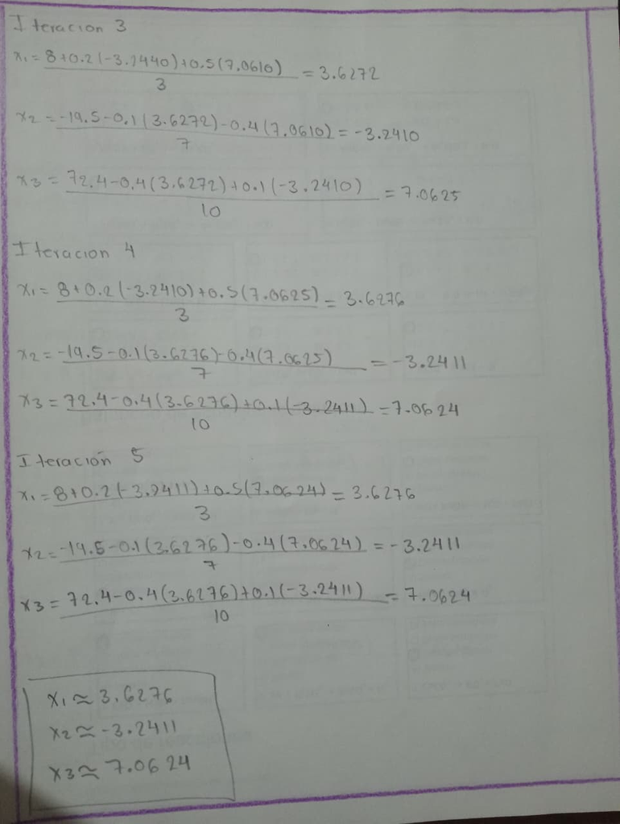

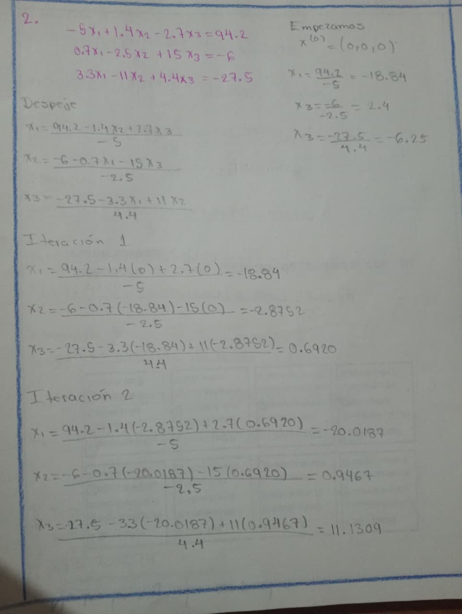

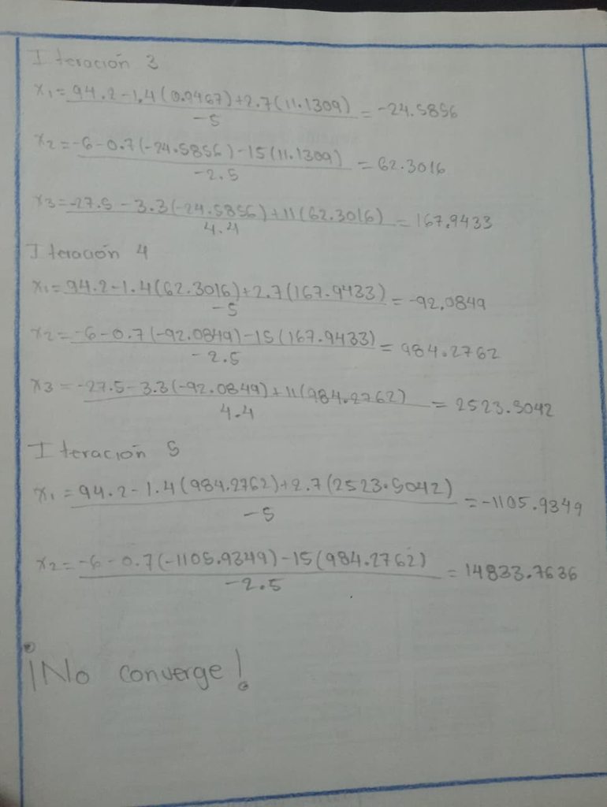

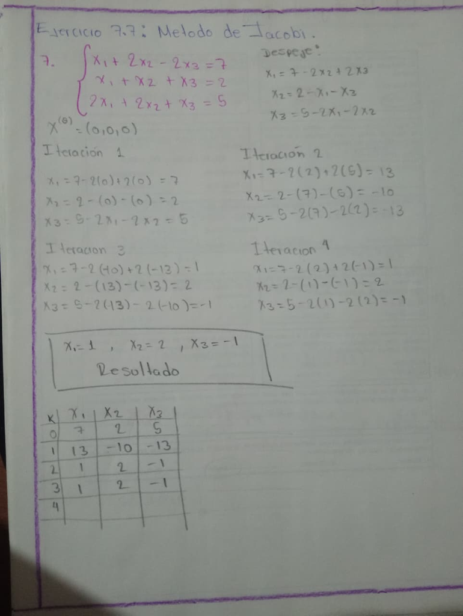

[1 more figures not shown]

# Ejercicio 7.1. Números de base 10 a base 2.

## Ejercicio 1: 324

```r
numero <- 324
cat("Convirtiendo", numero, "de base 10 a base 2:\n")
```

```
## Convirtiendo 324 de base 10 a base 2:
```

```r
resultado <- c()

while (numero > 0) {
  residuo <- numero %% 2
  cociente <- numero %/% 2
  cat(numero, "÷ 2 =", cociente, "residuo", residuo, "\n")
  resultado <- c(residuo, resultado)
  numero <- cociente
}
```

```
## 324 ÷ 2 = 162 residuo 0
## 162 ÷ 2 = 81 residuo 0
## 81 ÷ 2 = 40 residuo 1
## 40 ÷ 2 = 20 residuo 0
## 20 ÷ 2 = 10 residuo 0
## 10 ÷ 2 = 5 residuo 0
## 5 ÷ 2 = 2 residuo 1
## 2 ÷ 2 = 1 residuo 0
## 1 ÷ 2 = 0 residuo 1
```

### Resultado

```r
num_original <- 324

binario <- paste(resultado, collapse = "")
cat("\nResultado:", num_original, "en base 10 =", binario, "en base 2\n")
```

```
##
## Resultado: 324 en base 10 = 101000100 en base 2
```

## Ejercicio 2: 27

```r
numero <- 27
cat("Convirtiendo", numero, "de base 10 a base 2:\n")
```

```
## Convirtiendo 27 de base 10 a base 2:
```

```r
resultado <- c()

while (numero > 0) {
  residuo <- numero %% 2
  cociente <- numero %/% 2
  cat(numero, "÷ 2 =", cociente, "residuo", residuo, "\n")
  resultado <- c(residuo, resultado)
  numero <- cociente
}
```

```
## 27 ÷ 2 = 13 residuo 1
## 13 ÷ 2 = 6 residuo 1
## 6 ÷ 2 = 3 residuo 0
## 3 ÷ 2 = 1 residuo 1
## 1 ÷ 2 = 0 residuo 1
```

### Resultado

```r
num_original <- 27

binario <- paste(resultado, collapse = "")
cat("\nResultado:", num_original, "en base 10 =", binario, "en base 2\n")
```

```
##
## Resultado: 27 en base 10 = 11011 en base 2
```

## Ejercicio 3: 1423

```r
numero <- 1423
cat("Convirtiendo", numero, "de base 10 a base 2:\n")
```

```
## Convirtiendo 1423 de base 10 a base 2:
```

```r
resultado <- c()

while (numero > 0) {
  residuo <- numero %% 2
  cociente <- numero %/% 2
  cat(numero, "÷ 2 =", cociente, "residuo", residuo, "\n")
  resultado <- c(residuo, resultado)
  numero <- cociente
}
```

```
## 1423 ÷ 2 = 711 residuo 1
## 711 ÷ 2 = 355 residuo 1
## 355 ÷ 2 = 177 residuo 1
## 177 ÷ 2 = 88 residuo 1
## 88 ÷ 2 = 44 residuo 0
## 44 ÷ 2 = 22 residuo 0
## 22 ÷ 2 = 11 residuo 0
## 11 ÷ 2 = 5 residuo 1
## 5 ÷ 2 = 2 residuo 1
## 2 ÷ 2 = 1 residuo 0
## 1 ÷ 2 = 0 residuo 1
```

### Resultado

```r
num_original <- 1423

binario <- paste(resultado, collapse = "")
cat("\nResultado:", num_original, "en base 10 =", binario, "en base 2\n")
```

```
##
## Resultado: 1423 en base 10 = 10110001111 en base 2
```

## Ejercicio 4: 235.25

```r
numero <- 235.25
cat("Convirtiendo", numero, "de base 10 a base 2:\n")
```

```
## Convirtiendo 235.25 de base 10 a base 2:
```

```r
# Parte ENTERA (igual que antes)
parte_entera <- floor(numero)
resultado_entera <- c()
temp <- parte_entera

cat("--- Parte entera ---\n")
```

```
## --- Parte entera ---
```

```r
while (temp > 0) {
  residuo <- temp %% 2
  cociente <- temp %/% 2
  cat(temp, "÷ 2 =", cociente, "residuo", residuo, "\n")
  resultado_entera <- c(residuo, resultado_entera)
  temp <- cociente
}
```

```
## 235 ÷ 2 = 117 residuo 1
## 117 ÷ 2 = 58 residuo 1
## 58 ÷ 2 = 29 residuo 0
## 29 ÷ 2 = 14 residuo 1
## 14 ÷ 2 = 7 residuo 0
## 7 ÷ 2 = 3 residuo 1
## 3 ÷ 2 = 1 residuo 1
## 1 ÷ 2 = 0 residuo 1
```

```r
binario_entera <- paste(resultado_entera, collapse = "")
if (binario_entera == "") binario_entera <- "0"

# Parte DECIMAL (sin if/else)
parte_decimal <- numero - parte_entera
resultado_decimal <- c()
temp <- parte_decimal

cat("--- Parte decimal ---\n")
```

```
## --- Parte decimal ---
```

```r
contador <- 0
while (temp > 0 && contador < 8) {
  temp <- temp * 2

  digito <- floor(temp)
  resultado_decimal <- c(resultado_decimal, digito)
  cat(temp, "→ dígito", digito, "\n")
  temp <- temp - digito
  contador <- contador + 1
}
```

```
## 0.5 → dígito 0
## 1 → dígito 1
```

```r
binario_decimal <- paste(resultado_decimal, collapse = "")

cat("\nResultado:", numero, "=", binario_entera, ".", binario_decimal, "en base 2\n")
```

```
##
## Resultado: 235.25 = 11101011 . 01 en base 2
```

## Ejercicio 4: 41.596

```r
numero <- 41.596
cat("Convirtiendo", numero, "de base 10 a base 2:\n")
```

```
## Convirtiendo 41.596 de base 10 a base 2:
```

```r
# Parte ENTERA (igual que antes)
parte_entera <- floor(numero)
resultado_entera <- c()
temp <- parte_entera

cat("--- Parte entera ---\n")
```

```
## --- Parte entera ---
```

```r
while (temp > 0) {
  residuo <- temp %% 2
  cociente <- temp %/% 2
  cat(temp, "÷ 2 =", cociente, "residuo", residuo, "\n")
  resultado_entera <- c(residuo, resultado_entera)
  temp <- cociente
}
```

```
## 41 ÷ 2 = 20 residuo 1
## 20 ÷ 2 = 10 residuo 0
## 10 ÷ 2 = 5 residuo 0
## 5 ÷ 2 = 2 residuo 1
## 2 ÷ 2 = 1 residuo 0
## 1 ÷ 2 = 0 residuo 1
```

```r
binario_entera <- paste(resultado_entera, collapse = "")
if (binario_entera == "") binario_entera <- "0"

parte_decimal <- numero - parte_entera
resultado_decimal <- c()
temp <- parte_decimal

cat("--- Parte decimal ---\n")
```

```
## --- Parte decimal ---
```

```r
contador <- 0
while (temp > 0 && contador < 8) {
  temp <- temp * 2

  digito <- floor(temp)
  resultado_decimal <- c(resultado_decimal, digito)
  cat(temp, "→ dígito", digito, "\n")
  temp <- temp - digito
  contador <- contador + 1
}
```

```
## 1.192 → dígito 1
## 0.384 → dígito 0
## 0.768 → dígito 0
## 1.536 → dígito 1
## 1.072 → dígito 1
## 0.144 → dígito 0
## 0.288 → dígito 0
## 0.576 → dígito 0
```

```r
binario_decimal <- paste(resultado_decimal, collapse = "")

cat("\nResultado:", numero, "=", binario_entera, ".", binario_decimal, "en base 2\n")
```

```
##
## Resultado: 41.596 = 101001 . 10011000 en base 2
```

# Ejercicio 7.2:

## 1. Realizar una revisión de la historia de los métodos numéricos, elaborar un documento de hasta dos cuartillas:

```r
Texto <-"            #Historia y Evolución de los Métodos Numéricos


Los métodos numéricos constituyen una herramienta fundamental en la ciencia y la ingeniería moderna, permitiendo resolver problemas complejos que la matemática analítica no puede abordar de forma eficiente o exacta. Se definen como procesos matemáticos iterativos diseñados para encontrar una aproximación a una solución específica con un error previamente determinado (Cortés Rosas et al., 2019). La historia de estos métodos es, en esencia, la crónica de la búsqueda humana por cuantificar, predecir y comprender el mundo a través de la aproximación sucesiva.


Los Orígenes: La Antigüedad y las Primeras Aproximaciones

La necesidad de emplear métodos numéricos es tan antigua como las matemáticas mismas. Uno de los ejemplos más tempranos se remonta al 1650 a.C., con los Papiros de Rhyad, que contenían técnicas para resolver expresiones matemáticas sin álgebra. Un hito fundamental ocurrió alrededor del 250 a.C., cuando Euclides desarrolló el **Método de Exhausción**, utilizando figuras geométricas inscritas en un círculo para aproximar el valor de π. Este método representaba un principio iterativo rudimentario: al aumentar el número de lados del polígono, la aproximación al área del círculo (y por ende a π) se hacía más precisa.

Posteriormente, en el Siglo IX d.C., el matemático persa Al-Juarismi sentó las bases de los algoritmos, que son el corazón de cualquier método numérico. Sin embargo, fue durante el Siglo XVII y XVIII cuando se sentaron las bases teóricas más sólidas. Isaac Newton y Gottfried Leibniz, con la creación del cálculo diferencial e integral, abrieron la puerta a la resolución de problemas de cambio y movimiento. Figuras como Brook Taylor, con su serie de polinomios para aproximar funciones, y Leonhard Euler, con soluciones numéricas para ecuaciones diferenciales, proporcionaron las herramientas analíticas que más tarde se convertirían en algoritmos computacionales.


La Revolución de la Computación: La Materialización de los Métodos

Hasta el siglo XIX, la aplicación de estos métodos era una tarea extenuante y propensa a errores, realizada manualmente por calculistas. La invención de máquinas como la **Máquina Diferencial** de Charles Babbage (1822) y las ideas de Ada Lovelace sobre programación marcaron un punto de inflexión. La historia de los métodos numéricos se volvió, a partir de entonces, paralela a la historia de la computación (Cortés Rosas et al., 2019).
El siglo XX aceleró esta simbiosis. Alan Turing, con su concepto de una máquina universal en 1937, y John Von Neumann, con la arquitectura de computadoras stored-program, crearon el hardware necesario. Por otro lado, la necesidad de realizar cálculos balísticos y de energía nuclear durante la Segunda Guerra Mundial impulsó el desarrollo de métodos aplicados. Matemáticos como J. H. Wilkinson en el Reino Unido trabajaron en algoritmos para resolver sistemas de ecuaciones y calcular eigenvalores, problemas críticos para la ingeniería.
La creación de lenguajes de programación de alto nivel, como FORTRAN por John Backus en 1953, democratizó el uso de estos métodos, permitiendo a los científicos escribir instrucciones complejas de manera más sencilla. Proyectos de software matemático como EISPACK y LINPACK (décadas de 1970 y 1980) estandarizaron y optimizaron las rutinas numéricas. La culminación de esta tendencia fue el desarrollo de entornos como MATLAB por Cleve Moler en 1984, que integró poderosos métodos numéricos en una interfaz accesible, revolucionando la enseñanza y la práctica en ingeniería.


La Necesidad en la Ingeniería y el Manejo del Error

La ingeniería, como disciplina que aplica las ciencias básicas para resolver problemas reales, rara vez se enfrenta a modelos lineales o con soluciones exactas y enteras (Cortés Rosas et al., 2019). Los sistemas del mundo real —desde la aerodinámica de un avión hasta la resistencia de un puente— se modelan con ecuaciones no lineales y diferenciales cuya solución analítica es imposible o impráctica de obtener. Es aquí donde los métodos numéricos se vuelven indispensables.
A diferencia de los ejercicios algebraicos ideales, los métodos numéricos aceptan la imposibilidad de una solución perfecta y la sustituyen por una aproximación controlada. Mediante iteraciones, un valor inicial se refina sucesivamente hasta cumplir con una tolerancia de error predefinida. Sin embargo, esta potencia tiene una contrapartida fundamental: la gestión del error. Cada aproximación conlleva inherentemente errores de redondeo, truncamiento y modelado. Por lo tanto, un aspecto crucial del análisis numérico moderno no es solo la eficiencia del método, sino también el entendimiento y la cuantificación de estos errores para garantizar que la solución sea suficientemente buena para su aplicación práctica.
En conclusión, la historia de los métodos numéricos es un viaje desde la intuición geométrica de los antiguos hasta el cálculo de alta precisión impulsado por las supercomputadoras. Su evolución ha estado ligada al ingenio humano para crear herramientas, primero conceptuales como el algoritmo y luego físicas como la computadora, que permiten transformar problemas irresolubles analíticamente en soluciones numéricas prácticas y confiables, convirtiéndose en un pilar sin el cual la ingeniería moderna no podría existir.



Referencia
Cortés Rosas, J. J., González Cárdenas, M. E., Pinilla Morán, V. D., Salazar Moreno, A., & Tovar Pérez, V. H. (2019). Aproximación numérica y errores. Facultad de Ingeniería, UNAM. Proyecto PAPIME PE105717."
```

## 2. Realiza las siguientes conversiones de base 10 a base 2

### a) 246:

```r
numero <- 246
cat("Convirtiendo", numero, "de base 10 a base 2:\n")
```

```
## Convirtiendo 246 de base 10 a base 2:
```

```r
resultado <- c()

while (numero > 0) {
  residuo <- numero %% 2
  cociente <- numero %/% 2
  cat(numero, "÷ 2 =", cociente, "residuo", residuo, "\n")
  resultado <- c(residuo, resultado)
  numero <- cociente
}
```

```
## 246 ÷ 2 = 123 residuo 0
## 123 ÷ 2 = 61 residuo 1
## 61 ÷ 2 = 30 residuo 1
## 30 ÷ 2 = 15 residuo 0
## 15 ÷ 2 = 7 residuo 1
## 7 ÷ 2 = 3 residuo 1
## 3 ÷ 2 = 1 residuo 1
## 1 ÷ 2 = 0 residuo 1
```

```r
num_original <- 246
# Mostrar resultado
binario <- paste(resultado, collapse = "")
cat("\nResultado:", num_original, "en base 10 =", binario, "en base 2\n")
```

```
##
## Resultado: 246 en base 10 = 11110110 en base 2
```

### b) 345.68:

```r
numero <- 345.68
cat("Convirtiendo", numero, "de base 10 a base 2:\n")
```

```
## Convirtiendo 345.68 de base 10 a base 2:
```

```r
# Parte ENTERA (igual que antes)
parte_entera <- floor(numero)
resultado_entera <- c()
temp <- parte_entera

cat("--- Parte entera ---\n")
```

```
## --- Parte entera ---
```

```r
while (temp > 0) {
  residuo <- temp %% 2
  cociente <- temp %/% 2
  cat(temp, "÷ 2 =", cociente, "residuo", residuo, "\n")
  resultado_entera <- c(residuo, resultado_entera)
  temp <- cociente
}
```

```
## 345 ÷ 2 = 172 residuo 1
## 172 ÷ 2 = 86 residuo 0
## 86 ÷ 2 = 43 residuo 0
## 43 ÷ 2 = 21 residuo 1
## 21 ÷ 2 = 10 residuo 1
## 10 ÷ 2 = 5 residuo 0
## 5 ÷ 2 = 2 residuo 1
## 2 ÷ 2 = 1 residuo 0
## 1 ÷ 2 = 0 residuo 1
```

```r
binario_entera <- paste(resultado_entera, collapse = "")
if (binario_entera == "") binario_entera <- "0"

parte_decimal <- numero - parte_entera
resultado_decimal <- c()
temp <- parte_decimal

cat("--- Parte decimal ---\n")
```

```
## --- Parte decimal ---
```

```r
contador <- 0
while (temp > 0 && contador < 8) {
  temp <- temp * 2

  digito <- floor(temp)
  resultado_decimal <- c(resultado_decimal, digito)
  cat(temp, "→ dígito", digito, "\n")
  temp <- temp - digito
  contador <- contador + 1
}
```

```
## 1.36 → dígito 1
## 0.72 → dígito 0
## 1.44 → dígito 1
## 0.88 → dígito 0
## 1.76 → dígito 1
## 1.52 → dígito 1
## 1.04 → dígito 1
## 0.08 → dígito 0
```

```r
binario_decimal <- paste(resultado_decimal, collapse = "")

cat("\nResultado:", numero, "=", binario_entera, ".", binario_decimal, "en base 2\n")
```

```
##
## Resultado: 345.68 = 101011001 . 10101110 en base 2
```

### c) 4586632.2846:

```r
numero <- 4586632.2846
cat("Convirtiendo", numero, "de base 10 a base 2:\n")
```

```
## Convirtiendo 4586632 de base 10 a base 2:
```

```r
# Parte ENTERA (igual que antes)
parte_entera <- floor(numero)
resultado_entera <- c()
temp <- parte_entera

cat("--- Parte entera ---\n")
```

```
## --- Parte entera ---
```

```r
while (temp > 0) {
  residuo <- temp %% 2
  cociente <- temp %/% 2
  cat(temp, "÷ 2 =", cociente, "residuo", residuo, "\n")
  resultado_entera <- c(residuo, resultado_entera)
  temp <- cociente
}
```

```
## 4586632 ÷ 2 = 2293316 residuo 0
## 2293316 ÷ 2 = 1146658 residuo 0
## 1146658 ÷ 2 = 573329 residuo 0
## 573329 ÷ 2 = 286664 residuo 1
## 286664 ÷ 2 = 143332 residuo 0
## 143332 ÷ 2 = 71666 residuo 0
## 71666 ÷ 2 = 35833 residuo 0
## 35833 ÷ 2 = 17916 residuo 1
## 17916 ÷ 2 = 8958 residuo 0
## 8958 ÷ 2 = 4479 residuo 0
## 4479 ÷ 2 = 2239 residuo 1
## 2239 ÷ 2 = 1119 residuo 1
## 1119 ÷ 2 = 559 residuo 1
## 559 ÷ 2 = 279 residuo 1
## 279 ÷ 2 = 139 residuo 1
## 139 ÷ 2 = 69 residuo 1
## 69 ÷ 2 = 34 residuo 1
## 34 ÷ 2 = 17 residuo 0
## 17 ÷ 2 = 8 residuo 1
## 8 ÷ 2 = 4 residuo 0
## 4 ÷ 2 = 2 residuo 0
## 2 ÷ 2 = 1 residuo 0
## 1 ÷ 2 = 0 residuo 1
```

```r
binario_entera <- paste(resultado_entera, collapse = "")
if (binario_entera == "") binario_entera <- "0"

parte_decimal <- numero - parte_entera
resultado_decimal <- c()
temp <- parte_decimal

cat("--- Parte decimal ---\n")
```

```
## --- Parte decimal ---
```

```r
contador <- 0
while (temp > 0 && contador < 8) {
  temp <- temp * 2

  digito <- floor(temp)
  resultado_decimal <- c(resultado_decimal, digito)
  cat(temp, "→ dígito", digito, "\n")
  temp <- temp - digito
  contador <- contador + 1
}
```

```
## 0.5692 → dígito 0
## 1.1384 → dígito 1
## 0.2768 → dígito 0
## 0.5536 → dígito 0
## 1.1072 → dígito 1
## 0.2144 → dígito 0
## 0.4288 → dígito 0
## 0.8576 → dígito 0
```

```r
binario_decimal <- paste(resultado_decimal, collapse = "")

cat("\nResultado:", numero, "=", binario_entera, ".", binario_decimal, "en base 2\n")
```

```
##
## Resultado: 4586632 = 10001011111110010001000 . 01001000 en base 2
```

### d) 984365.27463:

```r
numero <- 984365.27463
cat("Convirtiendo", numero, "de base 10 a base 2:\n")
```

```
## Convirtiendo 984365.3 de base 10 a base 2:
```

```r
# Parte ENTERA (igual que antes)
parte_entera <- floor(numero)
resultado_entera <- c()
temp <- parte_entera

cat("--- Parte entera ---\n")
```

```
## --- Parte entera ---
```

```r
while (temp > 0) {
  residuo <- temp %% 2
  cociente <- temp %/% 2
  cat(temp, "÷ 2 =", cociente, "residuo", residuo, "\n")
  resultado_entera <- c(residuo, resultado_entera)
  temp <- cociente
}
```

```
## 984365 ÷ 2 = 492182 residuo 1
## 492182 ÷ 2 = 246091 residuo 0
## 246091 ÷ 2 = 123045 residuo 1
## 123045 ÷ 2 = 61522 residuo 1
## 61522 ÷ 2 = 30761 residuo 0
## 30761 ÷ 2 = 15380 residuo 1
## 15380 ÷ 2 = 7690 residuo 0
## 7690 ÷ 2 = 3845 residuo 0
## 3845 ÷ 2 = 1922 residuo 1
## 1922 ÷ 2 = 961 residuo 0
## 961 ÷ 2 = 480 residuo 1
## 480 ÷ 2 = 240 residuo 0
## 240 ÷ 2 = 120 residuo 0
## 120 ÷ 2 = 60 residuo 0
## 60 ÷ 2 = 30 residuo 0
## 30 ÷ 2 = 15 residuo 0
## 15 ÷ 2 = 7 residuo 1
## 7 ÷ 2 = 3 residuo 1
## 3 ÷ 2 = 1 residuo 1
## 1 ÷ 2 = 0 residuo 1
```

```r
binario_entera <- paste(resultado_entera, collapse = "")
if (binario_entera == "") binario_entera <- "0"

parte_decimal <- numero - parte_entera
resultado_decimal <- c()
temp <- parte_decimal

cat("--- Parte decimal ---\n")
```

```
## --- Parte decimal ---
```

```r
contador <- 0
while (temp > 0 && contador < 8) {
  temp <- temp * 2

  digito <- floor(temp)
  resultado_decimal <- c(resultado_decimal, digito)
  cat(temp, "→ dígito", digito, "\n")
  temp <- temp - digito
  contador <- contador + 1
}
```

```
## 0.54926 → dígito 0
## 1.09852 → dígito 1
## 0.19704 → dígito 0
## 0.39408 → dígito 0
## 0.78816 → dígito 0
## 1.57632 → dígito 1
## 1.15264 → dígito 1
## 0.30528 → dígito 0
```

```r
binario_decimal <- paste(resultado_decimal, collapse = "")

cat("\nResultado:", numero, "=", binario_entera, ".", binario_decimal, "en base 2\n")
```

```
##
## Resultado: 984365.3 = 11110000010100101101 . 01000110 en base 2
```

### e) 79905523:

```r
numero <- 79905523
cat("Convirtiendo", numero, "de base 10 a base 2:\n")
```

```
## Convirtiendo 79905523 de base 10 a base 2:
```

```r
resultado <- c()

while (numero > 0) {
  residuo <- numero %% 2
  cociente <- numero %/% 2
  cat(numero, "÷ 2 =", cociente, "residuo", residuo, "\n")
  resultado <- c(residuo, resultado)
  numero <- cociente
}
```

```
## 79905523 ÷ 2 = 39952761 residuo 1
## 39952761 ÷ 2 = 19976380 residuo 1
## 19976380 ÷ 2 = 9988190 residuo 0
## 9988190 ÷ 2 = 4994095 residuo 0
## 4994095 ÷ 2 = 2497047 residuo 1
## 2497047 ÷ 2 = 1248523 residuo 1
## 1248523 ÷ 2 = 624261 residuo 1
## 624261 ÷ 2 = 312130 residuo 1
## 312130 ÷ 2 = 156065 residuo 0
## 156065 ÷ 2 = 78032 residuo 1
## 78032 ÷ 2 = 39016 residuo 0
## 39016 ÷ 2 = 19508 residuo 0
## 19508 ÷ 2 = 9754 residuo 0
## 9754 ÷ 2 = 4877 residuo 0
## 4877 ÷ 2 = 2438 residuo 1
## 2438 ÷ 2 = 1219 residuo 0
## 1219 ÷ 2 = 609 residuo 1
## 609 ÷ 2 = 304 residuo 1
## 304 ÷ 2 = 152 residuo 0
## 152 ÷ 2 = 76 residuo 0
## 76 ÷ 2 = 38 residuo 0
## 38 ÷ 2 = 19 residuo 0
## 19 ÷ 2 = 9 residuo 1
## 9 ÷ 2 = 4 residuo 1
## 4 ÷ 2 = 2 residuo 0
## 2 ÷ 2 = 1 residuo 0
## 1 ÷ 2 = 0 residuo 1
```

```r
num_original <- 79905523
# Mostrar resultado
binario <- paste(resultado, collapse = "")
cat("\nResultado:", num_original, "en base 10 =", binario, "en base 2\n")
```

```
##
## Resultado: 79905523 en base 10 = 100110000110100001011110011 en base 2
```

## 4. Describe exhaustivamente los tipos de errores que existen:

```r
Texto <-"# Descripción Exhaustiva de los Tipos de Errores en el Análisis Numérico


En el ámbito de la ingeniería y las ciencias, trabajar con modelos matemáticos es una práctica común. Sin embargo, estos modelos son abstracciones que rara vez capturan la totalidad de un fenómeno físico, y los instrumentos de cálculo tienen limitaciones inherentes. La diferencia entre un valor considerado real y el valor obtenido a través de mediciones o cálculos se conoce como error. Comprender, clasificar y cuantificar estos errores es fundamental para validar cualquier resultado numérico.


## Exactitud y Precisión: Conceptos Fundamentales

Antes de profundizar en los errores, es crucial distinguir entre dos conceptos often confundidos: exactitud y precisión.
Exactitud: Se refiere a la cercanía de una medición o cálculo al valor verdadero o aceptado como real. Un método numérico es exacto si, en promedio, sus resultados se acercan mucho al valor real.

Precisión: Se refiere a la dispersión o reproducibilidad de las mediciones o cálculos. Un método es preciso si, al repetirse en las mismas condiciones, produce resultados muy similares entre sí, incluso si todos están lejos del valor real.
En el contexto de los métodos numéricos, se busca que las iteraciones sucesivas sean precisas (converjan a un valor estable) y que este valor sea exacto (se aproxime lo máximo posible a la solución verdadera).


## Clasificación de los Errores

Los errores se pueden clasificar en dos grandes grupos según su origen: los errores inherentes y los errores del método.

1. Errores Inherentes o del Modelo

Estos errores son intrínsecos al problema mismo y existen antes de que se realice cualquier cálculo. Son producto de las simplificaciones necesarias para crear un modelo matemático manejable y de las limitaciones físicas de la medición. Estos errores no se pueden eliminar por completo, solo minimizar, y son muy difíciles de cuantificar con precisión. Dentro de esta categoría se encuentran:

Incertidumbres: Surgen de la imposibilidad de medir dimensiones físicas de forma exacta debido a la naturaleza de la materia y a las imperfecciones de los instrumentos de medición. Por ejemplo, medir la longitud de una barra con un calibrador siempre tendrá un margen de incertidumbre.

Verdaderas Equivocaciones: Son errores humanos inadvertidos en la lectura de instrumentos, el traslado de información o la configuración de un experimento. Un ejemplo clásico es la ceguera de taller, donde un operario lee mal un instrumento por familiaridad.

2. Errores del Método

Estos errores se introducen durante el proceso de cálculo y son consecuencia de las limitaciones en la representación y manipulación de cantidades numéricas en dispositivos como calculadoras y computadoras. A diferencia de los inherentes, los errores del método sí pueden cuantificarse y controlarse. Los dos tipos principales son:

Error por Truncamiento: Ocurre cuando un proceso matemático infinito se corta o trunca para ser manejado de forma finita. El ejemplo más claro es el uso de series de Taylor para aproximar una función. Si solo usamos los primeros 5 términos de una serie infinita, estamos truncando el resto, y la diferencia entre la suma infinita y la suma de 5 términos es el error por truncamiento.

Error por Redondeo: Se produce porque los computadores tienen una capacidad limitada para representar cifras (usando aritmética de punto flotante). Cuando un número tiene más dígitos de los que la máquina puede almacenar, debe ser redondeado. Las reglas comunes de redondeo son:

Si el dígito siguiente al último significativo es mayor que 5, se incrementa en uno el último dígito significativo.

Si es menor que 5, el último dígito significativo permanece igual.

Si es exactamente 5, se suele redondear al número par más cercano (redondeo simétrico) para minimizar el sesgo estadístico.

Es importante destacar que, según estudios clásicos como el de McCracken y Dorn (1984), la magnitud del error por truncamiento es generalmente mayor que la del error por redondeo simétrico.

## Cuantificación de los Errores

Para evaluar la calidad de una aproximación, es esencial medir el error. Se utilizan dos medidas principales:

1. Error Absoluto (E)
Es la diferencia absoluta entre un valor de referencia (que se considera **real**) y el valor aproximado.
E = | V_real - V_aproximado |
El error absoluto tiene las mismas unidades que la magnitud medida, lo que a veces dificulta la interpretación de su significado.

2. Error Relativo (e)
Expresa el error absoluto en relación con el tamaño del valor real, típicamente como un porcentaje. Al ser adimensional, permite comparar la precisión de mediciones de magnitudes diferentes.
e = ( | V_real - V_aproximado | / V_real ) * 100%

Consideración Práctica sobre el **Valor Real**

En la práctica, el verdadero valor real (V_real) casi nunca se conoce. Por lo tanto, en el contexto de los métodos numéricos iterativos, se usa una aproximación pragmática:

Se toma el valor de la iteración más reciente (V_i) como la mejor aproximación disponible.
Se calcula el error comparándolo con el valor de la iteración anterior (V_{i-1}).
Así, las fórmulas prácticas se convierten en:

Error Absoluto (entre iteraciones): E = | V_i - V_{i-1} |

Error Relativo (entre iteraciones): e = ( | V_i - V_{i-1} | / V_i ) * 100%

El proceso iterativo se detiene cuando el error absoluto o relativo cae por debajo de una tolerancia predefinida, asegurando que la solución es suficientemente buena para los fines deseados.



## Referencia

Cortés Rosas, J. J., González Cárdenas, M. E., Pinilla Morán, V. D., Salazar Moreno, A., & Tovar Pérez, V. H. (2019). Aproximación numérica y errores. Facultad de Ingeniería, UNAM. Proyecto PAPIME PE105717."
```

# Ejercicio 7.3. Eliminación Gaussiana Simple

## 7.3.1:

$x_1−2x_2+0.5x_3 = −5$

$−2x_1+5x_2−1.5x_3 = 0$

$−0.2x_1+1.75x_2−x_3 = 10$

```r
 valoresc <- c(1, -2, -0.2, -2, 5, 1.75, 0.5, -1.5, -1, -5, 0, 10)
A<- matrix(t(valoresc), nrow = 3)
(A)
```

```
##      [,1]  [,2] [,3] [,4]
## [1,]  1.0 -2.00  0.5   -5
## [2,] -2.0  5.00 -1.5    0
## [3,] -0.2  1.75 -1.0   10
```

```r
m1 <- -A[2,1]/A[1,1]
m2 <- -A[3,1]/A[1,1]
R1 <- A[1,]
R2<- m1*A[1,] + A[2,]
R3<- m2*A[1,] + A[3,]
A <- rbind(R1, R2, R3)
cat("Matriz después de la primera eliminación:\n")
```

```
## Matriz después de la primera eliminación:
```

```r
(A)
```

```
##    [,1]  [,2] [,3] [,4]
## R1    1 -2.00  0.5   -5
## R2    0  1.00 -0.5  -10
## R3    0  1.35 -0.9    9
```

```r
m3 <- -A[3,2]/A[2,2]
R1 <- A[1,]
R2<- A[2,]
R3<- m3*A[2,] + A[3,]
A <- rbind(R1, R2, R3)
cat("Matriz después de la segunda eliminación:\n")
```

```
## Matriz después de la segunda eliminación:
```

```r
(A)
```

```
##    [,1] [,2]   [,3]  [,4]
## R1    1   -2  0.500  -5.0
## R2    0    1 -0.500 -10.0
## R3    0    0 -0.225  22.5
```

#### resultado final:

```r
x3 <- A[3,4] / A[3,3]
x2 <- (A[2,4]- (A[2,3]*x3))/ A[2,2]
x1 <- (A[1,4]-(A[1,3]*x3) - (A[1,2]*x2))/ A[1,1]
cat("Soluciones del sistema:\n")
```

```
## Soluciones del sistema:
```

```r
cat("x1 =", x1, "\n")
```

```
## x1 = -75
```

```r
cat("x2 =", x2, "\n")
```

```
## x2 = -60
```

```r
cat("x3 =", x3, "\n")
```

```
## x3 = -100
```

## 7.3.2:

$3x_1−x_2+6x_4 = 2.3$

$4x_1+2x_2−x_3−5x_4 = 6.9$

$−5x_1+x_2−3x_3 = −36$

$10x_2−4x_3+7x_4 = −36$

```r
 valoresc <- c(3, 4,-5, 0, -1, 2,1, 10,0, -1,-3, -4, 6, -5, 0, 7, 2.3, 6.9, -36, -36)
A<- matrix(t(valoresc), nrow = 4)
(A)
```

```
##      [,1] [,2] [,3] [,4]  [,5]
## [1,]    3   -1    0    6   2.3
## [2,]    4    2   -1   -5   6.9
## [3,]   -5    1   -3    0 -36.0
## [4,]    0   10   -4    7 -36.0
```

```r
m1 <- -A[2,1]/A[1,1]
m2 <- -A[3,1]/A[1,1]
m3 <- -A[4,1]/A[1,1]
R1 <- A[1,]
R2<- m1*A[1,] + A[2,]
R3<- m2*A[1,] + A[3,]
R4<- m3*A[1,] + A[4,]
A <- rbind(R1, R2, R3,R4)
cat("Matriz después de primera eliminación:\n")
```

```
## Matriz después de primera eliminación:
```

```r
(A)
```

```
##    [,1]       [,2] [,3] [,4]       [,5]
## R1    3 -1.0000000    0    6   2.300000
## R2    0  3.3333333   -1  -13   3.833333
## R3    0 -0.6666667   -3   10 -32.166667
## R4    0 10.0000000   -4    7 -36.000000
```

```r
m4 <- -A[3,2]/A[2,2]
m5 <- -A[4,2]/A[2,2]
R1 <- A[1,]
R2<- A[2,]
R3<- m4*A[2,] + A[3,]
R4<- m5*A[2,] + A[4,]
A <- rbind(R1, R2, R3,R4)
cat("Matriz después de la segunda eliminación:\n")
```

```
## Matriz después de la segunda eliminación:
```

```r
(A)
```

```
##    [,1]      [,2] [,3]  [,4]       [,5]
## R1    3 -1.000000  0.0   6.0   2.300000
## R2    0  3.333333 -1.0 -13.0   3.833333
## R3    0  0.000000 -3.2   7.4 -31.400000
## R4    0  0.000000 -1.0  46.0 -47.500000
```

```r
m6 <- -A[4,3]/A[3,3]
R1 <- A[1,]
R2<- A[2,]
R3<- A[3,]
R4<- m6*A[3,] + A[4,]
A <- rbind(R1, R2, R3,R4)
cat("Matriz después de la eliminación:\n")
```

```
## Matriz después de la eliminación:
```

```r
(A)
```

```
##    [,1]      [,2] [,3]     [,4]       [,5]
## R1    3 -1.000000  0.0   6.0000   2.300000
## R2    0  3.333333 -1.0 -13.0000   3.833333
## R3    0  0.000000 -3.2   7.4000 -31.400000
## R4    0  0.000000  0.0  43.6875 -37.687500
```

### resultado final:

```r
x4 <- A[4,5] / A[4,4]
x3 <- (A[3,5]-(A[3,4] * x4)) / A[3,3]
x2 <- (A[2,5]- (A[2,4]*x4)-(A[2,3]*x3 ))/ A[2,2]
x1 <- (A[1,5]-(A[1,4]*x4) - (A[1,3]*x3)-(A[1,2]*x2))/ A[1,1]
cat("Soluciones del sistema:\n")
```

```
## Soluciones del sistema:
```

```r
cat("x1 =", x1, "\n")
```

```
## x1 = 2.535622
```

```r
cat("x2 =", x2, "\n")
```

```
## x2 = 0.1309013
```

```r
cat("x3 =", x3, "\n")
```

```
## x3 = 7.817597
```

```r
cat("x4 =", x4, "\n")
```

```
## x4 = -0.8626609
```

## 7.3.3:

$0.003000x_1+59.14x_2 = 59.17$

$5.291x_1−6.130x_2 = 46.78$

```r
valoresc <- c(0.003000, 5.291, 59.14,-6.130, 59.17, 46.78)
A<- matrix(t(valoresc), nrow = 2)
(A)
```

```
##       [,1]  [,2]  [,3]
## [1,] 0.003 59.14 59.17
## [2,] 5.291 -6.13 46.78
```

```r
m1 <- -A[2,1]/A[1,1]
R1 <- A[1,]
R2<- m1*A[1,] + A[2,]
A <- rbind(R1, R2)
cat("Matriz después de primera eliminación:\n")
```

```
## Matriz después de primera eliminación:
```

```r
(A)
```

```
##     [,1]       [,2]       [,3]
## R1 0.003      59.14      59.17
## R2 0.000 -104309.38 -104309.38
```

### resultado final:

```r
x2 <- A[2,3] / A[2,2]
x1 <- (A[1,3]- (A[1,2]*x2))/ A[1,1]
cat("Soluciones del sistema:\n")
```

```
## Soluciones del sistema:
```

```r
cat("x1 =", x1, "\n")
```

```
## x1 = 10
```

```r
cat("x2 =", x2, "\n")
```

```
## x2 = 1
```

## use redondeos

### 7.3.4:

$4x_1+2x_2 = 2$

$2x_1+3x_2+x_3 = −1$

$x_2+2.5x_3= 3$

```r
valoresc <- c(4, 2, 0, 2, 3, 1, 0, 1, 2.5, 2, -1, 3)
A <- matrix(valoresc, nrow = 3)
cat("Matriz inicial:\n")
```

```
## Matriz inicial:
```

```r
print(A)
```

```
##      [,1] [,2] [,3] [,4]
## [1,]    4    2  0.0    2
## [2,]    2    3  1.0   -1
## [3,]    0    1  2.5    3
```

```r
m1 <- -A[2,1]/A[1,1]
m2 <- -A[3,1]/A[1,1]
R1 <- A[1,]
R2 <- m1*A[1,] + A[2,]
R3 <- m2*A[1,] + A[3,]
A <- rbind(R1, R2, R3)
cat("Matriz después de primera eliminación:\n")
```

```
## Matriz después de primera eliminación:
```

```r
print(A)
```

```
##    [,1] [,2] [,3] [,4]
## R1    4    2  0.0    2
## R2    0    2  1.0   -2
## R3    0    1  2.5    3
```

```r
m3 <- -A[3,2]/A[2,2]
R1 <- A[1,]
R2 <- A[2,]
R3 <- m3*A[2,] + A[3,]
A <- rbind(R1, R2, R3)
cat("Matriz después de segunda eliminación:\n")
```

```
## Matriz después de segunda eliminación:
```

```r
print(A)
```

```
##    [,1] [,2] [,3] [,4]
## R1    4    2    0    2
## R2    0    2    1   -2
## R3    0    0    2    4
```

#### resultado:

```r
x3 <- A[3,4] / A[3,3]
x2 <- (A[2,4] - (A[2,3]*x3)) / A[2,2]
x1 <- (A[1,4] - (A[1,3]*x3) - (A[1,2]*x2)) / A[1,1]

cat("Solución del sistema:\n")
```

```
## Solución del sistema:
```

```r
cat("x1 =", x1, "\n")
```

```
## x1 = 1.5
```

```r
cat("x2 =", x2, "\n")
```

```
## x2 = -2
```

```r
cat("x3 =", x3, "\n")
```

```
## x3 = 2
```

### 7.3.5:

$3x_1−0.1x_2−0.2x_3 = 7.85$

$0.1x_1+7x_2−0.3x_3=−19.3$

$0.3x_1−0.2x_2+10x_3 = 71.4$

```r
valoresc <- c(3, 0.1, 0.3, -0.1, 7, -0.2, -0.2, -0.3, 10, 7.85, -19.3, 71.4)
A <- matrix(valoresc, nrow = 3)
cat("Matriz inicial:\n")
```

```
## Matriz inicial:
```

```r
print(A)
```

```
##      [,1] [,2] [,3]   [,4]
## [1,]  3.0 -0.1 -0.2   7.85
## [2,]  0.1  7.0 -0.3 -19.30
## [3,]  0.3 -0.2 10.0  71.40
```

```r
m1 <- -A[2,1]/A[1,1]
m2 <- -A[3,1]/A[1,1]
R1 <- A[1,]
R2 <- m1*A[1,] + A[2,]; R2 <- round(R2, 4)
R3 <- m2*A[1,] + A[3,]; R3 <- round(R3, 4)
A <- rbind(R1, R2, R3)
cat("Matriz después de primera eliminación:\n")
```

```
## Matriz después de primera eliminación:
```

```r
print(A)
```

```
##    [,1]    [,2]    [,3]     [,4]
## R1    3 -0.1000 -0.2000   7.8500
## R2    0  7.0033 -0.2933 -19.5617
## R3    0 -0.1900 10.0200  70.6150
```

```r
m3 <- -A[3,2]/A[2,2]
R1 <- A[1,]
R2 <- A[2,]
R3 <- m3*A[2,] + A[3,]; R3 <- round(R3, 4)
A <- rbind(R1, R2, R3)
cat("Matriz después de segunda eliminación:\n")
```

```
## Matriz después de segunda eliminación:
```

```r
print(A)
```

```
##    [,1]    [,2]    [,3]     [,4]
## R1    3 -0.1000 -0.2000   7.8500
## R2    0  7.0033 -0.2933 -19.5617
## R3    0  0.0000 10.0120  70.0843
```

#### resultado:

```r
x3 <- A[3,4] / A[3,3]; x3 <- round(x3, 4)
x2 <- (A[2,4] - (A[2,3]*x3)) / A[2,2]; x2 <- round(x2, 4)
x1 <- (A[1,4] - (A[1,3]*x3) - (A[1,2]*x2)) / A[1,1]; x1 <- round(x1, 4)

cat("Solución del sistema:\n")
```

```
## Solución del sistema:
```

```r
cat("x1 =", x1, "\n")
```

```
## x1 = 3
```

```r
cat("x2 =", x2, "\n")
```

```
## x2 = -2.5
```

```r
cat("x3 =", x3, "\n")
```

```
## x3 = 7
```

### 7.3.6:

$8x_1+2x_2−2x_3 = −2$

$10x_1+2x_2+4x_3 = 4$

$12x_1+2x_2+2x_3 = 6$

```r
valoresc <- c(8, 10, 12, 2, 2, 2, -2, 4, 2, -2, 4, 6)
A <- matrix(valoresc, nrow = 3)
cat("Matriz inicial:\n")
```

```
## Matriz inicial:
```

```r
print(A)
```

```
##      [,1] [,2] [,3] [,4]
## [1,]    8    2   -2   -2
## [2,]   10    2    4    4
## [3,]   12    2    2    6
```

```r
m1 <- -A[2,1]/A[1,1]
m2 <- -A[3,1]/A[1,1]
R1 <- A[1,]
R2 <- m1*A[1,] + A[2,]
R3 <- m2*A[1,] + A[3,]
A <- rbind(R1, R2, R3)
cat("Matriz después de primera eliminación:\n")
```

```
## Matriz después de primera eliminación:
```

```r
print(A)
```

```
##    [,1] [,2] [,3] [,4]
## R1    8  2.0 -2.0 -2.0
## R2    0 -0.5  6.5  6.5
## R3    0 -1.0  5.0  9.0
```

```r
m3 <- -A[3,2]/A[2,2]
R1 <- A[1,]
R2 <- A[2,]
R3 <- m3*A[2,] + A[3,]
A <- rbind(R1, R2, R3)
cat("Matriz después de segunda eliminación:\n")
```

```
## Matriz después de segunda eliminación:
```

```r
print(A)
```

```
##    [,1] [,2] [,3] [,4]
## R1    8  2.0 -2.0 -2.0
## R2    0 -0.5  6.5  6.5
## R3    0  0.0 -8.0 -4.0
```

#### resultado:

```r
x3 <- A[3,4] / A[3,3]
x2 <- (A[2,4] - (A[2,3]*x3)) / A[2,2]
x1 <- (A[1,4] - (A[1,3]*x3) - (A[1,2]*x2)) / A[1,1]

cat("Solución del sistema:\n")
```

```
## Solución del sistema:
```

```r
cat("x1 =", x1, "\n")
```

```
## x1 = 1.5
```

```r
cat("x2 =", x2, "\n")
```

```
## x2 = -6.5
```

```r
cat("x3 =", x3, "\n")
```

```
## x3 = 0.5
```

### 7.3.7:

$5x_1+2x_2+x_3−x_4=1$

$2x_1−x_2+3x_3+2x_4=12$

$4x_1+x_2−2x_3+3x_4=5$

$−2x_1+2x_2+x_3+x_4=2$

```r
valoresc <- c(5, 2, 1, -1, 1,
              2, -1, 3, 2, 12,
              4, 1, -2, 3, 5,
              -2, 2, 1, 1, 2)
A <- matrix(valoresc, nrow = 4, byrow = TRUE)
cat("Matriz inicial:\n")
```

```
## Matriz inicial:
```

```r
print(A)
```

```
##      [,1] [,2] [,3] [,4] [,5]
## [1,]    5    2    1   -1    1
## [2,]    2   -1    3    2   12
## [3,]    4    1   -2    3    5
## [4,]   -2    2    1    1    2
```

```r
# Primera eliminación
m1 <- -A[2,1]/A[1,1]
m2 <- -A[3,1]/A[1,1]
m3 <- -A[4,1]/A[1,1]
R1 <- A[1,]
R2 <- m1*A[1,] + A[2,]
R3 <- m2*A[1,] + A[3,]
R4 <- m3*A[1,] + A[4,]
A <- rbind(R1, R2, R3, R4)
cat("Matriz después de primera eliminación:\n")
```

```
## Matriz después de primera eliminación:
```

```r
print(A)
```

```
##    [,1] [,2] [,3] [,4] [,5]
## R1    5  2.0  1.0 -1.0  1.0
## R2    0 -1.8  2.6  2.4 11.6
## R3    0 -0.6 -2.8  3.8  4.2
## R4    0  2.8  1.4  0.6  2.4
```

```r
m4 <- -A[3,2]/A[2,2]
m5 <- -A[4,2]/A[2,2]
R1 <- A[1,]
R2 <- A[2,]
R3 <- m4*A[2,] + A[3,]
R4 <- m5*A[2,] + A[4,]
A <- rbind(R1, R2, R3, R4)
cat("Matriz después de segunda eliminación:\n")
```

```
## Matriz después de segunda eliminación:
```

```r
print(A)
```

```
##    [,1] [,2]      [,3]      [,4]       [,5]
## R1    5  2.0  1.000000 -1.000000  1.0000000
## R2    0 -1.8  2.600000  2.400000 11.6000000
## R3    0  0.0 -3.666667  3.000000  0.3333333
## R4    0  0.0  5.444444  4.333333 20.4444444
```

```r
m6 <- -A[4,3]/A[3,3]
R1 <- A[1,]
R2 <- A[2,]
R3 <- A[3,]
R4 <- m6*A[3,] + A[4,]
A <- rbind(R1, R2, R3, R4)
cat("Matriz después de tercera eliminación:\n")
```

```
## Matriz después de tercera eliminación:
```

```r
print(A)
```

```
##    [,1] [,2]      [,3]      [,4]       [,5]
## R1    5  2.0  1.000000 -1.000000  1.0000000
## R2    0 -1.8  2.600000  2.400000 11.6000000
## R3    0  0.0 -3.666667  3.000000  0.3333333
## R4    0  0.0  0.000000  8.787879 20.9393939
```

#### resultado:

```r
x4 <- A[4,5] / A[4,4]; x4 <- round(x4, 4)
x3 <- (A[3,5] - (A[3,4]*x4)) / A[3,3]; x3 <- round(x3, 4)
x2 <- (A[2,5] - (A[2,4]*x4) - (A[2,3]*x3)) / A[2,2]; x2 <- round(x2, 4)
x1 <- (A[1,5] - (A[1,4]*x4) - (A[1,3]*x3) - (A[1,2]*x2)) / A[1,1]; x1 <- round(x1, 4)

cat("Solución del sistema:\n")
```

```
## Solución del sistema:
```

```r
cat("x1 =", x1, "\n")
```

```
## x1 = 0.5379
```

```r
cat("x2 =", x2, "\n")
```

```
## x2 = -0.5826
```

```r
cat("x3 =", x3, "\n")
```

```
## x3 = 1.8587
```

```r
cat("x4 =", x4, "\n")
```

```
## x4 = 2.3828
```

### 7.3.8:

$2x_1+3x_2+2x_3+4x_4 = 4$

$4x_1+10x_2−4x_3 = −8$

$−3x_1−2x_2−5x_3−2x_4 = −4$

$−2x_1+4x_2+4x_3−7x_4 = −1$

```r
valoresc <- c(2, 3, 2, 4, 4,
              4, 10, -4, 0, -8,
              -3, -2, -5, -2, -4,
              -2, 4, 4, -7, -1)
A <- matrix(valoresc, nrow = 4, byrow = TRUE)
cat("Matriz inicial:\n")
```

```
## Matriz inicial:
```

```r
print(A)
```

```
##      [,1] [,2] [,3] [,4] [,5]
## [1,]    2    3    2    4    4
## [2,]    4   10   -4    0   -8
## [3,]   -3   -2   -5   -2   -4
## [4,]   -2    4    4   -7   -1
```

```r
m1 <- -A[2,1]/A[1,1]
m2 <- -A[3,1]/A[1,1]
m3 <- -A[4,1]/A[1,1]
R1 <- A[1,]
R2 <- m1*A[1,] + A[2,]
R3 <- m2*A[1,] + A[3,]
R4 <- m3*A[1,] + A[4,]
A <- rbind(R1, R2, R3, R4)
cat("Matriz después de primera eliminación:\n")
```

```
## Matriz después de primera eliminación:
```

```r
print(A)
```

```
##    [,1] [,2] [,3] [,4] [,5]
## R1    2  3.0    2    4    4
## R2    0  4.0   -8   -8  -16
## R3    0  2.5   -2    4    2
## R4    0  7.0    6   -3    3
```

```r
m4 <- -A[3,2]/A[2,2]
m5 <- -A[4,2]/A[2,2]
R1 <- A[1,]
R2 <- A[2,]
R3 <- m4*A[2,] + A[3,]
R4 <- m5*A[2,] + A[4,]
A <- rbind(R1, R2, R3, R4)
cat("Matriz después de segunda eliminación:\n")
```

```
## Matriz después de segunda eliminación:
```

```r
print(A)
```

```
##    [,1] [,2] [,3] [,4] [,5]
## R1    2    3    2    4    4
## R2    0    4   -8   -8  -16
## R3    0    0    3    9   12
## R4    0    0   20   11   31
```

```r
m6 <- -A[4,3]/A[3,3]
R1 <- A[1,]
R2 <- A[2,]
R3 <- A[3,]
R4 <- m6*A[3,] + A[4,]
A <- rbind(R1, R2, R3, R4)
cat("Matriz después de tercera eliminación:\n")
```

```
## Matriz después de tercera eliminación:
```

```r
print(A)
```

```
##    [,1] [,2] [,3] [,4] [,5]
## R1    2    3    2    4    4
## R2    0    4   -8   -8  -16
## R3    0    0    3    9   12
## R4    0    0    0  -49  -49
```

#### Resultado:

```r
x4 <- A[4,5] / A[4,4]
x3 <- (A[3,5] - (A[3,4]*x4)) / A[3,3]
x2 <- (A[2,5] - (A[2,4]*x4) - (A[2,3]*x3)) / A[2,2]
x1 <- (A[1,5] - (A[1,4]*x4) - (A[1,3]*x3) - (A[1,2]*x2)) / A[1,1]

cat("Solución del sistema:\n")
```

```
## Solución del sistema:
```

```r
cat("x1 =", x1, "\n")
```

```
## x1 = -1
```

```r
cat("x2 =", x2, "\n")
```

```
## x2 = 0
```

```r
cat("x3 =", x3, "\n")
```

```
## x3 = 1
```

```r
cat("x4 =", x4, "\n")
```

```
## x4 = 1
```

### 7.3.9:

$1.133x_1+5.281x_2−2.454x_3 = 6.414$

$24.14x_1−1.21x_2+5.281x_3 = 113.8$

$−10.123x_1+6.387x_2−x_3 = 1$

```r
valoresc <- c(1.133, 5.281, -2.454, 6.414,
              24.14, -1.21, 5.281, 113.8,
              -10.123, 6.387, -1, 1)
A <- matrix(valoresc, nrow = 3, byrow = TRUE)
cat("Matriz inicial:\n")
```

```
## Matriz inicial:
```

```r
print(A)
```

```
##         [,1]   [,2]   [,3]    [,4]
## [1,]   1.133  5.281 -2.454   6.414
## [2,]  24.140 -1.210  5.281 113.800
## [3,] -10.123  6.387 -1.000   1.000
```

```r
m1 <- -A[2,1]/A[1,1]; m1 <- round(m1, 4)
m2 <- -A[3,1]/A[1,1]; m2 <- round(m2, 4)
R1 <- A[1,]
R2 <- m1*A[1,] + A[2,]; R2 <- round(R2, 4)
R3 <- m2*A[1,] + A[3,]; R3 <- round(R3, 4)
A <- rbind(R1, R2, R3)
cat("Matriz después de primera eliminación:\n")
```

```
## Matriz después de primera eliminación:
```

```r
print(A)
```

```
##     [,1]      [,2]     [,3]     [,4]
## R1 1.133    5.2810  -2.4540   6.4140
## R2 0.000 -113.7286  57.5667 -22.8586
## R3 0.000   53.5712 -22.9258  58.3072
```

```r
m3 <- -A[3,2]/A[2,2]
R1 <- A[1,]
R2 <- A[2,]
R3 <- m3*A[2,] + A[3,]; R3 <- round(R3, 4)
A <- rbind(R1, R2, R3)
cat("Matriz después de segunda eliminación:\n")
```

```
## Matriz después de segunda eliminación:
```

```r
print(A)
```

```
##     [,1]      [,2]    [,3]     [,4]
## R1 1.133    5.2810 -2.4540   6.4140
## R2 0.000 -113.7286 57.5667 -22.8586
## R3 0.000    0.0000  4.1907  47.5398
```

#### Resultado:

```r
x3 <- A[3,4] / A[3,3]; x3 <- round(x3, 4)
x2 <- (A[2,4] - (A[2,3]*x3)) / A[2,2]; x2 <- round(x2, 4)
x1 <- (A[1,4] - (A[1,3]*x3) - (A[1,2]*x2)) / A[1,1]; x1 <- round(x1, 4)

cat("Solución del sistema:\n")
```

```
## Solución del sistema:
```

```r
cat("x1 =", x1, "\n")
```

```
## x1 = 2.5304
```

```r
cat("x2 =", x2, "\n")
```

```
## x2 = 5.9431
```

```r
cat("x3 =", x3, "\n")
```

```
## x3 = 11.3441
```

### 7.3.10:

$2x_1 + 3x_2 + 2x_3 + 4x_4 = 9$

$4x_1 + 10x_2 - 4x_3 = -15$

$-3x_1 - 2x_2 - 5x_3 - 2x_4 = 6$

$-2x_1 + 4x_2 + 4x_3 - 7x_4 = 2$

```r
valoresc <- c(2, 3, 2, 4, 9,
              4, 10, -4, 0, -15,
              -3, -2, -5, -2, 6,
              -2, 4, 4, -7, 2)
A <- matrix(valoresc, nrow = 4, byrow = TRUE)
cat("Matriz inicial:\n")
```

```
## Matriz inicial:
```

```r
print(A)
```

```
##      [,1] [,2] [,3] [,4] [,5]
## [1,]    2    3    2    4    9
## [2,]    4   10   -4    0  -15
## [3,]   -3   -2   -5   -2    6
## [4,]   -2    4    4   -7    2
```

```r
m1 <- -A[2,1]/A[1,1]
m2 <- -A[3,1]/A[1,1]
m3 <- -A[4,1]/A[1,1]
R1 <- A[1,]
R2 <- m1*A[1,] + A[2,]
R3 <- m2*A[1,] + A[3,]
R4 <- m3*A[1,] + A[4,]
A <- rbind(R1, R2, R3, R4)
cat("Matriz después de primera eliminación:\n")
```

```
## Matriz después de primera eliminación:
```

```r
print(A)
```

```
##    [,1] [,2] [,3] [,4]  [,5]
## R1    2  3.0    2    4   9.0
## R2    0  4.0   -8   -8 -33.0
## R3    0  2.5   -2    4  19.5
## R4    0  7.0    6   -3  11.0
```

```r
m4 <- -A[3,2]/A[2,2]
m5 <- -A[4,2]/A[2,2]
R1 <- A[1,]
R2 <- A[2,]
R3 <- m4*A[2,] + A[3,]
R4 <- m5*A[2,] + A[4,]
A <- rbind(R1, R2, R3, R4)
cat("Matriz después de segunda eliminación:\n")
```

```
## Matriz después de segunda eliminación:
```

```r
print(A)
```

```
##    [,1] [,2] [,3] [,4]    [,5]
## R1    2    3    2    4   9.000
## R2    0    4   -8   -8 -33.000
## R3    0    0    3    9  40.125
## R4    0    0   20   11  68.750
```

```r
m6 <- -A[4,3]/A[3,3]
R1 <- A[1,]
R2 <- A[2,]
R3 <- A[3,]
R4 <- m6*A[3,] + A[4,]
A <- rbind(R1, R2, R3, R4)
cat("Matriz después de tercera eliminación:\n")
```

```
## Matriz después de tercera eliminación:
```

```r
print(A)
```

```
##    [,1] [,2] [,3] [,4]     [,5]
## R1    2    3    2    4    9.000
## R2    0    4   -8   -8  -33.000
## R3    0    0    3    9   40.125
## R4    0    0    0  -49 -198.750
```

#### resultado:

```r
x4 <- A[4,5] / A[4,4]; x4 <- round(x4, 4)
x3 <- (A[3,5] - (A[3,4]*x4)) / A[3,3]; x3 <- round(x3, 4)
x2 <- (A[2,5] - (A[2,4]*x4) - (A[2,3]*x3)) / A[2,2]; x2 <- round(x2, 4)
x1 <- (A[1,5] - (A[1,4]*x4) - (A[1,3]*x3) - (A[1,2]*x2)) / A[1,1]; x1 <- round(x1, 4)

cat("Solución del sistema:\n")
```

```
## Solución del sistema:
```

```r
cat("x1 =", x1, "\n")
```

```
## x1 = -8.2323
```

```r
cat("x2 =", x2, "\n")
```

```
## x2 = 2.2756
```

```r
cat("x3 =", x3, "\n")
```

```
## x3 = 1.2067
```

```r
cat("x4 =", x4, "\n")
```

```
## x4 = 4.0561
```

# Ejercicio 7.4. Eliminación gaussiana con pivoteo parcial

## 7.4.1:

$0.4x_1−1.5x_2+0.75x_3 = −20$

$−0.5x_1−15x_2+10x_3 = −10$

$−10x_1−9x_2+2.5x_3 = 30$

```r
valores <- c(0.4, -1.5, 0.75, -20,
             -0.5, -15, 10, -10,
             -10, -9, 2.5, 30)
A<- matrix(t(valores), nrow = 3,  byrow = TRUE)
(A)
```

```
##       [,1]  [,2]  [,3] [,4]
## [1,]   0.4  -1.5  0.75  -20
## [2,]  -0.5 -15.0 10.00  -10
## [3,] -10.0  -9.0  2.50   30
```

```r
# primer pivoteo ( cambio de columnas)
R1<- A[3,]
R2<- A[2,]
R3<- A[1,]
A <- rbind(R1,R2, R3)
(A)
```

```
##     [,1]  [,2]  [,3] [,4]
## R1 -10.0  -9.0  2.50   30
## R2  -0.5 -15.0 10.00  -10
## R3   0.4  -1.5  0.75  -20
```

```r
# primera eliminación
m1 <- -A[2,1]/A[1,1]
m2<- -A[3,1]/A[1,1]

R2<- m1*A[1,]+A[2,]
R3<- m2*A[1,]+A[3,]
A <- rbind(R1,R2, R3)
(A)
```

```
##    [,1]   [,2]  [,3]  [,4]
## R1  -10  -9.00 2.500  30.0
## R2    0 -14.55 9.875 -11.5
## R3    0  -1.86 0.850 -18.8
```

```r
# Eliminación 2
m4<- -A[3,2]/A[2,2]
R3<- m4*A[2,]+A[3,]
A <- rbind(R1,R2, R3)
(A)
```

```
##    [,1]   [,2]       [,3]     [,4]
## R1  -10  -9.00  2.5000000  30.0000
## R2    0 -14.55  9.8750000 -11.5000
## R3    0   0.00 -0.4123711 -17.3299
```

### Soluciones

```r
z <- A[3,4] / A[3,3]
y <- (A[2,4] - A[2,3]*z) / A[2,2]
x <- (A[1,4] - A[1,2]*y - A[1,3]*z) / A[1,1]

cat("Soluciones del sistema:\n")
```

```
## Soluciones del sistema:
```

```r
cat("x =", round(x, 2), "\n")
```

```
## x = -18.88
```

```r
cat("y =", round(y, 2), "\n")
```

```
## y = 29.31
```

```r
cat("z =", round(z, 2), "\n")
```

```
## z = 42.03
```

## 7.4.2:

$5x_1−8x_2+x_3 = −71$

$−2x_1+6x_2−9x_3 = 134$

$3x_1−5x_2+2x_3 = −58$

```r
valores <- c(5, -8, 1, -71,
             -2, 6, -9, 134,
             3, -5, 2,-58)
A<- matrix(t(valores), nrow = 3,  byrow = TRUE)
(A)
```

```
##      [,1] [,2] [,3] [,4]
## [1,]    5   -8    1  -71
## [2,]   -2    6   -9  134
## [3,]    3   -5    2  -58
```

```r
# primera eliminación
m1 <- -A[2,1]/A[1,1]
m2<- -A[3,1]/A[1,1]
R1<- A[1,]
R2<- m1*A[1,]+A[2,]
R3<- m2*A[1,]+A[3,]
A <- rbind(R1,R2, R3)
(A)
```

```
##    [,1] [,2] [,3]  [,4]
## R1    5 -8.0  1.0 -71.0
## R2    0  2.8 -8.6 105.6
## R3    0 -0.2  1.4 -15.4
```

```r
# Eliminación 2
m4<- -A[3,2]/A[2,2]
R3<- m4*A[2,]+A[3,]
A <- rbind(R1,R2, R3)
(A)
```

```
##    [,1] [,2]       [,3]       [,4]
## R1    5 -8.0  1.0000000 -71.000000
## R2    0  2.8 -8.6000000 105.600000
## R3    0  0.0  0.7857143  -7.857143
```

### Soluciones

```r
z <- A[3,4] / A[3,3]
y <- (A[2,4] - A[2,3]*z) / A[2,2]
x <- (A[1,4] - A[1,2]*y - A[1,3]*z) / A[1,1]

cat("Soluciones del sistema:\n")
```

```
## Soluciones del sistema:
```

```r
cat("x =", x, "\n")
```

```
## x = -1
```

```r
cat("y =", y, "\n")
```

```
## y = 7
```

```r
cat("z =", z, "\n")
```

```
## z = -10
```

### Verificación

```r
cat("\nVerificación:\n")
```

```
##
## Verificación:
```

```r
cat("5*x -8*y + z =", 5*x -8*y + z, "(debe ser -71)\n")
```

```
## 5*x -8*y + z = -71 (debe ser -71)
```

```r
cat("-2*x +6*y -9*z =", -2*x +6*y -9*z, "(debe ser 134)\n")
```

```
## -2*x +6*y -9*z = 134 (debe ser 134)
```

```r
cat("3*x -5*y +2*z =", 3*x -5*y +2*z, "(debe ser -58)\n")
```

```
## 3*x -5*y +2*z = -58 (debe ser -58)
```

## 7.4.3:

$0.003000x_1+59.14x_2 = 59.17$

```r
valores <- c(0.003000, 59.14, 59.17,
              5.291, -6.130, 46.7)
A<- matrix(t(valores), nrow = 2,  byrow = TRUE)
(A)
```

```
##       [,1]  [,2]  [,3]
## [1,] 0.003 59.14 59.17
## [2,] 5.291 -6.13 46.70
```

```r
R1<- A[2,]
R2<- A[1,]
A <- rbind(R1, R2)
(A)
```

```
##     [,1]  [,2]  [,3]
## R1 5.291 -6.13 46.70
## R2 0.003 59.14 59.17
```

```r
# primera eliminación
m1 <- -A[2,1]/A[1,1]

A[2,]<- m1*A[1,]+A[2,]
(A)
```

```
##     [,1]     [,2]     [,3]
## R1 5.291 -6.13000 46.70000
## R2 0.000 59.14348 59.14352
```

### Soluciones

```r
y <- A[2,3] / A[2,2]
x <- (A[1,3] - A[1,2]*y) / A[1,1]

cat("Soluciones del sistema:\n")
```

```
## Soluciones del sistema:
```

```r
cat("x =", x, "\n")
```

```
## x = 9.984881
```

```r
cat("y =", y, "\n")
```

```
## y = 1.000001
```

```r
# VERIFICACIÓN
cat("\nVerificación con ecuaciones originales:\n")
```

```
##
## Verificación con ecuaciones originales:
```

```r
cat("0.003*x + 59.14*y =", 0.003*x + 59.14*y, "(debe ser 59.17)\n")
```

```
## 0.003*x + 59.14*y = 59.17 (debe ser 59.17)
```

```r
cat("5.291*x - 6.130*y =", 5.291*x - 6.130*y, "(debe ser 46.7)\n")
```

```
## 5.291*x - 6.130*y = 46.7 (debe ser 46.7)
```

## redondeo a 4 cifras:

### 7.4.4:

$−x_2+4x_3−x_4 = −1$

$−x_1+4x_2−x_3 = 2$

$−x_1−x_3+4x_4 = 4$

$4x_1−x_2 = 10$

```r
valores <- c(0,-1,4,-1,-1,
             -1,4,-1,0,2,
             -1,0,-1,4,4,
             4,-1,0,0,10)
A <- matrix(valores, nrow = 4, byrow = TRUE)
print(A)
```

```
##      [,1] [,2] [,3] [,4] [,5]
## [1,]    0   -1    4   -1   -1
## [2,]   -1    4   -1    0    2
## [3,]   -1    0   -1    4    4
## [4,]    4   -1    0    0   10
```

```r
# Pivoteo
R1 <- A[4,]
R2 <- A[2,]
R3 <- A[3,]
R4 <- A[1,]
A <- rbind(R1,R2,R3,R4)
print(A)
```

```
##    [,1] [,2] [,3] [,4] [,5]
## R1    4   -1    0    0   10
## R2   -1    4   -1    0    2
## R3   -1    0   -1    4    4
## R4    0   -1    4   -1   -1
```

```r
# Primera eliminación
m1 <- -A[2,1]/A[1,1]
m2 <- -A[3,1]/A[1,1]
m3 <- -A[4,1]/A[1,1]

A[2,] <- m1*A[1,] + A[2,]
A[3,] <- m2*A[1,] + A[3,]
A[4,] <- m3*A[1,] + A[4,]
print(A)
```

```
##    [,1]  [,2] [,3] [,4] [,5]
## R1    4 -1.00    0    0 10.0
## R2    0  3.75   -1    0  4.5
## R3    0 -0.25   -1    4  6.5
## R4    0 -1.00    4   -1 -1.0
```

```r
# Segunda eliminación
m4 <- -A[3,2]/A[2,2]
m5 <- -A[4,2]/A[2,2]
A[3,] <- m4*A[2,] + A[3,]
A[4,] <- m5*A[2,] + A[4,]
print(A)
```

```
##    [,1]  [,2]      [,3] [,4] [,5]
## R1    4 -1.00  0.000000    0 10.0
## R2    0  3.75 -1.000000    0  4.5
## R3    0  0.00 -1.066667    4  6.8
## R4    0  0.00  3.733333   -1  0.2
```

```r
# Pivoteo
R1 <- A[1,]
R2 <- A[2,]
R3 <- A[4,]
R4 <- A[3,]
A <- rbind(R1,R2,R3,R4)
print(A)
```

```
##    [,1]  [,2]      [,3] [,4] [,5]
## R1    4 -1.00  0.000000    0 10.0
## R2    0  3.75 -1.000000    0  4.5
## R3    0  0.00  3.733333   -1  0.2
## R4    0  0.00 -1.066667    4  6.8
```

```r
# Eliminación
m6 <- -A[4,3]/A[3,3]
A[4,] <- m6*A[3,] + A[4,]
print(A)
```

```
##    [,1]  [,2]      [,3]      [,4]      [,5]
## R1    4 -1.00  0.000000  0.000000 10.000000
## R2    0  3.75 -1.000000  0.000000  4.500000
## R3    0  0.00  3.733333 -1.000000  0.200000
## R4    0  0.00  0.000000  3.714286  6.857143
```

#### Soluciones

```r
x4 <- A[4,5] / A[4,4]
x3 <- (A[3,5] - A[3,4]*x4) / A[3,3]
x2 <- (A[2,5] - A[2,3]*x3 - A[2,4]*x4) / A[2,2]
x1 <- (A[1,5] - A[1,2]*x2 - A[1,3]*x3 - A[1,4]*x4) / A[1,1]

cat("Soluciones del sistema:\n")
```

```
## Soluciones del sistema:
```

```r
cat("x1 =", round(x1, 4), "\n")
```

```
## x1 = 2.8365
```

```r
cat("x2 =", round(x2, 4), "\n")
```

```
## x2 = 1.3462
```

```r
cat("x3 =", round(x3, 4), "\n")
```

```
## x3 = 0.5481
```

```r
cat("x4 =", round(x4, 4), "\n")
```

```
## x4 = 1.8462
```

```r
# VERIFICACIÓN con ecuaciones ORIGINALES
cat("\nVerificación con ecuaciones originales:\n")
```

```
##
## Verificación con ecuaciones originales:
```

```r
cat("Ec1: 0*x1 -1*x2 +4*x3 -1*x4 =",
    -x2 + 4*x3 - x4, "(debe ser -1)\n")
```

```
## Ec1: 0*x1 -1*x2 +4*x3 -1*x4 = -1 (debe ser -1)
```

```r
cat("Ec2: -1*x1 +4*x2 -1*x3 +0*x4 =",
    -x1 + 4*x2 - x3, "(debe ser 2)\n")
```

```
## Ec2: -1*x1 +4*x2 -1*x3 +0*x4 = 2 (debe ser 2)
```

```r
cat("Ec3: -1*x1 +0*x2 -1*x3 +4*x4 =",
    -x1 - x3 + 4*x4, "(debe ser 4)\n")
```

```
## Ec3: -1*x1 +0*x2 -1*x3 +4*x4 = 4 (debe ser 4)
```

```r
cat("Ec4: 4*x1 -1*x2 +0*x3 +0*x4 =",
    4*x1 - x2, "(debe ser 10)\n")
```

```
## Ec4: 4*x1 -1*x2 +0*x3 +0*x4 = 10 (debe ser 10)
```

### 7.4.5:

$0.00031000x_1+1.000000x_2 = 3.000000$

$1.00045534x_1+1.00034333x_2 = 7.000$

```r
valores <- c(0.00031000, 1.000000, 3.000000,
             1.00045534, 1.00034333, 7.000)
A<- matrix(t(valores), nrow = 2,  byrow = TRUE)
(A)
```

```
##          [,1]     [,2] [,3]
## [1,] 0.000310 1.000000    3
## [2,] 1.000455 1.000343    7
```

```r
# pivoteo
R1<- A[2,]
R2<- A[1,]
A <- rbind(R1,R2)
(A)
```

```
##        [,1]     [,2] [,3]
## R1 1.000455 1.000343    7
## R2 0.000310 1.000000    3
```

```r
# eliminación
m1 <- -A[2,1]/A[1,1]
R2<- m1*A[1,]+A[2,]
A <- rbind(R1,R2)
(A)
```

```
##        [,1]     [,2]     [,3]
## R1 1.000455 1.000343 7.000000
## R2 0.000000 0.999690 2.997831
```

#### Soluciones

```r
x2 <- A[2,3] / A[2,2]
x1 <- (A[1,3] - A[1,2]*x2) / A[1,1]

cat("Soluciones del sistema:\n")
```

```
## Soluciones del sistema:
```

```r
cat("x1 =", round(x1, 4), "\n")
```

```
## x1 = 3.9984
```

```r
cat("x2 =", round(x2, 4), "\n")
```

```
## x2 = 2.9988
```

```r
# VERIFICACIÓN
cat("\nVerificación con ecuaciones originales:\n")
```

```
##
## Verificación con ecuaciones originales:
```

```r
cat("0.00031*x1 + 1.00000*x2 =", 0.00031*x1 + 1.00000*x2, "(debe ser 3.000)\n")
```

```
## 0.00031*x1 + 1.00000*x2 = 3 (debe ser 3.000)
```

```r
cat("1.00045534*x1 + 1.00034333*x2 =", 1.00045534*x1 + 1.00034333*x2, "(debe ser 7.000)\n")
```

```
## 1.00045534*x1 + 1.00034333*x2 = 7 (debe ser 7.000)
```

### 7.4.6:

$14x_1+14x_2-9x_3+3x_4-5x_5= -15$

$14x_1+52x_2-15x_3+2x_4-32x_5= -100$

$-9x_1-15x_2+36x_3-5x_4+16x_5= 106$

$3x_1+2x_2-5x_3+47x_4+49x_5= 329$

$-5x_1+32x_2+16x_3+49x_4+79x_5= 463$

```r
valores <- c(14, 14, -9, 3, -5, -15,
             14, 52, -15, 2, -32, -100,
            -9, -15, 36, -5, 16, 106,
             3, 2, -5, 47, 49, 329,
            -5, 32, 16, 49, 79, 463)
A<- matrix(t(valores), nrow = 5,  byrow = TRUE)
print(A)
```

```
##      [,1] [,2] [,3] [,4] [,5] [,6]
## [1,]   14   14   -9    3   -5  -15
## [2,]   14   52  -15    2  -32 -100
## [3,]   -9  -15   36   -5   16  106
## [4,]    3    2   -5   47   49  329
## [5,]   -5   32   16   49   79  463
```

```r
# primera eliminación
m1 <- -A[2,1]/A[1,1]
m2<- -A[3,1]/A[1,1]
m3<- -A[4,1]/A[1,1]
m4<- -A[5,1]/A[1,1]
R1<- A[1,]
R2<- m1*A[1,]+A[2,]
R3<- m2*A[1,]+A[3,]
R4<- m3*A[1,]+A[4,]
R5<- m4*A[1,]+A[5,]
A <- rbind(R1, R2, R3, R4, R5)
print(A)
```

```
##    [,1] [,2]      [,3]      [,4]      [,5]      [,6]
## R1   14   14 -9.000000  3.000000  -5.00000 -15.00000
## R2    0   38 -6.000000 -1.000000 -27.00000 -85.00000
## R3    0   -6 30.214286 -3.071429  12.78571  96.35714
## R4    0   -1 -3.071429 46.357143  50.07143 332.21429
## R5    0   37 12.785714 50.071429  77.21429 457.64286
```

```r
# Eliminación
m5<- -A[3,2]/A[2,2]
m6<- -A[4,2]/A[2,2]
m7<- -A[5,2]/A[2,2]

R3<- m5*A[2,]+A[3,]
R4<- m6*A[2,]+A[4,]
R5<- m7*A[2,]+A[5,]
A <- rbind(R1, R2, R3, R4, R5)
print(A)
```

```
##    [,1] [,2]      [,3]      [,4]       [,5]      [,6]
## R1   14   14 -9.000000  3.000000  -5.000000 -15.00000
## R2    0   38 -6.000000 -1.000000 -27.000000 -85.00000
## R3    0    0 29.266917 -3.229323   8.522556  82.93609
## R4    0    0 -3.229323 46.330827  49.360902 329.97744
## R5    0    0 18.627820 51.045113 103.503759 540.40602
```

```r
# Eliminación
m8<- -A[4,3]/A[3,3]
m9<- -A[5,3]/A[3,3]

R4<- m8*A[3,]+A[4,]
R5<- m9*A[3,]+A[5,]
A <- rbind(R1, R2, R3, R4, R5)
print(A)
```

```
##    [,1] [,2]     [,3]      [,4]       [,5]      [,6]
## R1   14   14 -9.00000  3.000000  -5.000000 -15.00000
## R2    0   38 -6.00000 -1.000000 -27.000000 -85.00000
## R3    0    0 29.26692 -3.229323   8.522556  82.93609
## R4    0    0  0.00000 45.974502  50.301285 339.12864
## R5    0    0  0.00000 53.100514  98.079319 487.61882
```

```r
# primer pivoteo ( cambio de columnas)
R1<- A[1,]
R2<- A[2,]
R3<- A[3,]
R4<- A[5,]
R5<- A[4,]
A <- rbind(R1, R2, R3, R4, R5)
print(A)
```

```
##    [,1] [,2]     [,3]      [,4]       [,5]      [,6]
## R1   14   14 -9.00000  3.000000  -5.000000 -15.00000
## R2    0   38 -6.00000 -1.000000 -27.000000 -85.00000
## R3    0    0 29.26692 -3.229323   8.522556  82.93609
## R4    0    0  0.00000 53.100514  98.079319 487.61882
## R5    0    0  0.00000 45.974502  50.301285 339.12864
```

```r
# Eliminación
m10<- -A[5,4]/A[4,4]

R5<- m10*A[4,]+A[5,]
A <- rbind(R1, R2, R3, R4, R5)
print(A)
```

```
##    [,1] [,2]     [,3]      [,4]       [,5]      [,6]
## R1   14   14 -9.00000  3.000000  -5.000000 -15.00000
## R2    0   38 -6.00000 -1.000000 -27.000000 -85.00000
## R3    0    0 29.26692 -3.229323   8.522556  82.93609
## R4    0    0  0.00000 53.100514  98.079319 487.61882
## R5    0    0  0.00000  0.000000 -34.615933 -83.05244
```

#### Soluciones

```r
x5 <- A[5,6] / A[5,5]
x4 <- (A[4,6] - A[4,5]*x5) / A[4,4]
x3 <- (A[3,6] - A[3,4]*x4 - A[3,5]*x5) / A[3,3]
x2 <- (A[2,6] - A[2,3]*x3 - A[2,4]*x4 - A[2,5]*x5) / A[2,2]
x1 <- (A[1,6] - A[1,2]*x2 - A[1,3]*x3 - A[1,4]*x4 - A[1,5]*x5) / A[1,1]

cat("Soluciones del sistema:\n")
```

```
## Soluciones del sistema:
```

```r
cat("x1 =", round(x1, 4), "\n")
```

```
## x1 = 0.4641
```

```r
cat("x2 =", round(x2, 4), "\n")
```

```
## x2 = 0.0128
```

```r
cat("x3 =", round(x3, 4), "\n")
```

```
## x3 = 2.6594
```

```r
cat("x4 =", round(x4, 4), "\n")
```

```
## x4 = 4.7514
```

```r
cat("x5 =", round(x5, 4), "\n")
```

```
## x5 = 2.3993
```

```r
cat("\nVerificación con ecuaciones originales:\n")
```

```
##
## Verificación con ecuaciones originales:
```

```r
cat("Ecuación 1: (14)*x1 + (14)*x2 + (-9)*x3 +(3)x4 +(-5)x5 =",
    (14)*x1 + (14)*x2 + (-9)*x3 +(3)*x4 +(-5)*x5, "(debe ser -15)\n")
```

```
## Ecuación 1: (14)*x1 + (14)*x2 + (-9)*x3 +(3)x4 +(-5)x5 = -15 (debe ser -15)
```

```r
cat("Ecuación 2:(14)*x1 + (52)*x2 + (-15)*x3 + (2)x4+ (-32)x5 =",
    (14)*x1 + (52)*x2 + (-15)*x3 + (2)*x4+ (-32)*x5, "(debe ser -100)\n")
```

```
## Ecuación 2:(14)*x1 + (52)*x2 + (-15)*x3 + (2)x4+ (-32)x5 = -100 (debe ser -100)
```

```r
cat("Ecuación 3:(-9)*x1 + (-15)*x2 + (36)*x3 + (-5)x4+ (16)x5 =",
  (-9)*x1 + (-15)*x2 + (36)*x3 + (-5)*x4+ (16)*x5, "(debe ser 106)\n")
```

```
## Ecuación 3:(-9)*x1 + (-15)*x2 + (36)*x3 + (-5)x4+ (16)x5 = 106 (debe ser 106)
```

```r
cat("Ecuación 4:(3)*x1 + (2)*x2 + (-5)*x3 + (47)x4 + (49)x5 =",
    3*x1 + 2*x2 + (-5)*x3+ (47)*x4+ (49)*x5, "(debe ser 329)\n")
```

```
## Ecuación 4:(3)*x1 + (2)*x2 + (-5)*x3 + (47)x4 + (49)x5 = 329 (debe ser 329)
```

```r
cat("Ecuación 5:(-5)*x1 + (32)*x2 + (16)*x3+ (49)x4+ (79)x5=",
    -5*x1 + 32*x2 + 16*x3+ 49*x4+ 79*x5, "(debe ser 463)\n")
```

```
## Ecuación 5:(-5)*x1 + (32)*x2 + (16)*x3+ (49)x4+ (79)x5= 463 (debe ser 463)
```

### 7.4.7:

$A=\begin{bmatrix} 1/4 & 1/5 & 1/6\\ 1/3 & 1/4 & 1/5 \\ 1/2 & 1 & 2\end{bmatrix}$

$b=\begin{bmatrix} 9 \\ 8 \\ 8 \end{bmatrix}$

```r
valores <- c(1/4, 1/5, 1/6, 9,
             1/3, 1/4, 1/5, 8,
             1/2, 1, 2, 8)
A<- matrix(t(valores), nrow = 3,  byrow = TRUE)
(A)
```

```
##           [,1] [,2]      [,3] [,4]
## [1,] 0.2500000 0.20 0.1666667    9
## [2,] 0.3333333 0.25 0.2000000    8
## [3,] 0.5000000 1.00 2.0000000    8
```

```r
# primer pivoteo
R1<- A[3,]
R2<- A[2,]
R3<- A[1,]
NuevaA <- rbind(R1,R2, R3)
(NuevaA)
```

```
##         [,1] [,2]      [,3] [,4]
## R1 0.5000000 1.00 2.0000000    8
## R2 0.3333333 0.25 0.2000000    8
## R3 0.2500000 0.20 0.1666667    9
```

```r
# primera eliminación
m1 <- -NuevaA[2,1]/NuevaA[1,1]
m2<- -NuevaA[3,1]/NuevaA[1,1]

R2<- m1*NuevaA[1,]+A[2,]
R3<- m2*NuevaA[1,]+NuevaA[3,]
NuevaA <- rbind(R1,R2, R3)
(NuevaA)
```

```
##    [,1]       [,2]       [,3]     [,4]
## R1  0.5  1.0000000  2.0000000 8.000000
## R2  0.0 -0.4166667 -1.1333333 2.666667
## R3  0.0 -0.3000000 -0.8333333 5.000000
```

```r
# Eliminación 2
m4<- -NuevaA[3,2]/NuevaA[2,2]
R3<- m4*NuevaA[2,]+NuevaA[3,]
NuevaA <- rbind(R1,R2, R3)
(NuevaA)
```

```
##    [,1]       [,2]        [,3]     [,4]
## R1  0.5  1.0000000  2.00000000 8.000000
## R2  0.0 -0.4166667 -1.13333333 2.666667
## R3  0.0  0.0000000 -0.01733333 3.080000
```

#### Soluciones

```r
x3 <- NuevaA[3,4] / NuevaA[3,3]
x2 <- (NuevaA[2,4] - NuevaA[2,3]*x3) / NuevaA[2,2]
x1 <- (NuevaA[1,4] - NuevaA[1,2]*x2 - NuevaA[1,3]*x3) / NuevaA[1,1]

cat("Soluciones del sistema:\n")
```

```
## Soluciones del sistema:
```

```r
cat("x1 =", round(x1, 4), "\n")
```

```
## x1 = -227.0769
```

```r
cat("x2 =", round(x2, 4), "\n")
```

```
## x2 = 476.9231
```

```r
cat("x3 =", round(x3, 4), "\n")
```

```
## x3 = -177.6923
```

```r
cat("\nVerificación con ecuaciones originales:\n")
```

```
##
## Verificación con ecuaciones originales:
```

```r
cat("Ecuación 1: (1/4)*x1 + (1/5)*x2 + (1/6)*x3 =",
    (1/4)*x1 + (1/5)*x2 + (1/6)*x3, "(debe ser 9)\n")
```

```
## Ecuación 1: (1/4)*x1 + (1/5)*x2 + (1/6)*x3 = 9 (debe ser 9)
```

```r
cat("Ecuación 2: (1/3)*x1 + (1/4)*x2 + (1/5)*x3 =",
    (1/3)*x1 + (1/4)*x2 + (1/5)*x3, "(debe ser 8)\n")
```

```
## Ecuación 2: (1/3)*x1 + (1/4)*x2 + (1/5)*x3 = 8 (debe ser 8)
```

```r
cat("Ecuación 3: (1/2)*x1 + 1*x2 + 2*x3 =",
    (1/2)*x1 + 1*x2 + 2*x3, "(debe ser 8)\n")
```

```
## Ecuación 3: (1/2)*x1 + 1*x2 + 2*x3 = 8 (debe ser 8)
```

### 7.4.8:

$A=\begin{bmatrix} 1 & 1/2 & 1/3 & 1/4 \\ 1/2 & 1/3 & 1/4 & 1/5 \\ 1/3 & 1/4 & 1/5 & 1/6 \\ 1/4 & 1/5 & 1/6 & 1/7 \end{bmatrix}$

$b=\begin{bmatrix} 1/6 \\ 1/7 \\ 1/8 \\ 1/9\end{bmatrix}$

```r
valores <- c(1, 1/2,1/3, 1/4, 1/6,
             1/2, 1/3, 1/4, 1/5, 1/7,
             1/3, 1/4, 1/5, 1/6, 1/8,
             1/4, 1/5, 1/6, 1/7, 1/9)
A <- matrix(valores, nrow = 4, byrow = TRUE)
print(A)
```

```
##           [,1]      [,2]      [,3]      [,4]      [,5]
## [1,] 1.0000000 0.5000000 0.3333333 0.2500000 0.1666667
## [2,] 0.5000000 0.3333333 0.2500000 0.2000000 0.1428571
## [3,] 0.3333333 0.2500000 0.2000000 0.1666667 0.1250000
## [4,] 0.2500000 0.2000000 0.1666667 0.1428571 0.1111111
```

```r
# Primera eliminación
m1 <- -A[2,1]/A[1,1]
m2 <- -A[3,1]/A[1,1]
m3 <- -A[4,1]/A[1,1]

R1 <- A[1,]
R2 <- m1*A[1,] + A[2,]; R2 <- round(R2, 4)
R3 <- m2*A[1,] + A[3,]; R3 <- round(R3, 4)
R4 <- m3*A[1,] + A[4,]; R4 <- round(R4, 4)
A <- rbind(R1, R2, R3, R4)
print(A)
```

```
##    [,1]   [,2]      [,3]   [,4]      [,5]
## R1    1 0.5000 0.3333333 0.2500 0.1666667
## R2    0 0.0833 0.0833000 0.0750 0.0595000
## R3    0 0.0833 0.0889000 0.0833 0.0694000
## R4    0 0.0750 0.0833000 0.0804 0.0694000
```

```r
# Segunda eliminación
m4 <- -A[3,2]/A[2,2]
m5 <- -A[4,2]/A[2,2]

R1 <- A[1,]
R2 <- A[2,]
R3 <- m4*A[2,] + A[3,]; R3 <- round(R3, 4)
R4 <- m5*A[2,] + A[4,]; R4 <- round(R4, 4)
A <- rbind(R1, R2, R3, R4)
print(A)
```

```
##    [,1]   [,2]      [,3]   [,4]      [,5]
## R1    1 0.5000 0.3333333 0.2500 0.1666667
## R2    0 0.0833 0.0833000 0.0750 0.0595000
## R3    0 0.0000 0.0056000 0.0083 0.0099000
## R4    0 0.0000 0.0083000 0.0129 0.0158000
```

```r
# Pivoteo
R1 <- A[1,]
R2 <- A[2,]
R3 <- A[4,]
R4 <- A[3,]
A <- rbind(R1,R2,R3,R4)
print(A)
```

```
##    [,1]   [,2]      [,3]   [,4]      [,5]
## R1    1 0.5000 0.3333333 0.2500 0.1666667
## R2    0 0.0833 0.0833000 0.0750 0.0595000
## R3    0 0.0000 0.0083000 0.0129 0.0158000
## R4    0 0.0000 0.0056000 0.0083 0.0099000
```

```r
# Eliminación
R1 <- A[1,]
R2 <- A[2,]
R3 <- A[3,]
m6 <- -A[4,3]/A[3,3]
R4 <- m6*A[3,] + A[4,]; R4 <- round(R4, 4)
A <- rbind(R1, R2, R3, R4)
print(A)
```

```
##    [,1]   [,2]      [,3]    [,4]       [,5]
## R1    1 0.5000 0.3333333  0.2500  0.1666667
## R2    0 0.0833 0.0833000  0.0750  0.0595000
## R3    0 0.0000 0.0083000  0.0129  0.0158000
## R4    0 0.0000 0.0000000 -0.0004 -0.0008000
```

#### Soluciones

```r
x4 <- A[4,5] / A[4,4]
x3 <- (A[3,5] - A[3,4]*x4) / A[3,3]
x2 <- (A[2,5] - A[2,3]*x3 - A[2,4]*x4) / A[2,2]
x1 <- (A[1,5] - A[1,2]*x2 - A[1,3]*x3 - A[1,4]*x4) / A[1,1]

cat("Soluciones del sistema:\n")
```

```
## Soluciones del sistema:
```

```r
cat("x1 =", round(x1, 4), "\n")
```

```
## x1 = 0.0091
```

```r
cat("x2 =", round(x2, 4), "\n")
```

```
## x2 = 0.1184
```

```r
cat("x3 =", round(x3, 4), "\n")
```

```
## x3 = -1.2048
```

```r
cat("x4 =", round(x4, 4), "\n")
```

```
## x4 = 2
```

```r
cat("\nVerificación con ecuaciones originales:\n")
```

```
##
## Verificación con ecuaciones originales:
```

```r
cat("Ecuación 1: 1*x1 + (1/2)*x2 + (1/3)*x3 + (1/4)*x4 =",
    1*x1 + (1/2)*x2 + (1/3)*x3 + (1/4)*x4, "(debe ser 1/6)\n")
```

```
## Ecuación 1: 1*x1 + (1/2)*x2 + (1/3)*x3 + (1/4)*x4 = 0.1666667 (debe ser 1/6)
```

```r
cat("Ecuación 2: (1/2)*x1 + (1/3)*x2 + (1/4)*x3 + (1/5)*x4 =",
    (1/2)*x1 + (1/3)*x2 + (1/4)*x3 + (1/5)*x4, "(debe ser 1/7)\n")
```

```
## Ecuación 2: (1/2)*x1 + (1/3)*x2 + (1/4)*x3 + (1/5)*x4 = 0.1427971 (debe ser 1/7)
```

```r
cat("Ecuación 3: (1/3)*x1 + (1/4)*x2 + (1/5)*x3 + (1/6)*x4 =",
    (1/3)*x1 + (1/4)*x2 + (1/5)*x3 + (1/6)*x4, "(debe ser 1/8)\n")
```

```
## Ecuación 3: (1/3)*x1 + (1/4)*x2 + (1/5)*x3 + (1/6)*x4 = 0.1249926 (debe ser 1/8)
```

```r
cat("Ecuación 4: (1/4)*x1 + (1/5)*x2 + (1/6)*x3 + (1/7)*x4 =",
    (1/4)*x1 + (1/5)*x2 + (1/6)*x3 + (1/7)*x4, "(debe ser 1/9)\n")
```

```
## Ecuación 4: (1/4)*x1 + (1/5)*x2 + (1/6)*x3 + (1/7)*x4 = 0.1108582 (debe ser 1/9)
```

### 7.4.9:

$2x_1+x_2−x_3+x_4−3x_5 = 7$

$x_1+2x_3−x_4+x_5 = 2$

$−2x_2−x_3+x_4−x_5 = −5$

$3x_1+x_2−4x_3+5x_5 = 6$

$x_1−x_2−x_3−x_4+x_5 = 3$

```r
valores <- c(2, 1, -1, 1, -3, 7,
             1, 0, 2, -1, 1, 2,
            0, -2, -1, 1, -1, -5,
             3, 1, -4, 0, 5, 6,
            1, -1, -1, -1, 1, 3)
A<- matrix(t(valores), nrow = 5,  byrow = TRUE)
print(A)
```

```
##      [,1] [,2] [,3] [,4] [,5] [,6]
## [1,]    2    1   -1    1   -3    7
## [2,]    1    0    2   -1    1    2
## [3,]    0   -2   -1    1   -1   -5
## [4,]    3    1   -4    0    5    6
## [5,]    1   -1   -1   -1    1    3
```

```r
# primer pivoteo
R1 <- A[4,]
R2 <- A[2,]
R3 <- A[3,]
R4 <- A[1,]
R5 <- A[5,]
A <- rbind(R1, R2, R3, R4, R5)
print(A)
```

```
##    [,1] [,2] [,3] [,4] [,5] [,6]
## R1    3    1   -4    0    5    6
## R2    1    0    2   -1    1    2
## R3    0   -2   -1    1   -1   -5
## R4    2    1   -1    1   -3    7
## R5    1   -1   -1   -1    1    3
```

```r
# primera eliminación
m1 <- -A[2,1]/A[1,1]
m2 <- -A[3,1]/A[1,1]
m3 <- -A[4,1]/A[1,1]
m4 <- -A[5,1]/A[1,1]

R1 <- A[1,]
R2 <- m1*A[1,] + A[2,]; R2 <- round(R2, 4)
R3 <- m2*A[1,] + A[3,]; R3 <- round(R3, 4)
R4 <- m3*A[1,] + A[4,]; R4 <- round(R4, 4)
R5 <- m4*A[1,] + A[5,]; R5 <- round(R5, 4)
A <- rbind(R1, R2, R3, R4, R5)
print(A)
```

```
##    [,1]    [,2]    [,3] [,4]    [,5] [,6]
## R1    3  1.0000 -4.0000    0  5.0000    6
## R2    0 -0.3333  3.3333   -1 -0.6667    0
## R3    0 -2.0000 -1.0000    1 -1.0000   -5
## R4    0  0.3333  1.6667    1 -6.3333    3
## R5    0 -1.3333  0.3333   -1 -0.6667    1
```

```r
# segundo pivoteo
R1 <- A[1,]
R2 <- A[3,]
R3 <- A[2,]
R4 <- A[4,]
R5 <- A[5,]
A <- rbind(R1, R2, R3, R4, R5)
print(A)
```

```
##    [,1]    [,2]    [,3] [,4]    [,5] [,6]
## R1    3  1.0000 -4.0000    0  5.0000    6
## R2    0 -2.0000 -1.0000    1 -1.0000   -5
## R3    0 -0.3333  3.3333   -1 -0.6667    0
## R4    0  0.3333  1.6667    1 -6.3333    3
## R5    0 -1.3333  0.3333   -1 -0.6667    1
```

```r
# segunda eliminación
m5 <- -A[3,2]/A[2,2]
m6 <- -A[4,2]/A[2,2]
m7 <- -A[5,2]/A[2,2]

R1 <- A[1,]
R2 <- A[2,]
R3 <- m5*A[2,] + A[3,]; R3 <- round(R3, 4)
R4 <- m6*A[2,] + A[4,]; R4 <- round(R4, 4)
R5 <- m7*A[2,] + A[5,]; R5 <- round(R5, 4)
A <- rbind(R1, R2, R3, R4, R5)
print(A)
```

```
##    [,1] [,2]    [,3]    [,4] [,5]    [,6]
## R1    3    1 -4.0000  0.0000  5.0  6.0000
## R2    0   -2 -1.0000  1.0000 -1.0 -5.0000
## R3    0    0  3.5000 -1.1666 -0.5  0.8332
## R4    0    0  1.5001  1.1666 -6.5  2.1668
## R5    0    0  0.9999 -1.6666  0.0  4.3332
```

```r
# tercera eliminación
m8<- -A[4,3]/A[3,3]
m9<- -A[5,3]/A[3,3]

R1<- A[1,]
R2<- A[2,]
R3<- A[3,]
R4<- m8*A[3,]+A[4,]; R4 <- round(R4, 4)
R5<- m9*A[3,]+A[5,]; R5 <- round(R5, 4)
A <- rbind(R1, R2, R3, R4, R5)
print(A)
```

```
##    [,1] [,2] [,3]    [,4]    [,5]    [,6]
## R1    3    1 -4.0  0.0000  5.0000  6.0000
## R2    0   -2 -1.0  1.0000 -1.0000 -5.0000
## R3    0    0  3.5 -1.1666 -0.5000  0.8332
## R4    0    0  0.0  1.6666 -6.2857  1.8097
## R5    0    0  0.0 -1.3333  0.1428  4.0952
```

```r
# cuarta eliminación
m10<- -A[5,4]/A[4,4]

R1<- A[1,]
R2<- A[2,]
R3<- A[3,]
R4<- A[4,]
R5<- m10*A[4,]+A[5,]; R5 <- round(R5, 4)
A <- rbind(R1, R2, R3, R4, R5)
print(A)
```

```
##    [,1] [,2] [,3]    [,4]    [,5]    [,6]
## R1    3    1 -4.0  0.0000  5.0000  6.0000
## R2    0   -2 -1.0  1.0000 -1.0000 -5.0000
## R3    0    0  3.5 -1.1666 -0.5000  0.8332
## R4    0    0  0.0  1.6666 -6.2857  1.8097
## R5    0    0  0.0  0.0000 -4.8858  5.5430
```

#### Soluciones

```r
x5 <- A[5,6] / A[5,5]
x4 <- (A[4,6] - A[4,5]*x5) / A[4,4]
x3 <- (A[3,6] - A[3,4]*x4 - A[3,5]*x5) / A[3,3]
x2 <- (A[2,6] - A[2,3]*x3 - A[2,4]*x4 - A[2,5]*x5) / A[2,2]
x1 <- (A[1,6] - A[1,2]*x2 - A[1,3]*x3 - A[1,4]*x4 - A[1,5]*x5) / A[1,1]

cat("Soluciones del sistema:\n")
```

```
## Soluciones del sistema:
```

```r
cat("x1 =", x1, "\n")
```

```
## x1 = 1.918159
```

```r
cat("x2 =", x2, "\n")
```

```
## x2 = 1.96489
```

```r
cat("x3 =", x3, "\n")
```

```
## x3 = -0.9882985
```

```r
cat("x4 =", x4, "\n")
```

```
## x4 = -3.19303
```

```r
cat("x5 =", x5, "\n")
```

```
## x5 = -1.134512
```

### 7.4.10:

$3.333x_1+15920x_2−10.333x_3 = 15913$

$2.222x_1+16.71x_2+9.612x_3 = 28.544$

$1.5611x_1+5.1791x_2+1.6852x_3 = 8.4254$

```r
valores <- c(3.333, 15920, -10.333, 15913,
             2.222, 16.71, 9.612, 28.544,
             1.5611, 5.1791, 1.6852, 8.4254)
A <- matrix(valores, nrow = 3, byrow = TRUE)
print(A)
```

```
##        [,1]       [,2]     [,3]       [,4]
## [1,] 3.3330 15920.0000 -10.3330 15913.0000
## [2,] 2.2220    16.7100   9.6120    28.5440
## [3,] 1.5611     5.1791   1.6852     8.4254
```

```r
# Primera eliminación
m1 <- -A[2,1]/A[1,1]
m2 <- -A[3,1]/A[1,1]

R1 <- A[1,]
R2 <- m1*A[1,] + A[2,]; R2 <- round(R2, 4)
R3 <- m2*A[1,] + A[3,]; R3 <- round(R3, 4)
A <- rbind(R1, R2, R3)
print(A)
```

```
##     [,1]      [,2]     [,3]       [,4]
## R1 3.333  15920.00 -10.3330  15913.000
## R2 0.000 -10596.62  16.5007 -10580.123
## R3 0.000  -7451.38   6.5249  -7444.855
```

```r
# Segunda eliminación
m3 <- -A[3,2]/A[2,2]

R1 <- A[1,]
R2 <- A[2,]
R3 <- m3*A[2,] + A[3,]; R3 <- round(R3, 4)
A <- rbind(R1, R2, R3)
print(A)
```

```
##     [,1]      [,2]     [,3]       [,4]
## R1 3.333  15920.00 -10.3330  15913.000
## R2 0.000 -10596.62  16.5007 -10580.123
## R3 0.000      0.00  -5.0781     -5.078
```

#### Soluciones

```r
x3 <- A[3,4] / A[3,3]
x2 <- (A[2,4] - A[2,3]*x3) / A[2,2]
x1 <- (A[1,4] - A[1,2]*x2 - A[1,3]*x3) / A[1,1]

cat("Soluciones del sistema:\n")
```

```
## Soluciones del sistema:
```

```r
cat("x1 =", x1, "\n")
```

```
## x1 = 1.00004
```

```r
cat("x2 =", x2, "\n")
```

```
## x2 = 1
```

```r
cat("x3 =", x3, "\n")
```

```
## x3 = 0.9999803
```

```r
# Verificación
cat("\nVerificación:\n")
```

```
##
## Verificación:
```

```r
cat("Ec1: 3.333*x1 + 15920*x2 - 10.333*x3 =",
    3.333*x1 + 15920*x2 - 10.333*x3, "(debe ser 15913)\n")
```

```
## Ec1: 3.333*x1 + 15920*x2 - 10.333*x3 = 15913 (debe ser 15913)
```

```r
cat("Ec2: 2.222*x1 + 16.71*x2 + 9.612*x3 =",
    2.222*x1 + 16.71*x2 + 9.612*x3, "(debe ser 28.544)\n")
```

```
## Ec2: 2.222*x1 + 16.71*x2 + 9.612*x3 = 28.5439 (debe ser 28.544)
```

```r
cat("Ec3: 1.5611*x1 + 5.1791*x2 + 1.6852*x3 =",
    1.5611*x1 + 5.1791*x2 + 1.6852*x3, "(debe ser 8.4254)\n")
```

```
## Ec3: 1.5611*x1 + 5.1791*x2 + 1.6852*x3 = 8.42543 (debe ser 8.4254)
```

# 7.5: Gauss-Jordan.

## 7.5.2:

$2x_1−0.9x_2+3x_3 = −3.61$

$−0.5x_1+0.1x_2−x_3 = 2.035$

$x_1−6.35x_2−0.45x_3 = 15.401$

```r
valores <- c(2, -0.9, 3, -3.61,
             -0.5, 0.1, -1, 2.035,
             1, -6.35, -0.45, 15.401 )
A <- matrix((valores), nrow = 3, byrow = TRUE)
print(A)
```

```
##      [,1]  [,2]  [,3]   [,4]
## [1,]  2.0 -0.90  3.00 -3.610
## [2,] -0.5  0.10 -1.00  2.035
## [3,]  1.0 -6.35 -0.45 15.401
```

```r
R1<- A[1,]
R2<- A[2,]
R3<- A[3,]
A <- rbind(R1, R2, R3)
(A)
```

```
##    [,1]  [,2]  [,3]   [,4]
## R1  2.0 -0.90  3.00 -3.610
## R2 -0.5  0.10 -1.00  2.035
## R3  1.0 -6.35 -0.45 15.401
```

```r
# Normalizar fila 1
R1 <- A[1,] / A[1,1]
A <- rbind(R1, R2, R3)
(A)
```

```
##    [,1]  [,2]  [,3]   [,4]
## R1  1.0 -0.45  1.50 -1.805
## R2 -0.5  0.10 -1.00  2.035
## R3  1.0 -6.35 -0.45 15.401
```

```r
# primera eliminación
m1 <- -A[2,1]/A[1,1]
m2<- -A[3,1]/A[1,1]

A[2,]<- m1*A[1,]+A[2,]
A[3,]<- m2*A[1,]+A[3,]
(A)
```

```
##    [,1]   [,2]  [,3]    [,4]
## R1    1 -0.450  1.50 -1.8050
## R2    0 -0.125 -0.25  1.1325
## R3    0 -5.900 -1.95 17.2060
```

```r
# pivoteo
R1<- A[1,]
R2<- A[3,]
R3<- A[2,]
A <- rbind(R1, R2, R3)
(A)
```

```
##    [,1]   [,2]  [,3]    [,4]
## R1    1 -0.450  1.50 -1.8050
## R2    0 -5.900 -1.95 17.2060
## R3    0 -0.125 -0.25  1.1325
```

```r
# Normalizar fila 2
R2 <- A[2,] / A[2,2]
A <- rbind(R1, R2, R3)
(A)
```

```
##    [,1]   [,2]       [,3]      [,4]
## R1    1 -0.450  1.5000000 -1.805000
## R2    0  1.000  0.3305085 -2.916271
## R3    0 -0.125 -0.2500000  1.132500
```

```r
# segunda eliminación
m3<- -A[3,2]/A[2,2]

A[3,]<- m3*A[2,]+A[3,]
(A)
```

```
##    [,1]  [,2]       [,3]       [,4]
## R1    1 -0.45  1.5000000 -1.8050000
## R2    0  1.00  0.3305085 -2.9162712
## R3    0  0.00 -0.2086864  0.7679661
```

```r
# Normalizar fila 3
R3 <- A[3,] / A[3,3]
A <- rbind(R1, R2, R3)
(A)
```

```
##    [,1]  [,2]      [,3]      [,4]
## R1    1 -0.45 1.5000000 -1.805000
## R2    0  1.00 0.3305085 -2.916271
## R3    0  0.00 1.0000000 -3.680000
```

```r
# Eliminación
m4<- -A[2,3]/A[3,3]
m5<- -A[1,3]/A[3,3]

A[2,]<- m4*A[3,]+A[2,]
A[1,]<- m5*A[3,]+A[1,]
(A)
```

```
##    [,1]  [,2] [,3]   [,4]
## R1    1 -0.45    0  3.715
## R2    0  1.00    0 -1.700
## R3    0  0.00    1 -3.680
```

```r
# Eliminación
m6<- -A[1,2]/A[2,2]

A[1,]<- m6*A[2,]+A[1,]
(A)
```

```
##    [,1] [,2] [,3]  [,4]
## R1    1    0    0  2.95
## R2    0    1    0 -1.70
## R3    0    0    1 -3.68
```

### Soluciones

```r
x1 <- A[1,4]
x2 <- A[2,4]
x3 <- A[3,4]

cat("Soluciones del sistema:\n")
```

```
## Soluciones del sistema:
```

```r
cat("x1 =", x1, "\n")
```

```
## x1 = 2.95
```

```r
cat("x2 =", x2, "\n")
```

```
## x2 = -1.7
```

```r
cat("x3 =", x3, "\n")
```

```
## x3 = -3.68
```

```r
cat("\n")
```

## 7.5.3:

$0.7x_1+2.7x_2−6x_3+0.7x_4=1.6487$

$2x_1−0.8x_2+3x_3−x_4 = −2.342$

$−x_1−1.5x_2+1.4x_3+3x_4 = −4.189$

$7x_2−1.56x_3+x_4=15.792$

```r
valores <- c(0.7, 2.7, -6, 0.7, 1.6487,
             2, -0.8, 3, -1, -2.342,
             -1, -1.5, 1.4, 3, -4.189,
             0, 7, -1.56, 1, 15.792)
A <- matrix((valores), nrow = 4, byrow = TRUE)
print(A)
```

```
##      [,1] [,2]  [,3] [,4]    [,5]
## [1,]  0.7  2.7 -6.00  0.7  1.6487
## [2,]  2.0 -0.8  3.00 -1.0 -2.3420
## [3,] -1.0 -1.5  1.40  3.0 -4.1890
## [4,]  0.0  7.0 -1.56  1.0 15.7920
```

```r
R1<- A[1,]
R2<- A[2,]
R3<- A[3,]
R4<- A[4,]
A <- rbind(R1, R2, R3, R4)
(A)
```

```
##    [,1] [,2]  [,3] [,4]    [,5]
## R1  0.7  2.7 -6.00  0.7  1.6487
## R2  2.0 -0.8  3.00 -1.0 -2.3420
## R3 -1.0 -1.5  1.40  3.0 -4.1890
## R4  0.0  7.0 -1.56  1.0 15.7920
```

```r
# Normalizar fila 1
R1 <- A[1,] / A[1,1]
A <- rbind(R1, R2, R3, R4)
(A)
```

```
##    [,1]      [,2]      [,3] [,4]      [,5]
## R1    1  3.857143 -8.571429    1  2.355286
## R2    2 -0.800000  3.000000   -1 -2.342000
## R3   -1 -1.500000  1.400000    3 -4.189000
## R4    0  7.000000 -1.560000    1 15.792000
```

```r
# primera eliminación
m1 <- -A[2,1]/A[1,1]
m2<- -A[3,1]/A[1,1]
m3<- -A[4,1]/A[1,1]

A[2,]<- m1*A[1,]+A[2,]
A[3,]<- m2*A[1,]+A[3,]
A[4,]<- m3*A[1,]+A[4,]
(A)
```

```
##    [,1]      [,2]      [,3] [,4]      [,5]
## R1    1  3.857143 -8.571429    1  2.355286
## R2    0 -8.514286 20.142857   -3 -7.052571
## R3    0  2.357143 -7.171429    4 -1.833714
## R4    0  7.000000 -1.560000    1 15.792000
```

```r
# pivoteo
R1<- A[1,]
R2<- A[4,]
R3<- A[3,]
R4<- A[2,]
A <- rbind(R1, R2, R3, R4)
(A)
```

```
##    [,1]      [,2]      [,3] [,4]      [,5]
## R1    1  3.857143 -8.571429    1  2.355286
## R2    0  7.000000 -1.560000    1 15.792000
## R3    0  2.357143 -7.171429    4 -1.833714
## R4    0 -8.514286 20.142857   -3 -7.052571
```

```r
# Normalizar fila 2
R2 <- A[2,] / A[2,2]
A <- rbind(R1, R2, R3, R4)
(A)
```

```
##    [,1]      [,2]       [,3]       [,4]      [,5]
## R1    1  3.857143 -8.5714286  1.0000000  2.355286
## R2    0  1.000000 -0.2228571  0.1428571  2.256000
## R3    0  2.357143 -7.1714286  4.0000000 -1.833714
## R4    0 -8.514286 20.1428571 -3.0000000 -7.052571
```

```r
# segunda eliminación
m4<- -A[3,2]/A[2,2]
m5<- -A[4,2]/A[2,2]

A[3,]<- m4*A[2,]+A[3,]
A[4,]<- m5*A[2,]+A[4,]
(A)
```

```
##    [,1]     [,2]       [,3]       [,4]      [,5]
## R1    1 3.857143 -8.5714286  1.0000000  2.355286
## R2    0 1.000000 -0.2228571  0.1428571  2.256000
## R3    0 0.000000 -6.6461224  3.6632653 -7.151429
## R4    0 0.000000 18.2453878 -1.7836735 12.155657
```

```r
# pivoteo
R1<- A[1,]
R2<- A[2,]
R3<- A[4,]
R4<- A[3,]
A <- rbind(R1, R2, R3, R4)
(A)
```

```
##    [,1]     [,2]       [,3]       [,4]      [,5]
## R1    1 3.857143 -8.5714286  1.0000000  2.355286
## R2    0 1.000000 -0.2228571  0.1428571  2.256000
## R3    0 0.000000 18.2453878 -1.7836735 12.155657
## R4    0 0.000000 -6.6461224  3.6632653 -7.151429
```

```r
# Normalizar fila 3
R3 <- A[3,] / A[3,3]
A <- rbind(R1, R2, R3, R4)
(A)
```

```
##    [,1]     [,2]       [,3]        [,4]       [,5]
## R1    1 3.857143 -8.5714286  1.00000000  2.3552857
## R2    0 1.000000 -0.2228571  0.14285714  2.2560000
## R3    0 0.000000  1.0000000 -0.09776024  0.6662318
## R4    0 0.000000 -6.6461224  3.66326531 -7.1514286
```

```r
# tercera eliminación
m6<- -A[4,3]/A[3,3]

A[4,]<- m6*A[3,]+A[4,]
(A)
```

```
##    [,1]     [,2]       [,3]        [,4]       [,5]
## R1    1 3.857143 -8.5714286  1.00000000  2.3552857
## R2    0 1.000000 -0.2228571  0.14285714  2.2560000
## R3    0 0.000000  1.0000000 -0.09776024  0.6662318
## R4    0 0.000000  0.0000000  3.01353879 -2.7235706
```

```r
# Normalizar fila 3
R4 <- A[4,] / A[4,4]
A <- rbind(R1, R2, R3, R4)
(A)
```

```
##    [,1]     [,2]       [,3]        [,4]       [,5]
## R1    1 3.857143 -8.5714286  1.00000000  2.3552857
## R2    0 1.000000 -0.2228571  0.14285714  2.2560000
## R3    0 0.000000  1.0000000 -0.09776024  0.6662318
## R4    0 0.000000  0.0000000  1.00000000 -0.9037782
```

```r
# Eliminación
m7 <- -A[3,4]/A[4,4]
m8<- -A[2,4]/A[4,4]
m9<- -A[1,4]/A[4,4]

A[3,]<- m7*A[4,]+A[3,]
A[2,]<- m8*A[4,]+A[2,]
A[1,]<- m9*A[4,]+A[1,]
(A)
```

```
##    [,1]     [,2]       [,3] [,4]       [,5]
## R1    1 3.857143 -8.5714286    0  3.2590639
## R2    0 1.000000 -0.2228571    0  2.3851112
## R3    0 0.000000  1.0000000    0  0.5778782
## R4    0 0.000000  0.0000000    1 -0.9037782
```

```r
# Eliminación
m10 <- -A[2,3]/A[3,3]
m11<- -A[1,3]/A[3,3]

A[2,]<- m10*A[3,]+A[2,]
A[1,]<- m11*A[3,]+A[1,]
(A)
```

```
##    [,1]     [,2] [,3] [,4]       [,5]
## R1    1 3.857143    0    0  8.2123057
## R2    0 1.000000    0    0  2.5138955
## R3    0 0.000000    1    0  0.5778782
## R4    0 0.000000    0    1 -0.9037782
```

```r
# Eliminación
m12<- -A[1,2]/A[2,2]

A[1,]<- m12*A[2,]+A[1,]
(A)
```

```
##    [,1] [,2] [,3] [,4]       [,5]
## R1    1    0    0    0 -1.4841482
## R2    0    1    0    0  2.5138955
## R3    0    0    1    0  0.5778782
## R4    0    0    0    1 -0.9037782
```

### Soluciones

```r
x1 <- A[1,5]
x2 <- A[2,5]
x3 <- A[3,5]
x4 <- A[4,5]

cat("Soluciones del sistema:\n")
```

```
## Soluciones del sistema:
```

```r
cat("x1 =", x1, "\n")
```

```
## x1 = -1.484148
```

```r
cat("x2 =", x2, "\n")
```

```
## x2 = 2.513895
```

```r
cat("x3 =", x3, "\n")
```

```
## x3 = 0.5778782
```

```r
cat("x4 =", x4, "\n")
```

```
## x4 = -0.9037782
```

```r
cat("\n")
```

## 7.5.6:

$A=\begin{bmatrix} 1 & 3 & -2 & 1\\ 1 & 3 & -1 & 2\\ 0 & 1 & -1 & 4 \\ 2 & 6 & 1 & 2 \end{bmatrix}$

$b=\begin{bmatrix} 4 \\ 1 \\ 5 \\ 2 \end{bmatrix}$

```r
valores <- c(1, 3, -2, 1, 4,
             1, 3, -1, 2, 1,
             0, 1, -1, 4, 5,
             2, 6, 1, 2, 2)
A <- matrix((valores), nrow = 4, byrow = TRUE)
print(A)
```

```
##      [,1] [,2] [,3] [,4] [,5]
## [1,]    1    3   -2    1    4
## [2,]    1    3   -1    2    1
## [3,]    0    1   -1    4    5
## [4,]    2    6    1    2    2
```

```r
R1<- A[1,]
R2<- A[2,]
R3<- A[3,]
R4<- A[4,]
A <- rbind(R1, R2, R3, R4)
(A)
```

```
##    [,1] [,2] [,3] [,4] [,5]
## R1    1    3   -2    1    4
## R2    1    3   -1    2    1
## R3    0    1   -1    4    5
## R4    2    6    1    2    2
```

```r
# primera eliminación
m1 <- -A[2,1]/A[1,1]
m2<- -A[3,1]/A[1,1]
m3<- -A[4,1]/A[1,1]

A[2,]<- m1*A[1,]+A[2,]
A[3,]<- m2*A[1,]+A[3,]
A[4,]<- m3*A[1,]+A[4,]
(A)
```

```
##    [,1] [,2] [,3] [,4] [,5]
## R1    1    3   -2    1    4
## R2    0    0    1    1   -3
## R3    0    1   -1    4    5
## R4    0    0    5    0   -6
```

```r
# pivoteo
R1<- A[1,]
R2<- A[3,]
R3<- A[2,]
R4<- A[4,]
A <- rbind(R1, R2, R3, R4)
(A)
```

```
##    [,1] [,2] [,3] [,4] [,5]
## R1    1    3   -2    1    4
## R2    0    1   -1    4    5
## R3    0    0    1    1   -3
## R4    0    0    5    0   -6
```

```r
# pivoteo
R1<- A[1,]
R2<- A[2,]
R3<- A[4,]
R4<- A[3,]
A <- rbind(R1, R2, R3, R4)
(A)
```

```
##    [,1] [,2] [,3] [,4] [,5]
## R1    1    3   -2    1    4
## R2    0    1   -1    4    5
## R3    0    0    5    0   -6
## R4    0    0    1    1   -3
```

```r
# Normalizar fila 3
R3 <- A[3,] / A[3,3]
A <- rbind(R1, R2, R3, R4)
(A)
```

```
##    [,1] [,2] [,3] [,4] [,5]
## R1    1    3   -2    1  4.0
## R2    0    1   -1    4  5.0
## R3    0    0    1    0 -1.2
## R4    0    0    1    1 -3.0
```

```r
# eliminación
m5<- -A[4,3]/A[3,3]

A[4,]<- m5*A[3,]+A[4,]
(A)
```

```
##    [,1] [,2] [,3] [,4] [,5]
## R1    1    3   -2    1  4.0
## R2    0    1   -1    4  5.0
## R3    0    0    1    0 -1.2
## R4    0    0    0    1 -1.8
```

```r
# Eliminación
m7 <- -A[3,4]/A[4,4]
m8<- -A[2,4]/A[4,4]
m9<- -A[1,4]/A[4,4]

A[3,]<- m7*A[4,]+A[3,]
A[2,]<- m8*A[4,]+A[2,]
A[1,]<- m9*A[4,]+A[1,]
(A)
```

```
##    [,1] [,2] [,3] [,4] [,5]
## R1    1    3   -2    0  5.8
## R2    0    1   -1    0 12.2
## R3    0    0    1    0 -1.2
## R4    0    0    0    1 -1.8
```

```r
# Eliminación
m10 <- -A[2,3]/A[3,3]
m11<- -A[1,3]/A[3,3]

A[2,]<- m10*A[3,]+A[2,]
A[1,]<- m11*A[3,]+A[1,]
(A)
```

```
##    [,1] [,2] [,3] [,4] [,5]
## R1    1    3    0    0  3.4
## R2    0    1    0    0 11.0
## R3    0    0    1    0 -1.2
## R4    0    0    0    1 -1.8
```

```r
# Eliminación
m12<- -A[1,2]/A[2,2]

A[1,]<- m12*A[2,]+A[1,]
(A)
```

```
##    [,1] [,2] [,3] [,4]  [,5]
## R1    1    0    0    0 -29.6
## R2    0    1    0    0  11.0
## R3    0    0    1    0  -1.2
## R4    0    0    0    1  -1.8
```

### Soluciones

```r
x1 <- A[1,5]
x2 <- A[2,5]
x3 <- A[3,5]
x4 <- A[4,5]

cat("Soluciones del sistema:\n")
```

```
## Soluciones del sistema:
```

```r
cat("x1 =", x1, "\n")
```

```
## x1 = -29.6
```

```r
cat("x2 =", x2, "\n")
```

```
## x2 = 11
```

```r
cat("x3 =", x3, "\n")
```

```
## x3 = -1.2
```

```r
cat("x4 =", x4, "\n")
```

```
## x4 = -1.8
```

```r
cat("\n")
```

## 7.5.7:

$6x_1−x_2−x_3+4x_4 = 17$

$x_1−10x_2+2x_3−x_4 = −17$

$3x_1−2x_2+8x_3−x_4 = 19$

$x_1+x_2+x_3−5x_4 = −14$

```r
valores <- c(6, -1, -1, 4, 17,
             1, -10, 2, -1, -17,
             3, -2, 8, -1, 19,
             1, 1, 1, -5, -14)
A <- matrix((valores), nrow = 4, byrow = TRUE)
print(A)
```

```
##      [,1] [,2] [,3] [,4] [,5]
## [1,]    6   -1   -1    4   17
## [2,]    1  -10    2   -1  -17
## [3,]    3   -2    8   -1   19
## [4,]    1    1    1   -5  -14
```

```r
R1<- A[1,]
R2<- A[2,]
R3<- A[3,]
R4<- A[4,]
A <- rbind(R1, R2, R3, R4)
(A)
```

```
##    [,1] [,2] [,3] [,4] [,5]
## R1    6   -1   -1    4   17
## R2    1  -10    2   -1  -17
## R3    3   -2    8   -1   19
## R4    1    1    1   -5  -14
```

```r
# Normalizar fila 1
R1 <- A[1,] / A[1,1]
A <- rbind(R1, R2, R3, R4)
(A)
```

```
##    [,1]        [,2]       [,3]       [,4]       [,5]
## R1    1  -0.1666667 -0.1666667  0.6666667   2.833333
## R2    1 -10.0000000  2.0000000 -1.0000000 -17.000000
## R3    3  -2.0000000  8.0000000 -1.0000000  19.000000
## R4    1   1.0000000  1.0000000 -5.0000000 -14.000000
```

```r
# primera eliminación
m1 <- -A[2,1]/A[1,1]
m2<- -A[3,1]/A[1,1]
m3<- -A[4,1]/A[1,1]

A[2,]<- m1*A[1,]+A[2,]
A[3,]<- m2*A[1,]+A[3,]
A[4,]<- m3*A[1,]+A[4,]
(A)
```

```
##    [,1]       [,2]       [,3]       [,4]       [,5]
## R1    1 -0.1666667 -0.1666667  0.6666667   2.833333
## R2    0 -9.8333333  2.1666667 -1.6666667 -19.833333
## R3    0 -1.5000000  8.5000000 -3.0000000  10.500000
## R4    0  1.1666667  1.1666667 -5.6666667 -16.833333
```

```r
# pivoteo
R1<- A[1,]
R2<- A[4,]
R3<- A[3,]
R4<- A[2,]
A <- rbind(R1, R2, R3, R4)
(A)
```

```
##    [,1]       [,2]       [,3]       [,4]       [,5]
## R1    1 -0.1666667 -0.1666667  0.6666667   2.833333
## R2    0  1.1666667  1.1666667 -5.6666667 -16.833333
## R3    0 -1.5000000  8.5000000 -3.0000000  10.500000
## R4    0 -9.8333333  2.1666667 -1.6666667 -19.833333
```

```r
# Normalizar fila 2
R2 <- A[2,] / A[2,2]
A <- rbind(R1, R2, R3, R4)
(A)
```

```
##    [,1]       [,2]       [,3]       [,4]       [,5]
## R1    1 -0.1666667 -0.1666667  0.6666667   2.833333
## R2    0  1.0000000  1.0000000 -4.8571429 -14.428571
## R3    0 -1.5000000  8.5000000 -3.0000000  10.500000
## R4    0 -9.8333333  2.1666667 -1.6666667 -19.833333
```

```r
# segunda eliminación
m4<- -A[3,2]/A[2,2]
m5<- -A[4,2]/A[2,2]

A[3,]<- m4*A[2,]+A[3,]
A[4,]<- m5*A[2,]+A[4,]
(A)
```

```
##    [,1]       [,2]       [,3]        [,4]        [,5]
## R1    1 -0.1666667 -0.1666667   0.6666667    2.833333
## R2    0  1.0000000  1.0000000  -4.8571429  -14.428571
## R3    0  0.0000000 10.0000000 -10.2857143  -11.142857
## R4    0  0.0000000 12.0000000 -49.4285714 -161.714286
```

```r
# pivoteo
R1<- A[1,]
R2<- A[2,]
R3<- A[4,]
R4<- A[3,]
A <- rbind(R1, R2, R3, R4)
(A)
```

```
##    [,1]       [,2]       [,3]        [,4]        [,5]
## R1    1 -0.1666667 -0.1666667   0.6666667    2.833333
## R2    0  1.0000000  1.0000000  -4.8571429  -14.428571
## R3    0  0.0000000 12.0000000 -49.4285714 -161.714286
## R4    0  0.0000000 10.0000000 -10.2857143  -11.142857
```

```r
# Normalizar fila 3
R3 <- A[3,] / A[3,3]
A <- rbind(R1, R2, R3, R4)
(A)
```

```
##    [,1]       [,2]       [,3]        [,4]       [,5]
## R1    1 -0.1666667 -0.1666667   0.6666667   2.833333
## R2    0  1.0000000  1.0000000  -4.8571429 -14.428571
## R3    0  0.0000000  1.0000000  -4.1190476 -13.476190
## R4    0  0.0000000 10.0000000 -10.2857143 -11.142857
```

```r
# tercera eliminación
m6<- -A[4,3]/A[3,3]

A[4,]<- m6*A[3,]+A[4,]
(A)
```

```
##    [,1]       [,2]       [,3]       [,4]       [,5]
## R1    1 -0.1666667 -0.1666667  0.6666667   2.833333
## R2    0  1.0000000  1.0000000 -4.8571429 -14.428571
## R3    0  0.0000000  1.0000000 -4.1190476 -13.476190
## R4    0  0.0000000  0.0000000 30.9047619 123.619048
```

```r
# Normalizar fila 3
R4 <- A[4,] / A[4,4]
A <- rbind(R1, R2, R3, R4)
(A)
```

```
##    [,1]       [,2]       [,3]       [,4]       [,5]
## R1    1 -0.1666667 -0.1666667  0.6666667   2.833333
## R2    0  1.0000000  1.0000000 -4.8571429 -14.428571
## R3    0  0.0000000  1.0000000 -4.1190476 -13.476190
## R4    0  0.0000000  0.0000000  1.0000000   4.000000
```

```r
# Eliminación
m7 <- -A[3,4]/A[4,4]
m8<- -A[2,4]/A[4,4]
m9<- -A[1,4]/A[4,4]

A[3,]<- m7*A[4,]+A[3,]
A[2,]<- m8*A[4,]+A[2,]
A[1,]<- m9*A[4,]+A[1,]
(A)
```

```
##    [,1]       [,2]       [,3] [,4]      [,5]
## R1    1 -0.1666667 -0.1666667    0 0.1666667
## R2    0  1.0000000  1.0000000    0 5.0000000
## R3    0  0.0000000  1.0000000    0 3.0000000
## R4    0  0.0000000  0.0000000    1 4.0000000
```

```r
# Eliminación
m10 <- -A[2,3]/A[3,3]
m11<- -A[1,3]/A[3,3]

A[2,]<- m10*A[3,]+A[2,]
A[1,]<- m11*A[3,]+A[1,]
(A)
```

```
##    [,1]       [,2] [,3] [,4]      [,5]
## R1    1 -0.1666667    0    0 0.6666667
## R2    0  1.0000000    0    0 2.0000000
## R3    0  0.0000000    1    0 3.0000000
## R4    0  0.0000000    0    1 4.0000000
```

```r
# Eliminación
m12<- -A[1,2]/A[2,2]

A[1,]<- m12*A[2,]+A[1,]
(A)
```

```
##    [,1] [,2] [,3] [,4] [,5]
## R1    1    0    0    0    1
## R2    0    1    0    0    2
## R3    0    0    1    0    3
## R4    0    0    0    1    4
```

### Soluciones

```r
x1 <- A[1,5]
x2 <- A[2,5]
x3 <- A[3,5]
x4 <- A[4,5]

cat("Soluciones del sistema:\n")
```

```
## Soluciones del sistema:
```

```r
cat("x1 =", x1, "\n")
```

```
## x1 = 1
```

```r
cat("x2 =", x2, "\n")
```

```
## x2 = 2
```

```r
cat("x3 =", x3, "\n")
```

```
## x3 = 3
```

```r
cat("x4 =", x4, "\n")
```

```
## x4 = 4
```

```r
cat("\n")
```

## 7.5.8:

$x+2y+3z+4w = 1$

$x−4y+z+11w = 2$

$−x+8y+7z+6w = −2$

$16x+8y−5z+6w = 11$

```r
valores <- c(1, 2, 3, 4, 1,
             1, -4, 1, 11, 2,
             -1, 8, 7, 6, -2,
             16, 8, -5, 6, 11)
A <- matrix((valores), nrow = 4, byrow = TRUE)
print(A)
```

```
##      [,1] [,2] [,3] [,4] [,5]
## [1,]    1    2    3    4    1
## [2,]    1   -4    1   11    2
## [3,]   -1    8    7    6   -2
## [4,]   16    8   -5    6   11
```

```r
R1<- A[1,]
R2<- A[2,]
R3<- A[3,]
R4<- A[4,]
A <- rbind(R1, R2, R3, R4)
(A)
```

```
##    [,1] [,2] [,3] [,4] [,5]
## R1    1    2    3    4    1
## R2    1   -4    1   11    2
## R3   -1    8    7    6   -2
## R4   16    8   -5    6   11
```

```r
# primera eliminación
m1 <- -A[2,1]/A[1,1]
m2<- -A[3,1]/A[1,1]
m3<- -A[4,1]/A[1,1]

A[2,]<- m1*A[1,]+A[2,]
A[3,]<- m2*A[1,]+A[3,]
A[4,]<- m3*A[1,]+A[4,]
(A)
```

```
##    [,1] [,2] [,3] [,4] [,5]
## R1    1    2    3    4    1
## R2    0   -6   -2    7    1
## R3    0   10   10   10   -1
## R4    0  -24  -53  -58   -5
```

```r
# pivoteo
R1<- A[1,]
R2<- A[3,]
R3<- A[2,]
R4<- A[4,]
A <- rbind(R1, R2, R3, R4)
(A)
```

```
##    [,1] [,2] [,3] [,4] [,5]
## R1    1    2    3    4    1
## R2    0   10   10   10   -1
## R3    0   -6   -2    7    1
## R4    0  -24  -53  -58   -5
```

```r
# Normalizar fila 2
R2 <- A[2,] / A[2,2]
A <- rbind(R1, R2, R3, R4)
(A)
```

```
##    [,1] [,2] [,3] [,4] [,5]
## R1    1    2    3    4  1.0
## R2    0    1    1    1 -0.1
## R3    0   -6   -2    7  1.0
## R4    0  -24  -53  -58 -5.0
```

```r
# segunda eliminación
m4<- -A[3,2]/A[2,2]
m5<- -A[4,2]/A[2,2]

A[3,]<- m4*A[2,]+A[3,]
A[4,]<- m5*A[2,]+A[4,]
(A)
```

```
##    [,1] [,2] [,3] [,4] [,5]
## R1    1    2    3    4  1.0
## R2    0    1    1    1 -0.1
## R3    0    0    4   13  0.4
## R4    0    0  -29  -34 -7.4
```

```r
# pivoteo
R1<- A[1,]
R2<- A[2,]
R3<- A[4,]
R4<- A[3,]
A <- rbind(R1, R2, R3, R4)
(A)
```

```
##    [,1] [,2] [,3] [,4] [,5]
## R1    1    2    3    4  1.0
## R2    0    1    1    1 -0.1
## R3    0    0  -29  -34 -7.4
## R4    0    0    4   13  0.4
```

```r
# Normalizar fila 3
R3 <- A[3,] / A[3,3]
A <- rbind(R1, R2, R3, R4)
(A)
```

```
##    [,1] [,2] [,3]      [,4]       [,5]
## R1    1    2    3  4.000000  1.0000000
## R2    0    1    1  1.000000 -0.1000000
## R3    0    0    1  1.172414  0.2551724
## R4    0    0    4 13.000000  0.4000000
```

```r
# tercera eliminación
m6<- -A[4,3]/A[3,3]

A[4,]<- m6*A[3,]+A[4,]
(A)
```

```
##    [,1] [,2] [,3]     [,4]       [,5]
## R1    1    2    3 4.000000  1.0000000
## R2    0    1    1 1.000000 -0.1000000
## R3    0    0    1 1.172414  0.2551724
## R4    0    0    0 8.310345 -0.6206897
```

```r
# Normalizar fila 4
R4 <- A[4,] / A[4,4]
A <- rbind(R1, R2, R3, R4)
(A)
```

```
##    [,1] [,2] [,3]     [,4]       [,5]
## R1    1    2    3 4.000000  1.0000000
## R2    0    1    1 1.000000 -0.1000000
## R3    0    0    1 1.172414  0.2551724
## R4    0    0    0 1.000000 -0.0746888
```

```r
# Eliminación
m7 <- -A[3,4]/A[4,4]
m8<- -A[2,4]/A[4,4]
m9<- -A[1,4]/A[4,4]

A[3,]<- m7*A[4,]+A[3,]
A[2,]<- m8*A[4,]+A[2,]
A[1,]<- m9*A[4,]+A[1,]
(A)
```

```
##    [,1] [,2] [,3] [,4]       [,5]
## R1    1    2    3    0  1.2987552
## R2    0    1    1    0 -0.0253112
## R3    0    0    1    0  0.3427386
## R4    0    0    0    1 -0.0746888
```

```r
# Eliminación
m10 <- -A[2,3]/A[3,3]
m11<- -A[1,3]/A[3,3]

A[2,]<- m10*A[3,]+A[2,]
A[1,]<- m11*A[3,]+A[1,]
(A)
```

```
##    [,1] [,2] [,3] [,4]       [,5]
## R1    1    2    0    0  0.2705394
## R2    0    1    0    0 -0.3680498
## R3    0    0    1    0  0.3427386
## R4    0    0    0    1 -0.0746888
```

```r
# Eliminación
m12<- -A[1,2]/A[2,2]

A[1,]<- m12*A[2,]+A[1,]
(A)
```

```
##    [,1] [,2] [,3] [,4]       [,5]
## R1    1    0    0    0  1.0066390
## R2    0    1    0    0 -0.3680498
## R3    0    0    1    0  0.3427386
## R4    0    0    0    1 -0.0746888
```

### Soluciones

```r
x <- A[1,5]
y <- A[2,5]
z <- A[3,5]
w <- A[4,5]

cat("Soluciones del sistema:\n")
```

```
## Soluciones del sistema:
```

```r
cat("x =", x, "\n")
```

```
## x = 1.006639
```

```r
cat("y =", y, "\n")
```

```
## y = -0.3680498
```

```r
cat("z =", z, "\n")
```

```
## z = 0.3427386
```

```r
cat("w =", w, "\n")
```

```
## w = -0.0746888
```

```r
cat("\n")
```

## 7.5.9:

$x_1+x_2 = 3$

$x_1+2x_2+x_3 = −1$

$x_2+3x_3+x_4 = 2$

$x_3+4x_4+x_5 = 1$

$x_4+5x_5 = 3$

```r
valores <- c(1, 1, 0, 0, 0, 3,
             1, 2, 1, 0, 0, -1,
             0, 1, 3, 1, 0, 2,
             0, 0, 1, 4, 1, 1,
             0, 0, 0, 1, 5, 3)
A <- matrix((valores), nrow = 5, byrow = TRUE)
print(A)
```

```
##      [,1] [,2] [,3] [,4] [,5] [,6]
## [1,]    1    1    0    0    0    3
## [2,]    1    2    1    0    0   -1
## [3,]    0    1    3    1    0    2
## [4,]    0    0    1    4    1    1
## [5,]    0    0    0    1    5    3
```

```r
R1<- A[1,]
R2<- A[2,]
R3<- A[3,]
R4<- A[4,]
R5<- A[5,]
A <- rbind(R1, R2, R3, R4, R5)
(A)
```

```
##    [,1] [,2] [,3] [,4] [,5] [,6]
## R1    1    1    0    0    0    3
## R2    1    2    1    0    0   -1
## R3    0    1    3    1    0    2
## R4    0    0    1    4    1    1
## R5    0    0    0    1    5    3
```

```r
# primera eliminación
m1 <- -A[2,1]/A[1,1]
m2<- -A[3,1]/A[1,1]
m3<- -A[4,1]/A[1,1]

A[2,]<- m1*A[1,]+A[2,]
A[3,]<- m2*A[1,]+A[3,]
A[4,]<- m3*A[1,]+A[4,]
(A)
```

```
##    [,1] [,2] [,3] [,4] [,5] [,6]
## R1    1    1    0    0    0    3
## R2    0    1    1    0    0   -4
## R3    0    1    3    1    0    2
## R4    0    0    1    4    1    1
## R5    0    0    0    1    5    3
```

```r
# segunda eliminación
m4<- -A[3,2]/A[2,2]
m5<- -A[4,2]/A[2,2]

A[3,]<- m4*A[2,]+A[3,]
A[4,]<- m5*A[2,]+A[4,]
(A)
```

```
##    [,1] [,2] [,3] [,4] [,5] [,6]
## R1    1    1    0    0    0    3
## R2    0    1    1    0    0   -4
## R3    0    0    2    1    0    6
## R4    0    0    1    4    1    1
## R5    0    0    0    1    5    3
```

```r
# pivoteo
R1<- A[1,]
R2<- A[2,]
R3<- A[4,]
R4<- A[3,]
A <- rbind(R1, R2, R3, R4, R5)
(A)
```

```
##    [,1] [,2] [,3] [,4] [,5] [,6]
## R1    1    1    0    0    0    3
## R2    0    1    1    0    0   -4
## R3    0    0    1    4    1    1
## R4    0    0    2    1    0    6
## R5    0    0    0    1    5    3
```

```r
# Eliminación
m6<- -A[4,3]/A[3,3]
m7<- -A[5,3]/A[3,3]

A[4,]<- m6*A[3,]+A[4,]
A[5,]<- m7*A[3,]+A[5,]
(A)
```

```
##    [,1] [,2] [,3] [,4] [,5] [,6]
## R1    1    1    0    0    0    3
## R2    0    1    1    0    0   -4
## R3    0    0    1    4    1    1
## R4    0    0    0   -7   -2    4
## R5    0    0    0    1    5    3
```

```r
# Normalizar fila 3
R4 <- A[4,] / A[4,4]
A <- rbind(R1, R2, R3, R4, R5)
(A)
```

```
##    [,1] [,2] [,3] [,4]      [,5]       [,6]
## R1    1    1    0    0 0.0000000  3.0000000
## R2    0    1    1    0 0.0000000 -4.0000000
## R3    0    0    1    4 1.0000000  1.0000000
## R4    0    0    0    1 0.2857143 -0.5714286
## R5    0    0    0    1 5.0000000  3.0000000
```

```r
# Eliminación
m7<- -A[5,4]/A[4,4]

A[5,]<- m7*A[4,]+A[5,]
(A)
```

```
##    [,1] [,2] [,3] [,4]      [,5]       [,6]
## R1    1    1    0    0 0.0000000  3.0000000
## R2    0    1    1    0 0.0000000 -4.0000000
## R3    0    0    1    4 1.0000000  1.0000000
## R4    0    0    0    1 0.2857143 -0.5714286
## R5    0    0    0    0 4.7142857  3.5714286
```

```r
# Normalizar fila 5
R5 <- A[5,] / A[5,5]
A <- rbind(R1, R2, R3, R4, R5)
(A)
```

```
##    [,1] [,2] [,3] [,4]      [,5]       [,6]
## R1    1    1    0    0 0.0000000  3.0000000
## R2    0    1    1    0 0.0000000 -4.0000000
## R3    0    0    1    4 1.0000000  1.0000000
## R4    0    0    0    1 0.2857143 -0.5714286
## R5    0    0    0    0 1.0000000  0.7575758
```

```r
# Eliminación
m8 <- -A[4,5]/A[5,5]
m9<- -A[3,5]/A[5,5]
m10<- -A[2,5]/A[5,5]
m11<- -A[1,5]/A[5,5]

A[4,]<- m8*A[5,]+A[4,]
A[3,]<- m9*A[5,]+A[3,]
A[2,]<- m10*A[5,]+A[2,]
A[1,]<- m11*A[5,]+A[1,]
(A)
```

```
##    [,1] [,2] [,3] [,4] [,5]       [,6]
## R1    1    1    0    0    0  3.0000000
## R2    0    1    1    0    0 -4.0000000
## R3    0    0    1    4    0  0.2424242
## R4    0    0    0    1    0 -0.7878788
## R5    0    0    0    0    1  0.7575758
```

```r
# Eliminación
m12<- -A[3,4]/A[4,4]
m13<- -A[2,4]/A[4,4]
m14<- -A[1,4]/A[4,4]

A[3,]<- m12*A[4,]+A[3,]
A[2,]<- m13*A[4,]+A[2,]
A[1,]<- m14*A[4,]+A[1,]
(A)
```

```
##    [,1] [,2] [,3] [,4] [,5]       [,6]
## R1    1    1    0    0    0  3.0000000
## R2    0    1    1    0    0 -4.0000000
## R3    0    0    1    0    0  3.3939394
## R4    0    0    0    1    0 -0.7878788
## R5    0    0    0    0    1  0.7575758
```

```r
# Eliminación
m15 <- -A[2,3]/A[3,3]
m16<- -A[1,3]/A[3,3]

A[2,]<- m15*A[3,]+A[2,]
A[1,]<- m16*A[3,]+A[1,]
(A)
```

```
##    [,1] [,2] [,3] [,4] [,5]       [,6]
## R1    1    1    0    0    0  3.0000000
## R2    0    1    0    0    0 -7.3939394
## R3    0    0    1    0    0  3.3939394
## R4    0    0    0    1    0 -0.7878788
## R5    0    0    0    0    1  0.7575758
```

```r
# Eliminación
m17<- -A[1,2]/A[2,2]

A[1,]<- m17*A[2,]+A[1,]
(A)
```

```
##    [,1] [,2] [,3] [,4] [,5]       [,6]
## R1    1    0    0    0    0 10.3939394
## R2    0    1    0    0    0 -7.3939394
## R3    0    0    1    0    0  3.3939394
## R4    0    0    0    1    0 -0.7878788
## R5    0    0    0    0    1  0.7575758
```

### Soluciones

```r
x1 <- A[1,6]
x2 <- A[2,6]
x3 <- A[3,6]
x4 <- A[4,6]
x5 <- A[5,6]

cat("Soluciones del sistema:\n")
```

```
## Soluciones del sistema:
```

```r
cat("x1 =", x1, "\n")
```

```
## x1 = 10.39394
```

```r
cat("x2 =", x2, "\n")
```

```
## x2 = -7.393939
```

```r
cat("x3 =", x3, "\n")
```

```
## x3 = 3.393939
```

```r
cat("x4 =", x4, "\n")
```

```
## x4 = -0.7878788
```

```r
cat("x5 =", x5, "\n")
```

```
## x5 = 0.7575758
```

```r
cat("\n")
```

## 7.5.10:

$15x_1−18x_2+15x_3−3x_4 = 11$

$−18x_1+24x_2−18x_3+4x_4 = 10$

$15x_1−18x_2+18x_3−3x_4 = 11$

$−3x_1+4x_2−3x_3+x_4 = 13$

```r
valores <- c(15, -18, 15, -3, 11,
             -18, 24, -18, 4, 10,
             15, -18, 18, -3, 11,
             -3, 4, -3, 1, 13)
A <- matrix((valores), nrow = 4, byrow = TRUE)
print(A)
```

```
##      [,1] [,2] [,3] [,4] [,5]
## [1,]   15  -18   15   -3   11
## [2,]  -18   24  -18    4   10
## [3,]   15  -18   18   -3   11
## [4,]   -3    4   -3    1   13
```

```r
R1<- A[1,]
R2<- A[2,]
R3<- A[3,]
R4<- A[4,]
A <- rbind(R1, R2, R3, R4)
(A)
```

```
##    [,1] [,2] [,3] [,4] [,5]
## R1   15  -18   15   -3   11
## R2  -18   24  -18    4   10
## R3   15  -18   18   -3   11
## R4   -3    4   -3    1   13
```

```r
# Normalizar fila 1
R1 <- A[1,] / A[1,1]
A <- rbind(R1, R2, R3, R4)
(A)
```

```
##    [,1]  [,2] [,3] [,4]       [,5]
## R1    1  -1.2    1 -0.2  0.7333333
## R2  -18  24.0  -18  4.0 10.0000000
## R3   15 -18.0   18 -3.0 11.0000000
## R4   -3   4.0   -3  1.0 13.0000000
```

```r
# primera eliminación
m1 <- -A[2,1]/A[1,1]
m2<- -A[3,1]/A[1,1]
m3<- -A[4,1]/A[1,1]

A[2,]<- m1*A[1,]+A[2,]
A[3,]<- m2*A[1,]+A[3,]
A[4,]<- m3*A[1,]+A[4,]
(A)
```

```
##    [,1] [,2] [,3] [,4]       [,5]
## R1    1 -1.2    1 -0.2  0.7333333
## R2    0  2.4    0  0.4 23.2000000
## R3    0  0.0    3  0.0  0.0000000
## R4    0  0.4    0  0.4 15.2000000
```

```r
# pivoteo
R1<- A[1,]
R2<- A[2,]
R3<- A[4,]
R4<- A[3,]
A <- rbind(R1, R2, R3, R4)
(A)
```

```
##    [,1] [,2] [,3] [,4]       [,5]
## R1    1 -1.2    1 -0.2  0.7333333
## R2    0  2.4    0  0.4 23.2000000
## R3    0  0.4    0  0.4 15.2000000
## R4    0  0.0    3  0.0  0.0000000
```

```r
# Normalizar fila 2
R2 <- A[2,] / A[2,2]
A <- rbind(R1, R2, R3, R4)
(A)
```

```
##    [,1] [,2] [,3]       [,4]       [,5]
## R1    1 -1.2    1 -0.2000000  0.7333333
## R2    0  1.0    0  0.1666667  9.6666667
## R3    0  0.4    0  0.4000000 15.2000000
## R4    0  0.0    3  0.0000000  0.0000000
```

```r
# segunda eliminación
m4<- -A[3,2]/A[2,2]
m5<- -A[4,2]/A[2,2]

A[3,]<- m4*A[2,]+A[3,]
A[4,]<- m5*A[2,]+A[4,]
(A)
```

```
##    [,1] [,2] [,3]       [,4]       [,5]
## R1    1 -1.2    1 -0.2000000  0.7333333
## R2    0  1.0    0  0.1666667  9.6666667
## R3    0  0.0    0  0.3333333 11.3333333
## R4    0  0.0    3  0.0000000  0.0000000
```

```r
# pivoteo
R1<- A[1,]
R2<- A[2,]
R3<- A[4,]
R4<- A[3,]
A <- rbind(R1, R2, R3, R4)
(A)
```

```
##    [,1] [,2] [,3]       [,4]       [,5]
## R1    1 -1.2    1 -0.2000000  0.7333333
## R2    0  1.0    0  0.1666667  9.6666667
## R3    0  0.0    3  0.0000000  0.0000000
## R4    0  0.0    0  0.3333333 11.3333333
```

```r
# Normalizar fila 3
R3 <- A[3,] / A[3,3]
A <- rbind(R1, R2, R3, R4)
(A)
```

```
##    [,1] [,2] [,3]       [,4]       [,5]
## R1    1 -1.2    1 -0.2000000  0.7333333
## R2    0  1.0    0  0.1666667  9.6666667
## R3    0  0.0    1  0.0000000  0.0000000
## R4    0  0.0    0  0.3333333 11.3333333
```

```r
# Normalizar fila 4
R4 <- A[4,] / A[4,4]
A <- rbind(R1, R2, R3, R4)
(A)
```

```
##    [,1] [,2] [,3]       [,4]       [,5]
## R1    1 -1.2    1 -0.2000000  0.7333333
## R2    0  1.0    0  0.1666667  9.6666667
## R3    0  0.0    1  0.0000000  0.0000000
## R4    0  0.0    0  1.0000000 34.0000000
```

```r
# Eliminación
m7 <- -A[3,4]/A[4,4]
m8<- -A[2,4]/A[4,4]
m9<- -A[1,4]/A[4,4]

A[3,]<- m7*A[4,]+A[3,]
A[2,]<- m8*A[4,]+A[2,]
A[1,]<- m9*A[4,]+A[1,]
(A)
```

```
##    [,1] [,2] [,3] [,4]      [,5]
## R1    1 -1.2    1    0  7.533333
## R2    0  1.0    0    0  4.000000
## R3    0  0.0    1    0  0.000000
## R4    0  0.0    0    1 34.000000
```

```r
# Eliminación
m10 <- -A[2,3]/A[3,3]
m11<- -A[1,3]/A[3,3]

A[2,]<- m10*A[3,]+A[2,]
A[1,]<- m11*A[3,]+A[1,]
(A)
```

```
##    [,1] [,2] [,3] [,4]      [,5]
## R1    1 -1.2    0    0  7.533333
## R2    0  1.0    0    0  4.000000
## R3    0  0.0    1    0  0.000000
## R4    0  0.0    0    1 34.000000
```

```r
# Eliminación
m12<- -A[1,2]/A[2,2]

A[1,]<- m12*A[2,]+A[1,]
(A)
```

```
##    [,1] [,2] [,3] [,4]     [,5]
## R1    1    0    0    0 12.33333
## R2    0    1    0    0  4.00000
## R3    0    0    1    0  0.00000
## R4    0    0    0    1 34.00000
```

### Soluciones

```r
x1 <- A[1,5]
x2 <- A[2,5]
x3 <- A[3,5]
x4 <- A[4,5]

cat("Soluciones del sistema:\n")
```

```
## Soluciones del sistema:
```

```r
cat("x1 =", x1, "\n")
```

```
## x1 = 12.33333
```

```r
cat("x2 =", x2, "\n")
```

```
## x2 = 4
```

```r
cat("x3 =", x3, "\n")
```

```
## x3 = 0
```

```r
cat("x4 =", x4, "\n")
```

```
## x4 = 34
```

```r
cat("\n")
```

# Ejercicio 7.6: Gauss-Seidel

## 7.6.1:

$3x_1−0.2x_2−0.5x_3 = 8$

$0.1x_1+7x_2+0.4x_3 = −19.5$

$0.4x_1−0.1x_2+10x_3 = 72.4$

```r
A<- matrix(c(3, -0.2, -0.5,
             0.1, 7, 0.4,
             0.4,-0.1, 10), nrow=3,
           byrow=TRUE)
b<- c(8, -19.5, 72.4)
(A)
```

```
##      [,1] [,2] [,3]
## [1,]  3.0 -0.2 -0.5
## [2,]  0.1  7.0  0.4
## [3,]  0.4 -0.1 10.0
```

```r
(b)
```

```
## [1]   8.0 -19.5  72.4
```

```r
x <- rep(0,3) # x^(0)=(0, 0, 0)
cat("x^(0) =", paste(sprintf("%.8f", x),collapse=", "), "\n")
```

```
## x^(0) = 0.00000000, 0.00000000, 0.00000000
```

#### Iteración 1

```r
x_old <- x
cat("\nIteración 1\n")
```

```
##
## Iteración 1
```

```r
x[1] <- (b[1] - A[1,2]*x_old[2] - A[1,3]*x_old[3]) / A[1,1]
cat(sprintf("x1^(1) = (8 - (-0.2)*(%g) - (-0.5)*(%g))/3 = %.8f\n", x_old[2], x_old[3], x[1]))
```

```
## x1^(1) = (8 - (-0.2)*(0) - (-0.5)*(0))/3 = 2.66666667
```

```r
x[2] <- (b[2] - A[2,1]*x[1] - A[2,3]*x_old[3]) / A[2,2]
cat(sprintf("x2^(1) = (-19.5 - (0.1)*%.8f - (0.4)*(%g))/7 = %.8f\n", x[1], x_old[3], x[2]))
```

```
## x2^(1) = (-19.5 - (0.1)*2.66666667 - (0.4)*(0))/7 = -2.82380952
```

```r
x[3] <- (b[3] - A[3,1]*x[1] - A[3,2]*x[2]) / A[3,3]
cat(sprintf("x3^(1) = (72.4 - (0.4)*%.8f - (-0.1)*%.8f)/10 = %.8f\n", x[1], x[2], x[3]))
```

```
## x3^(1) = (72.4 - (0.4)*2.66666667 - (-0.1)*-2.82380952)/10 = 7.10509524
```

```r
# Normas para la iteración 1
r <- b - A %*% x
dx_inf <- max(abs(x - x_old))
cat(sprintf("x^(1) = %s\n", paste(sprintf("%.8f", x), collapse=", ")))
```

```
## x^(1) = 2.66666667, -2.82380952, 7.10509524
```

```r
cat(sprintf("||dx||_inf = %.8e | ||r||_inf = %.8e\n", dx_inf, max(abs(r))))
```

```
## ||dx||_inf = 7.10509524e+00 | ||r||_inf = 2.98778571e+00
```

#### Iteración 2

```r
x_old <- x
cat("\nIteración 2\n")
```

```
##
## Iteración 2
```

```r
x[1] <- (b[1] - A[1,2]*x_old[2] - A[1,3]*x_old[3]) / A[1,1]
cat(sprintf("x1^(2) = (8 - (-0.2)*(%g) - (-0.5)*(%g))/3 = %.8f\n", x_old[2], x_old[3], x[1]))
```

```
## x1^(2) = (8 - (-0.2)*(-2.82381) - (-0.5)*(7.1051))/3 = 3.66259524
```

```r
x[2] <- (b[2] - A[2,1]*x[1] - A[2,3]*x_old[3]) / A[2,2]
cat(sprintf("x2^(2) = (-19.5 - (0.1)*%.8f - (0.4)*(%g))/7 = %.8f\n", x[1], x_old[3], x[2]))
```

```
## x2^(2) = (-19.5 - (0.1)*3.66259524 - (0.4)*(7.1051))/7 = -3.24404252
```

```r
x[3] <- (b[3] - A[3,1]*x[1] - A[3,2]*x[2]) / A[3,3]
cat(sprintf("x3^(2) = (72.4 - (0.4)*%.8f - (-0.1)*%.8f)/10 = %.8f\n", x[1], x[2], x[3]))
```

```
## x3^(2) = (72.4 - (0.4)*3.66259524 - (-0.1)*-3.24404252)/10 = 7.06105577
```

```r
# Normas para la iteración 1
r <- b - A %*% x
dx_inf <- max(abs(x - x_old))
cat(sprintf("x^(2) = %s\n", paste(sprintf("%.8f", x), collapse=", ")))
```

```
## x^(2) = 3.66259524, -3.24404252, 7.06105577
```

```r
cat(sprintf("||dx||_inf = %.8e | ||r||_inf = %.8e\n", dx_inf, max(abs(r))))
```

```
## ||dx||_inf = 9.95928571e-01 | ||r||_inf = 1.06066335e-01
```

#### Iteración 3

```r
x_old <- x
cat("\nIteración \3n")
```

```
##
## Iteración n
```

```r
x[1] <- (b[1] - A[1,2]*x_old[2] - A[1,3]*x_old[3]) / A[1,1]
cat(sprintf("x1^(3) = (8 - (-0.2)*(%g) - (-0.5)*(%g))/3 = %.8f\n", x_old[2], x_old[3], x[1]))
```

```
## x1^(3) = (8 - (-0.2)*(-3.24404) - (-0.5)*(7.06106))/3 = 3.62723979
```

```r
x[2] <- (b[2] - A[2,1]*x[1] - A[2,3]*x_old[3]) / A[2,2]
cat(sprintf("x2^(3) = (-19.5 - (0.1)*%.8f - (0.4)*(%g))/7 = %.8f\n", x[1], x_old[3], x[2]))
```

```
## x2^(3) = (-19.5 - (0.1)*3.62723979 - (0.4)*(7.06106))/7 = -3.24102090
```

```r
x[3] <- (b[3] - A[3,1]*x[1] - A[3,2]*x[2]) / A[3,3]
cat(sprintf("x3^(3) = (72.4 - (0.4)*%.8f - (-0.1)*%.8f)/10 = %.8f\n", x[1], x[2], x[3]))
```

```
## x3^(3) = (72.4 - (0.4)*3.62723979 - (-0.1)*-3.24102090)/10 = 7.06250020
```

```r
# Normas para la iteración 1
r <- b - A %*% x
dx_inf <- max(abs(x - x_old))
cat(sprintf("x^(3) = %s\n", paste(sprintf("%.8f", x), collapse=", ")))
```

```
## x^(3) = 3.62723979, -3.24102090, 7.06250020
```

```r
cat(sprintf("||dx||_inf = %.8e | ||r||_inf = %.8e\n", dx_inf, max(abs(r))))
```

```
## ||dx||_inf = 3.53554450e-02 | ||r||_inf = 1.32654081e-03
```

#### Iteración 4

```r
x_old <- x
cat("\nIteración \4n")
```

```
##
## Iteración n
```

```r
x[1] <- (b[1] - A[1,2]*x_old[2] - A[1,3]*x_old[3]) / A[1,1]
cat(sprintf("x1^(4) = (8 - (-0.2)*(%g) - (-0.5)*(%g))/3 = %.8f\n", x_old[2], x_old[3], x[1]))
```

```
## x1^(4) = (8 - (-0.2)*(-3.24102) - (-0.5)*(7.0625))/3 = 3.62768197
```

```r
x[2] <- (b[2] - A[2,1]*x[1] - A[2,3]*x_old[3]) / A[2,2]
cat(sprintf("x2^(4) = (-19.5 - (0.1)*%.8f - (0.4)*(%g))/7 = %.8f\n", x[1], x_old[3], x[2]))
```

```
## x2^(4) = (-19.5 - (0.1)*3.62768197 - (0.4)*(7.0625))/7 = -3.24110975
```

```r
x[3] <- (b[3] - A[3,1]*x[1] - A[3,2]*x[2]) / A[3,3]
cat(sprintf("x3^(4) = (72.4 - (0.4)*%.8f - (-0.1)*%.8f)/10 = %.8f\n", x[1], x[2], x[3]))
```

```
## x3^(4) = (72.4 - (0.4)*3.62768197 - (-0.1)*-3.24110975)/10 = 7.06248162
```

```r
# Normas para la iteración 1
r <- b - A %*% x
dx_inf <- max(abs(x - x_old))
cat(sprintf("x^(4) = %s\n", paste(sprintf("%.8f", x), collapse=", ")))
```

```
## x^(4) = 3.62768197, -3.24110975, 7.06248162
```

```r
cat(sprintf("||dx||_inf = %.8e | ||r||_inf = %.8e\n", dx_inf, max(abs(r))))
```

```
## ||dx||_inf = 4.42180271e-04 | ||r||_inf = 2.70590744e-05
```

#### Iteración 5

```r
x_old <- x
cat("\nIteración 5\n")
```

```
##
## Iteración 5
```

```r
x[1] <- (b[1] - A[1,2]*x_old[2] - A[1,3]*x_old[3]) / A[1,1]
cat(sprintf("x1^(5) = (8 - (-0.2)*(%g) - (-0.5)*(%g))/3 = %.8f\n", x_old[2], x_old[3], x[1]))
```

```
## x1^(5) = (8 - (-0.2)*(-3.24111) - (-0.5)*(7.06248))/3 = 3.62767295
```

```r
x[2] <- (b[2] - A[2,1]*x[1] - A[2,3]*x_old[3]) / A[2,2]
cat(sprintf("x2^(5) = (-19.5 - (0.1)*%.8f - (0.4)*(%g))/7 = %.8f\n", x[1], x_old[3], x[2]))
```

```
## x2^(5) = (-19.5 - (0.1)*3.62767295 - (0.4)*(7.06248))/7 = -3.24110856
```

```r
x[3] <- (b[3] - A[3,1]*x[1] - A[3,2]*x[2]) / A[3,3]
cat(sprintf("x3^(5) = (72.4 - (0.4)*%.8f - (-0.1)*%.8f)/10 = %.8f\n", x[1], x[2], x[3]))
```

```
## x3^(5) = (72.4 - (0.4)*3.62767295 - (-0.1)*-3.24110856)/10 = 7.06248200
```

```r
# Normas para la iteración 1
r <- b - A %*% x
dx_inf <- max(abs(x - x_old))
cat(sprintf("x^(5) = %s\n", paste(sprintf("%.8f", x), collapse=", ")))
```

```
## x^(5) = 3.62767295, -3.24110856, 7.06248200
```

```r
cat(sprintf("||dx||_inf = %.8e | ||r||_inf = %.8e\n", dx_inf, max(abs(r))))
```

```
## ||dx||_inf = 9.01969147e-06 | ||r||_inf = 4.24410521e-07
```

```r
x_old <- x
cat("\nIteración 6\n")
```

```
##
## Iteración 6
```

```r
x[1] <- (b[1] - A[1,2]*x_old[2] - A[1,3]*x_old[3]) / A[1,1]
cat(sprintf("x1^(6) = (8 - (-0.2)*(%g) - (-0.5)*(%g))/3 = %.8f\n", x_old[2], x_old[3], x[1]))
```

```
## x1^(6) = (8 - (-0.2)*(-3.24111) - (-0.5)*(7.06248))/3 = 3.62767310
```

```r
x[2] <- (b[2] - A[2,1]*x[1] - A[2,3]*x_old[3]) / A[2,2]
cat(sprintf("x2^(6) = (-19.5 - (0.1)*%.8f - (0.4)*(%g))/7 = %.8f\n", x[1], x_old[3], x[2]))
```

```
## x2^(6) = (-19.5 - (0.1)*3.62767310 - (0.4)*(7.06248))/7 = -3.24110859
```

```r
x[3] <- (b[3] - A[3,1]*x[1] - A[3,2]*x[2]) / A[3,3]
cat(sprintf("x3^(6) = (72.4 - (0.4)*%.8f - (-0.1)*%.8f)/10 = %.8f\n", x[1], x[2], x[3]))
```

```
## x3^(6) = (72.4 - (0.4)*3.62767310 - (-0.1)*-3.24110859)/10 = 7.06248199
```

```r
# Normas para la iteración 1
r <- b - A %*% x
dx_inf <- max(abs(x - x_old))
cat(sprintf("x^(6) = %s\n", paste(sprintf("%.8f", x), collapse=", ")))
```

```
## x^(6) = 3.62767310, -3.24110859, 7.06248199
```

```r
cat(sprintf("||dx||_inf = %.8e | ||r||_inf = %.8e\n", dx_inf, max(abs(r))))
```

```
## ||dx||_inf = 1.41470173e-07 | ||r||_inf = 7.60951657e-09
```

#### Iteración 7

```r
x_old <- x
cat("\nIteración 7\n")
```

```
##
## Iteración 7
```

```r
x[1] <- (b[1] - A[1,2]*x_old[2] - A[1,3]*x_old[3]) / A[1,1]
cat(sprintf("x1^(7) = (8 - (-0.2)*(%g) - (-0.5)*(%g))/3 = %.8f\n", x_old[2], x_old[3], x[1]))
```

```
## x1^(7) = (8 - (-0.2)*(-3.24111) - (-0.5)*(7.06248))/3 = 3.62767309
```

```r
x[2] <- (b[2] - A[2,1]*x[1] - A[2,3]*x_old[3]) / A[2,2]
cat(sprintf("x2^(7) = (-19.5 - (0.1)*%.8f - (0.4)*(%g))/7 = %.8f\n", x[1], x_old[3], x[2]))
```

```
## x2^(7) = (-19.5 - (0.1)*3.62767309 - (0.4)*(7.06248))/7 = -3.24110859
```

```r
x[3] <- (b[3] - A[3,1]*x[1] - A[3,2]*x[2]) / A[3,3]
cat(sprintf("x3^(7) = (72.4 - (0.4)*%.8f - (-0.1)*%.8f)/10 = %.8f\n", x[1], x[2], x[3]))
```

```
## x3^(7) = (72.4 - (0.4)*3.62767309 - (-0.1)*-3.24110859)/10 = 7.06248199
```

```r
# Normas para la iteración 1
r <- b - A %*% x
dx_inf <- max(abs(x - x_old))
cat(sprintf("x^(7) = %s\n", paste(sprintf("%.8f", x), collapse=", ")))
```

```
## x^(7) = 3.62767309, -3.24110859, 7.06248199
```

```r
cat(sprintf("||dx||_inf = %.8e | ||r||_inf = %.8e\n", dx_inf, max(abs(r))))
```

```
## ||dx||_inf = 2.53650523e-09 | ||r||_inf = 1.27178268e-10
```

#### Iteración 8

```r
x_old <- x
cat("\nIteración 8\n")
```

```
##
## Iteración 8
```

```r
x[1] <- (b[1] - A[1,2]*x_old[2] - A[1,3]*x_old[3]) / A[1,1]
cat(sprintf("x1^(8) = (8 - (-0.2)*(%g) - (-0.5)*(%g))/3 = %.8f\n", x_old[2], x_old[3], x[1]))
```

```
## x1^(8) = (8 - (-0.2)*(-3.24111) - (-0.5)*(7.06248))/3 = 3.62767309
```

```r
x[2] <- (b[2] - A[2,1]*x[1] - A[2,3]*x_old[3]) / A[2,2]
cat(sprintf("x2^(8) = (-19.5 - (0.1)*%.8f - (0.4)*(%g))/7 = %.8f\n", x[1], x_old[3], x[2]))
```

```
## x2^(8) = (-19.5 - (0.1)*3.62767309 - (0.4)*(7.06248))/7 = -3.24110859
```

```r
x[3] <- (b[3] - A[3,1]*x[1] - A[3,2]*x[2]) / A[3,3]
cat(sprintf("x3^(8) = (72.4 - (0.4)*%.8f - (-0.1)*%.8f)/10 = %.8f\n", x[1], x[2], x[3]))
```

```
## x3^(8) = (72.4 - (0.4)*3.62767309 - (-0.1)*-3.24110859)/10 = 7.06248199
```

```r
# Normas para la iteración 1
r <- b - A %*% x
dx_inf <- max(abs(x - x_old))
cat(sprintf("x^(8) = %s\n", paste(sprintf("%.8f", x), collapse=", ")))
```

```
## x^(8) = 3.62767309, -3.24110859, 7.06248199
```

```r
cat(sprintf("||dx||_inf = %.8e | ||r||_inf = %.8e\n", dx_inf, max(abs(r))))
```

```
## ||dx||_inf = 4.23927560e-11 | ||r||_inf = 2.20445884e-12
```

## 7.6.2 (NO Converge):

$−5x_1+1.4x_2−2.7x_3 = 94.2$

$0.7x_1−2.5x_2+15x_3 = −6$

$3.3x_1−11x_2+4.4x_3 = −27.5$

```r
A <- matrix(c(-5, 1.4, -2.7,
              0.7, -2.5, 15,
              3.3, -11, 4.4), nrow=3, byrow=TRUE)
b <- c(94.2, -6, -27.5)
(A)
```

```
##      [,1]  [,2] [,3]
## [1,] -5.0   1.4 -2.7
## [2,]  0.7  -2.5 15.0
## [3,]  3.3 -11.0  4.4
```

```r
(b)
```

```
## [1]  94.2  -6.0 -27.5
```

```r
x <- rep(0,3) # x^(0)=(0, 0, 0)
cat("x^(0) =", paste(sprintf("%.8f", x),collapse=", "), "\n")
```

```
## x^(0) = 0.00000000, 0.00000000, 0.00000000
```

### Iteración 1

```r
x_old <- x
cat("\nIteración 1\n")
```

```
##
## Iteración 1
```

```r
x[1] <- (b[1] - A[1,2]*x_old[2] - A[1,3]*x_old[3]) / A[1,1]
cat(sprintf("x1^(1) = (94.2 - (1.4)*(%g) - (-2.7)*(%g))/(-5) = %.8f\n", x_old[2], x_old[3], x[1]))
```

```
## x1^(1) = (94.2 - (1.4)*(0) - (-2.7)*(0))/(-5) = -18.84000000
```

```r
x[2] <- (b[2] - A[2,1]*x[1] - A[2,3]*x_old[3]) / A[2,2]
cat(sprintf("x2^(1) = (-6 - (0.7)*%.8f - (15)*(%g))/(-2.5) = %.8f\n", x[1], x_old[3], x[2]))
```

```
## x2^(1) = (-6 - (0.7)*-18.84000000 - (15)*(0))/(-2.5) = -2.87520000
```

```r
x[3] <- (b[3] - A[3,1]*x[1] - A[3,2]*x[2]) / A[3,3]
cat(sprintf("x3^(1) = (-27.5 - (3.3)*%.8f - (-11)*%.8f)/4.4 = %.8f\n", x[1], x[2], x[3]))
```

```
## x3^(1) = (-27.5 - (3.3)*-18.84000000 - (-11)*-2.87520000)/4.4 = 0.69200000
```

```r
# Normas para la iteración 1
r <- b - A %*% x
dx_inf <- max(abs(x - x_old))
cat(sprintf("x^(1) = %s\n", paste(sprintf("%.8f", x), collapse=", ")))
```

```
## x^(1) = -18.84000000, -2.87520000, 0.69200000
```

```r
cat(sprintf("||dx||_inf = %.8e | ||r||_inf = %.8e\n", dx_inf, max(abs(r))))
```

```
## ||dx||_inf = 1.88400000e+01 | ||r||_inf = 1.03800000e+01
```

### Iteración 2

```r
x_old <- x
cat("\nIteración 2\n")
```

```
##
## Iteración 2
```

```r
x[1] <- (b[1] - A[1,2]*x_old[2] - A[1,3]*x_old[3]) / A[1,1]
cat(sprintf("x1^(2) = (94.2 - (1.4)*(%g) - (-2.7)*(%g))/(-5) = %.8f\n", x_old[2], x_old[3], x[1]))
```

```
## x1^(2) = (94.2 - (1.4)*(-2.8752) - (-2.7)*(0.692))/(-5) = -20.01873600
```

```r
x[2] <- (b[2] - A[2,1]*x[1] - A[2,3]*x_old[3]) / A[2,2]
cat(sprintf("x2^(2) = (-6 - (0.7)*%.8f - (15)*(%g))/(-2.5) = %.8f\n", x[1], x_old[3], x[2]))
```

```
## x2^(2) = (-6 - (0.7)*-20.01873600 - (15)*(0.692))/(-2.5) = 0.94675392
```

```r
x[3] <- (b[3] - A[3,1]*x[1] - A[3,2]*x[2]) / A[3,3]
cat(sprintf("x3^(2) = (-27.5 - (3.3)*%.8f - (-11)*%.8f)/4.4 = %.8f\n", x[1], x[2], x[3]))
```

```
## x3^(2) = (-27.5 - (3.3)*-20.01873600 - (-11)*0.94675392)/4.4 = 11.13093680
```

```r
# Normas para la iteración 2
r <- b - A %*% x
dx_inf <- max(abs(x - x_old))
cat(sprintf("x^(2) = %s\n", paste(sprintf("%.8f", x), collapse=", ")))
```

```
## x^(2) = -20.01873600, 0.94675392, 11.13093680
```

```r
cat(sprintf("||dx||_inf = %.8e | ||r||_inf = %.8e\n", dx_inf, max(abs(r))))
```

```
## ||dx||_inf = 1.04389368e+01 | ||r||_inf = 1.56584052e+02
```

### Iteración 3

```r
x_old <- x
cat("\nIteración 3\n")
```

```
##
## Iteración 3
```

```r
x[1] <- (b[1] - A[1,2]*x_old[2] - A[1,3]*x_old[3]) / A[1,1]
cat(sprintf("x1^(3) = (94.2 - (1.4)*(%g) - (-2.7)*(%g))/(-5) = %.8f\n", x_old[2], x_old[3], x[1]))
```

```
## x1^(3) = (94.2 - (1.4)*(0.946754) - (-2.7)*(11.1309))/(-5) = -24.58561477
```

```r
x[2] <- (b[2] - A[2,1]*x[1] - A[2,3]*x_old[3]) / A[2,2]
cat(sprintf("x2^(3) = (-6 - (0.7)*%.8f - (15)*(%g))/(-2.5) = %.8f\n", x[1], x_old[3], x[2]))
```

```
## x2^(3) = (-6 - (0.7)*-24.58561477 - (15)*(11.1309))/(-2.5) = 62.30164866
```

```r
x[3] <- (b[3] - A[3,1]*x[1] - A[3,2]*x[2]) / A[3,3]
cat(sprintf("x3^(3) = (-27.5 - (3.3)*%.8f - (-11)*%.8f)/4.4 = %.8f\n", x[1], x[2], x[3]))
```

```
## x3^(3) = (-27.5 - (3.3)*-24.58561477 - (-11)*62.30164866)/4.4 = 167.94333274
```

```r
# Normas para la iteración 3
r <- b - A %*% x
dx_inf <- max(abs(x - x_old))
cat(sprintf("x^(3) = %s\n", paste(sprintf("%.8f", x), collapse=", ")))
```

```
## x^(3) = -24.58561477, 62.30164866, 167.94333274
```

```r
cat(sprintf("||dx||_inf = %.8e | ||r||_inf = %.8e\n", dx_inf, max(abs(r))))
```

```
## ||dx||_inf = 1.56812396e+02 | ||r||_inf = 2.35218594e+03
```

### Iteración 4

```r
x_old <- x
cat("\nIteración 4\n")
```

```
##
## Iteración 4
```

```r
x[1] <- (b[1] - A[1,2]*x_old[2] - A[1,3]*x_old[3]) / A[1,1]
cat(sprintf("x1^(4) = (94.2 - (1.4)*(%g) - (-2.7)*(%g))/(-5) = %.8f\n", x_old[2], x_old[3], x[1]))
```

```
## x1^(4) = (94.2 - (1.4)*(62.3016) - (-2.7)*(167.943))/(-5) = -92.08493805
```

```r
x[2] <- (b[2] - A[2,1]*x[1] - A[2,3]*x_old[3]) / A[2,2]
cat(sprintf("x2^(4) = (-6 - (0.7)*%.8f - (15)*(%g))/(-2.5) = %.8f\n", x[1], x_old[3], x[2]))
```

```
## x2^(4) = (-6 - (0.7)*-92.08493805 - (15)*(167.943))/(-2.5) = 984.27621378
```

```r
x[3] <- (b[3] - A[3,1]*x[1] - A[3,2]*x[2]) / A[3,3]
cat(sprintf("x3^(4) = (-27.5 - (3.3)*%.8f - (-11)*%.8f)/4.4 = %.8f\n", x[1], x[2], x[3]))
```

```
## x3^(4) = (-27.5 - (3.3)*-92.08493805 - (-11)*984.27621378)/4.4 = 2523.50423798
```

```r
# Normas para la iteración 4
r <- b - A %*% x
dx_inf <- max(abs(x - x_old))
cat(sprintf("x^(4) = %s\n", paste(sprintf("%.8f", x), collapse=", ")))
```

```
## x^(4) = -92.08493805, 984.27621378, 2523.50423798
```

```r
cat(sprintf("||dx||_inf = %.8e | ||r||_inf = %.8e\n", dx_inf, max(abs(r))))
```

```
## ||dx||_inf = 2.35556091e+03 | ||r||_inf = 3.53334136e+04
```

### Iteración 5

```r
x_old <- x
cat("\nIteración 5\n")
```

```
##
## Iteración 5
```

```r
x[1] <- (b[1] - A[1,2]*x_old[2] - A[1,3]*x_old[3]) / A[1,1]
cat(sprintf("x1^(5) = (94.2 - (1.4)*(%g) - (-2.7)*(%g))/(-5) = %.8f\n", x_old[2], x_old[3], x[1]))
```

```
## x1^(5) = (94.2 - (1.4)*(984.276) - (-2.7)*(2523.5))/(-5) = -1105.93494865
```

```r
x[2] <- (b[2] - A[2,1]*x[1] - A[2,3]*x_old[3]) / A[2,2]
cat(sprintf("x2^(5) = (-6 - (0.7)*%.8f - (15)*(%g))/(-2.5) = %.8f\n", x[1], x_old[3], x[2]))
```

```
## x2^(5) = (-6 - (0.7)*-1105.93494865 - (15)*(2523.5))/(-2.5) = 14833.76364228
```

```r
x[3] <- (b[3] - A[3,1]*x[1] - A[3,2]*x[2]) / A[3,3]
cat(sprintf("x3^(5) = (-27.5 - (3.3)*%.8f - (-11)*%.8f)/4.4 = %.8f\n", x[1], x[2], x[3]))
```

```
## x3^(5) = (-27.5 - (3.3)*-1105.93494865 - (-11)*14833.76364228)/4.4 = 37907.61031718
```

```r
# Normas para la iteración 5
r <- b - A %*% x
dx_inf <- max(abs(x - x_old))
cat(sprintf("x^(5) = %s\n", paste(sprintf("%.8f", x), collapse=", ")))
```

```
## x^(5) = -1105.93494865, 14833.76364228, 37907.61031718
```

```r
cat(sprintf("||dx||_inf = %.8e | ||r||_inf = %.8e\n", dx_inf, max(abs(r))))
```

```
## ||dx||_inf = 3.53841061e+04 | ||r||_inf = 5.30761591e+05
```

## 7.6.3:

$3x_1−0.5x_2+0.6x_3 = 5.24$

$0.3x_1−4x_2−x_3 = −0.387$

$−0.7x_1+2x_2+7x_3 = 14.803$

```r
A <- matrix(c(3, -0.5, 0.6,
              0.3, -4, -1,
              -0.7, 2, 7), nrow=3, byrow=TRUE)
b <- c(5.24, -0.387, 14.803)
(A)
```

```
##      [,1] [,2] [,3]
## [1,]  3.0 -0.5  0.6
## [2,]  0.3 -4.0 -1.0
## [3,] -0.7  2.0  7.0
```

```r
(b)
```

```
## [1]  5.240 -0.387 14.803
```

```r
x <- rep(0,3) # x^(0)=(0, 0, 0)
cat("x^(0) =", paste(sprintf("%.8f", x),collapse=", "), "\n")
```

```
## x^(0) = 0.00000000, 0.00000000, 0.00000000
```

### Iteración 1

```r
x_old <- x
cat("\nIteración 1\n")
```

```
##
## Iteración 1
```

```r
x[1] <- (b[1] - A[1,2]*x_old[2] - A[1,3]*x_old[3]) / A[1,1]
cat(sprintf("x1^(1) = (5.24 - (-0.5)*(%g) - (0.6)*(%g))/3 = %.8f\n", x_old[2], x_old[3], x[1]))
```

```
## x1^(1) = (5.24 - (-0.5)*(0) - (0.6)*(0))/3 = 1.74666667
```

```r
x[2] <- (b[2] - A[2,1]*x[1] - A[2,3]*x_old[3]) / A[2,2]
cat(sprintf("x2^(1) = (-0.387 - (0.3)*%.8f - (-1)*(%g))/(-4) = %.8f\n", x[1], x_old[3], x[2]))
```

```
## x2^(1) = (-0.387 - (0.3)*1.74666667 - (-1)*(0))/(-4) = 0.22775000
```

```r
x[3] <- (b[3] - A[3,1]*x[1] - A[3,2]*x[2]) / A[3,3]
cat(sprintf("x3^(1) = (14.803 - (-0.7)*%.8f - (2)*%.8f)/7 = %.8f\n", x[1], x[2], x[3]))
```

```
## x3^(1) = (14.803 - (-0.7)*1.74666667 - (2)*0.22775000)/7 = 2.22430952
```

```r
# Normas para la iteración 1
r <- b - A %*% x
dx_inf <- max(abs(x - x_old))
cat(sprintf("x^(1) = %s\n", paste(sprintf("%.8f", x), collapse=", ")))
```

```
## x^(1) = 1.74666667, 0.22775000, 2.22430952
```

```r
cat(sprintf("||dx||_inf = %.8e | ||r||_inf = %.8e\n", dx_inf, max(abs(r))))
```

```
## ||dx||_inf = 2.22430952e+00 | ||r||_inf = 2.22430952e+00
```

### Iteración 2

```r
x_old <- x
cat("\nIteración 2\n")
```

```
##
## Iteración 2
```

```r
x[1] <- (b[1] - A[1,2]*x_old[2] - A[1,3]*x_old[3]) / A[1,1]
cat(sprintf("x1^(2) = (5.24 - (-0.5)*(%g) - (0.6)*(%g))/3 = %.8f\n", x_old[2], x_old[3], x[1]))
```

```
## x1^(2) = (5.24 - (-0.5)*(0.22775) - (0.6)*(2.22431))/3 = 1.33976310
```

```r
x[2] <- (b[2] - A[2,1]*x[1] - A[2,3]*x_old[3]) / A[2,2]
cat(sprintf("x2^(2) = (-0.387 - (0.3)*%.8f - (-1)*(%g))/(-4) = %.8f\n", x[1], x_old[3], x[2]))
```

```
## x2^(2) = (-0.387 - (0.3)*1.33976310 - (-1)*(2.22431))/(-4) = -0.35884515
```

```r
x[3] <- (b[3] - A[3,1]*x[1] - A[3,2]*x[2]) / A[3,3]
cat(sprintf("x3^(2) = (14.803 - (-0.7)*%.8f - (2)*%.8f)/7 = %.8f\n", x[1], x[2], x[3]))
```

```
## x3^(2) = (14.803 - (-0.7)*1.33976310 - (2)*-0.35884515)/7 = 2.35121778
```

```r
# Normas para la iteración 2
r <- b - A %*% x
dx_inf <- max(abs(x - x_old))
cat(sprintf("x^(2) = %s\n", paste(sprintf("%.8f", x), collapse=", ")))
```

```
## x^(2) = 1.33976310, -0.35884515, 2.35121778
```

```r
cat(sprintf("||dx||_inf = %.8e | ||r||_inf = %.8e\n", dx_inf, max(abs(r))))
```

```
## ||dx||_inf = 5.86595149e-01 | ||r||_inf = 3.69442528e-01
```

### Iteración 3

```r
x_old <- x
cat("\nIteración 3\n")
```

```
##
## Iteración 3
```

```r
x[1] <- (b[1] - A[1,2]*x_old[2] - A[1,3]*x_old[3]) / A[1,1]
cat(sprintf("x1^(3) = (5.24 - (-0.5)*(%g) - (0.6)*(%g))/3 = %.8f\n", x_old[2], x_old[3], x[1]))
```

```
## x1^(3) = (5.24 - (-0.5)*(-0.358845) - (0.6)*(2.35122))/3 = 1.21661559
```

```r
x[2] <- (b[2] - A[2,1]*x[1] - A[2,3]*x_old[3]) / A[2,2]
cat(sprintf("x2^(3) = (-0.387 - (0.3)*%.8f - (-1)*(%g))/(-4) = %.8f\n", x[1], x_old[3], x[2]))
```

```
## x2^(3) = (-0.387 - (0.3)*1.21661559 - (-1)*(2.35122))/(-4) = -0.39980828
```

```r
x[3] <- (b[3] - A[3,1]*x[1] - A[3,2]*x[2]) / A[3,3]
cat(sprintf("x3^(3) = (14.803 - (-0.7)*%.8f - (2)*%.8f)/7 = %.8f\n", x[1], x[2], x[3]))
```

```
## x3^(3) = (14.803 - (-0.7)*1.21661559 - (2)*-0.39980828)/7 = 2.35060678
```

```r
# Normas para la iteración 3
r <- b - A %*% x
dx_inf <- max(abs(x - x_old))
cat(sprintf("x^(3) = %s\n", paste(sprintf("%.8f", x), collapse=", ")))
```

```
## x^(3) = 1.21661559, -0.39980828, 2.35060678
```

```r
cat(sprintf("||dx||_inf = %.8e | ||r||_inf = %.8e\n", dx_inf, max(abs(r))))
```

```
## ||dx||_inf = 1.23147509e-01 | ||r||_inf = 2.01149636e-02
```

### Iteración 4

```r
x_old <- x
cat("\nIteración 4\n")
```

```
##
## Iteración 4
```

```r
x[1] <- (b[1] - A[1,2]*x_old[2] - A[1,3]*x_old[3]) / A[1,1]
cat(sprintf("x1^(4) = (5.24 - (-0.5)*(%g) - (0.6)*(%g))/3 = %.8f\n", x_old[2], x_old[3], x[1]))
```

```
## x1^(4) = (5.24 - (-0.5)*(-0.399808) - (0.6)*(2.35061))/3 = 1.20991060
```

```r
x[2] <- (b[2] - A[2,1]*x[1] - A[2,3]*x_old[3]) / A[2,2]
cat(sprintf("x2^(4) = (-0.387 - (0.3)*%.8f - (-1)*(%g))/(-4) = %.8f\n", x[1], x_old[3], x[2]))
```

```
## x2^(4) = (-0.387 - (0.3)*1.20991060 - (-1)*(2.35061))/(-4) = -0.40015840
```

```r
x[3] <- (b[3] - A[3,1]*x[1] - A[3,2]*x[2]) / A[3,3]
cat(sprintf("x3^(4) = (14.803 - (-0.7)*%.8f - (2)*%.8f)/7 = %.8f\n", x[1], x[2], x[3]))
```

```
## x3^(4) = (14.803 - (-0.7)*1.20991060 - (2)*-0.40015840)/7 = 2.35003632
```

```r
# Normas para la iteración 4
r <- b - A %*% x
dx_inf <- max(abs(x - x_old))
cat(sprintf("x^(4) = %s\n", paste(sprintf("%.8f", x), collapse=", ")))
```

```
## x^(4) = 1.20991060, -0.40015840, 2.35003632
```

```r
cat(sprintf("||dx||_inf = %.8e | ||r||_inf = %.8e\n", dx_inf, max(abs(r))))
```

```
## ||dx||_inf = 6.70498785e-03 | ||r||_inf = 5.70463350e-04
```

### Iteración 5

```r
x_old <- x
cat("\nIteración 5\n")
```

```
##
## Iteración 5
```

```r
x[1] <- (b[1] - A[1,2]*x_old[2] - A[1,3]*x_old[3]) / A[1,1]
cat(sprintf("x1^(5) = (5.24 - (-0.5)*(%g) - (0.6)*(%g))/3 = %.8f\n", x_old[2], x_old[3], x[1]))
```

```
## x1^(5) = (5.24 - (-0.5)*(-0.400158) - (0.6)*(2.35004))/3 = 1.20996634
```

```r
x[2] <- (b[2] - A[2,1]*x[1] - A[2,3]*x_old[3]) / A[2,2]
cat(sprintf("x2^(5) = (-0.387 - (0.3)*%.8f - (-1)*(%g))/(-4) = %.8f\n", x[1], x_old[3], x[2]))
```

```
## x2^(5) = (-0.387 - (0.3)*1.20996634 - (-1)*(2.35004))/(-4) = -0.40001160
```

```r
x[3] <- (b[3] - A[3,1]*x[1] - A[3,2]*x[2]) / A[3,3]
cat(sprintf("x3^(5) = (14.803 - (-0.7)*%.8f - (2)*%.8f)/7 = %.8f\n", x[1], x[2], x[3]))
```

```
## x3^(5) = (14.803 - (-0.7)*1.20996634 - (2)*-0.40001160)/7 = 2.34999995
```

```r
# Normas para la iteración 5
r <- b - A %*% x
dx_inf <- max(abs(x - x_old))
cat(sprintf("x^(5) = %s\n", paste(sprintf("%.8f", x), collapse=", ")))
```

```
## x^(5) = 1.20996634, -0.40001160, 2.34999995
```

```r
cat(sprintf("||dx||_inf = %.8e | ||r||_inf = %.8e\n", dx_inf, max(abs(r))))
```

```
## ||dx||_inf = 1.46796237e-04 | ||r||_inf = 9.52188680e-05
```

### Iteración 6

```r
x_old <- x
cat("\nIteración 6\n")
```

```
##
## Iteración 6
```

```r
x[1] <- (b[1] - A[1,2]*x_old[2] - A[1,3]*x_old[3]) / A[1,1]
cat(sprintf("x1^(6) = (5.24 - (-0.5)*(%g) - (0.6)*(%g))/3 = %.8f\n", x_old[2], x_old[3], x[1]))
```

```
## x1^(6) = (5.24 - (-0.5)*(-0.400012) - (0.6)*(2.35))/3 = 1.20999808
```

```r
x[2] <- (b[2] - A[2,1]*x[1] - A[2,3]*x_old[3]) / A[2,2]
cat(sprintf("x2^(6) = (-0.387 - (0.3)*%.8f - (-1)*(%g))/(-4) = %.8f\n", x[1], x_old[3], x[2]))
```

```
## x2^(6) = (-0.387 - (0.3)*1.20999808 - (-1)*(2.35))/(-4) = -0.40000013
```

```r
x[3] <- (b[3] - A[3,1]*x[1] - A[3,2]*x[2]) / A[3,3]
cat(sprintf("x3^(6) = (14.803 - (-0.7)*%.8f - (2)*%.8f)/7 = %.8f\n", x[1], x[2], x[3]))
```

```
## x3^(6) = (14.803 - (-0.7)*1.20999808 - (2)*-0.40000013)/7 = 2.34999985
```

```r
# Normas para la iteración 6
r <- b - A %*% x
dx_inf <- max(abs(x - x_old))
cat(sprintf("x^(6) = %s\n", paste(sprintf("%.8f", x), collapse=", ")))
```

```
## x^(6) = 1.20999808, -0.40000013, 2.34999985
```

```r
cat(sprintf("||dx||_inf = %.8e | ||r||_inf = %.8e\n", dx_inf, max(abs(r))))
```

```
## ||dx||_inf = 3.17396227e-05 | ||r||_inf = 5.79855374e-06
```

### Iteración 7

```r
x_old <- x
cat("\nIteración 7\n")
```

```
##
## Iteración 7
```

```r
x[1] <- (b[1] - A[1,2]*x_old[2] - A[1,3]*x_old[3]) / A[1,1]
cat(sprintf("x1^(7) = (5.24 - (-0.5)*(%g) - (0.6)*(%g))/3 = %.8f\n", x_old[2], x_old[3], x[1]))
```

```
## x1^(7) = (5.24 - (-0.5)*(-0.4) - (0.6)*(2.35))/3 = 1.21000001
```

```r
x[2] <- (b[2] - A[2,1]*x[1] - A[2,3]*x_old[3]) / A[2,2]
cat(sprintf("x2^(7) = (-0.387 - (0.3)*%.8f - (-1)*(%g))/(-4) = %.8f\n", x[1], x_old[3], x[2]))
```

```
## x2^(7) = (-0.387 - (0.3)*1.21000001 - (-1)*(2.35))/(-4) = -0.39999996
```

```r
x[3] <- (b[3] - A[3,1]*x[1] - A[3,2]*x[2]) / A[3,3]
cat(sprintf("x3^(7) = (14.803 - (-0.7)*%.8f - (2)*%.8f)/7 = %.8f\n", x[1], x[2], x[3]))
```

```
## x3^(7) = (14.803 - (-0.7)*1.21000001 - (2)*-0.39999996)/7 = 2.34999999
```

```r
# Normas para la iteración 7
r <- b - A %*% x
dx_inf <- max(abs(x - x_old))
cat(sprintf("x^(7) = %s\n", paste(sprintf("%.8f", x), collapse=", ")))
```

```
## x^(7) = 1.21000001, -0.39999996, 2.34999999
```

```r
cat(sprintf("||dx||_inf = %.8e | ||r||_inf = %.8e\n", dx_inf, max(abs(r))))
```

```
## ||dx||_inf = 1.93285125e-06 | ||r||_inf = 1.44446830e-07
```

### Iteración 8

```r
x_old <- x
cat("\nIteración 8\n")
```

```
##
## Iteración 8
```

```r
x[1] <- (b[1] - A[1,2]*x_old[2] - A[1,3]*x_old[3]) / A[1,1]
cat(sprintf("x1^(8) = (5.24 - (-0.5)*(%g) - (0.6)*(%g))/3 = %.8f\n", x_old[2], x_old[3], x[1]))
```

```
## x1^(8) = (5.24 - (-0.5)*(-0.4) - (0.6)*(2.35))/3 = 1.21000001
```

```r
x[2] <- (b[2] - A[2,1]*x[1] - A[2,3]*x_old[3]) / A[2,2]
cat(sprintf("x2^(8) = (-0.387 - (0.3)*%.8f - (-1)*(%g))/(-4) = %.8f\n", x[1], x_old[3], x[2]))
```

```
## x2^(8) = (-0.387 - (0.3)*1.21000001 - (-1)*(2.35))/(-4) = -0.40000000
```

```r
x[3] <- (b[3] - A[3,1]*x[1] - A[3,2]*x[2]) / A[3,3]
cat(sprintf("x3^(8) = (14.803 - (-0.7)*%.8f - (2)*%.8f)/7 = %.8f\n", x[1], x[2], x[3]))
```

```
## x3^(8) = (14.803 - (-0.7)*1.21000001 - (2)*-0.40000000)/7 = 2.35000000
```

```r
# Normas para la iteración 8
r <- b - A %*% x
dx_inf <- max(abs(x - x_old))
cat(sprintf("x^(8) = %s\n", paste(sprintf("%.8f", x), collapse=", ")))
```

```
## x^(8) = 1.21000001, -0.40000000, 2.35000000
```

```r
cat(sprintf("||dx||_inf = %.8e | ||r||_inf = %.8e\n", dx_inf, max(abs(r))))
```

```
## ||dx||_inf = 3.61417344e-08 | ||r||_inf = 2.42425715e-08
```

### Iteración 9

```r
x_old <- x
cat("\nIteración 9\n")
```

```
##
## Iteración 9
```

```r
x[1] <- (b[1] - A[1,2]*x_old[2] - A[1,3]*x_old[3]) / A[1,1]
cat(sprintf("x1^(9) = (5.24 - (-0.5)*(%g) - (0.6)*(%g))/3 = %.8f\n", x_old[2], x_old[3], x[1]))
```

```
## x1^(9) = (5.24 - (-0.5)*(-0.4) - (0.6)*(2.35))/3 = 1.21000000
```

```r
x[2] <- (b[2] - A[2,1]*x[1] - A[2,3]*x_old[3]) / A[2,2]
cat(sprintf("x2^(9) = (-0.387 - (0.3)*%.8f - (-1)*(%g))/(-4) = %.8f\n", x[1], x_old[3], x[2]))
```

```
## x2^(9) = (-0.387 - (0.3)*1.21000000 - (-1)*(2.35))/(-4) = -0.40000000
```

```r
x[3] <- (b[3] - A[3,1]*x[1] - A[3,2]*x[2]) / A[3,3]
cat(sprintf("x3^(9) = (14.803 - (-0.7)*%.8f - (2)*%.8f)/7 = %.8f\n", x[1], x[2], x[3]))
```

```
## x3^(9) = (14.803 - (-0.7)*1.21000000 - (2)*-0.40000000)/7 = 2.35000000
```

```r
# Normas para la iteración 9
r <- b - A %*% x
dx_inf <- max(abs(x - x_old))
cat(sprintf("x^(9) = %s\n", paste(sprintf("%.8f", x), collapse=", ")))
```

```
## x^(9) = 1.21000000, -0.40000000, 2.35000000
```

```r
cat(sprintf("||dx||_inf = %.8e | ||r||_inf = %.8e\n", dx_inf, max(abs(r))))
```

```
## ||dx||_inf = 8.08085709e-09 | ||r||_inf = 1.64868563e-09
```

### Iteración 10

```r
x_old <- x
cat("\nIteración 10\n")
```

```
##
## Iteración 10
```

```r
x[1] <- (b[1] - A[1,2]*x_old[2] - A[1,3]*x_old[3]) / A[1,1]
cat(sprintf("x1^(10) = (5.24 - (-0.5)*(%g) - (0.6)*(%g))/3 = %.8f\n", x_old[2], x_old[3], x[1]))
```

```
## x1^(10) = (5.24 - (-0.5)*(-0.4) - (0.6)*(2.35))/3 = 1.21000000
```

```r
x[2] <- (b[2] - A[2,1]*x[1] - A[2,3]*x_old[3]) / A[2,2]
cat(sprintf("x2^(10) = (-0.387 - (0.3)*%.8f - (-1)*(%g))/(-4) = %.8f\n", x[1], x_old[3], x[2]))
```

```
## x2^(10) = (-0.387 - (0.3)*1.21000000 - (-1)*(2.35))/(-4) = -0.40000000
```

```r
x[3] <- (b[3] - A[3,1]*x[1] - A[3,2]*x[2]) / A[3,3]
cat(sprintf("x3^(10) = (14.803 - (-0.7)*%.8f - (2)*%.8f)/7 = %.8f\n", x[1], x[2], x[3]))
```

```
## x3^(10) = (14.803 - (-0.7)*1.21000000 - (2)*-0.40000000)/7 = 2.35000000
```

```r
# Normas para la iteración 10
r <- b - A %*% x
dx_inf <- max(abs(x - x_old))
cat(sprintf("x^(10) = %s\n", paste(sprintf("%.8f", x), collapse=", ")))
```

```
## x^(10) = 1.21000000, -0.40000000, 2.35000000
```

```r
cat(sprintf("||dx||_inf = %.8e | ||r||_inf = %.8e\n", dx_inf, max(abs(r))))
```

```
## ||dx||_inf = 5.49561952e-10 | ||r||_inf = 3.60516061e-11
```

### Iteración 11

```r
x_old <- x
cat("\nIteración 11\n")
```

```
##
## Iteración 11
```

```r
x[1] <- (b[1] - A[1,2]*x_old[2] - A[1,3]*x_old[3]) / A[1,1]
cat(sprintf("x1^(11) = (5.24 - (-0.5)*(%g) - (0.6)*(%g))/3 = %.8f\n", x_old[2], x_old[3], x[1]))
```

```
## x1^(11) = (5.24 - (-0.5)*(-0.4) - (0.6)*(2.35))/3 = 1.21000000
```

```r
x[2] <- (b[2] - A[2,1]*x[1] - A[2,3]*x_old[3]) / A[2,2]
cat(sprintf("x2^(11) = (-0.387 - (0.3)*%.8f - (-1)*(%g))/(-4) = %.8f\n", x[1], x_old[3], x[2]))
```

```
## x2^(11) = (-0.387 - (0.3)*1.21000000 - (-1)*(2.35))/(-4) = -0.40000000
```

```r
x[3] <- (b[3] - A[3,1]*x[1] - A[3,2]*x[2]) / A[3,3]
cat(sprintf("x3^(11) = (14.803 - (-0.7)*%.8f - (2)*%.8f)/7 = %.8f\n", x[1], x[2], x[3]))
```

```
## x3^(11) = (14.803 - (-0.7)*1.21000000 - (2)*-0.40000000)/7 = 2.35000000
```

```r
# Normas para la iteración 11
r <- b - A %*% x
dx_inf <- max(abs(x - x_old))
cat(sprintf("x^(11) = %s\n", paste(sprintf("%.8f", x), collapse=", ")))
```

```
## x^(11) = 1.21000000, -0.40000000, 2.35000000
```

```r
cat(sprintf("||dx||_inf = %.8e | ||r||_inf = %.8e\n", dx_inf, max(abs(r))))
```

```
## ||dx||_inf = 8.72657502e-12 | ||r||_inf = 6.08757489e-12
```

### Iteración 12

```r
x_old <- x
cat("\nIteración 12\n")
```

```
##
## Iteración 12
```

```r
x[1] <- (b[1] - A[1,2]*x_old[2] - A[1,3]*x_old[3]) / A[1,1]
cat(sprintf("x1^(12) = (5.24 - (-0.5)*(%g) - (0.6)*(%g))/3 = %.8f\n", x_old[2], x_old[3], x[1]))
```

```
## x1^(12) = (5.24 - (-0.5)*(-0.4) - (0.6)*(2.35))/3 = 1.21000000
```

```r
x[2] <- (b[2] - A[2,1]*x[1] - A[2,3]*x_old[3]) / A[2,2]
cat(sprintf("x2^(12) = (-0.387 - (0.3)*%.8f - (-1)*(%g))/(-4) = %.8f\n", x[1], x_old[3], x[2]))
```

```
## x2^(12) = (-0.387 - (0.3)*1.21000000 - (-1)*(2.35))/(-4) = -0.40000000
```

```r
x[3] <- (b[3] - A[3,1]*x[1] - A[3,2]*x[2]) / A[3,3]
cat(sprintf("x3^(12) = (14.803 - (-0.7)*%.8f - (2)*%.8f)/7 = %.8f\n", x[1], x[2], x[3]))
```

```
## x3^(12) = (14.803 - (-0.7)*1.21000000 - (2)*-0.40000000)/7 = 2.35000000
```

```r
# Normas para la iteración 12
r <- b - A %*% x
dx_inf <- max(abs(x - x_old))
cat(sprintf("x^(12) = %s\n", paste(sprintf("%.8f", x), collapse=", ")))
```

```
## x^(12) = 1.21000000, -0.40000000, 2.35000000
```

```r
cat(sprintf("||dx||_inf = %.8e | ||r||_inf = %.8e\n", dx_inf, max(abs(r))))
```

```
## ||dx||_inf = 2.02904360e-12 | ||r||_inf = 4.63629135e-13
```

### Iteración 13

```r
x_old <- x
cat("\nIteración 13\n")
```

```
##
## Iteración 13
```

```r
x[1] <- (b[1] - A[1,2]*x_old[2] - A[1,3]*x_old[3]) / A[1,1]
cat(sprintf("x1^(13) = (5.24 - (-0.5)*(%g) - (0.6)*(%g))/3 = %.8f\n", x_old[2], x_old[3], x[1]))
```

```
## x1^(13) = (5.24 - (-0.5)*(-0.4) - (0.6)*(2.35))/3 = 1.21000000
```

```r
x[2] <- (b[2] - A[2,1]*x[1] - A[2,3]*x_old[3]) / A[2,2]
cat(sprintf("x2^(13) = (-0.387 - (0.3)*%.8f - (-1)*(%g))/(-4) = %.8f\n", x[1], x_old[3], x[2]))
```

```
## x2^(13) = (-0.387 - (0.3)*1.21000000 - (-1)*(2.35))/(-4) = -0.40000000
```

```r
x[3] <- (b[3] - A[3,1]*x[1] - A[3,2]*x[2]) / A[3,3]
cat(sprintf("x3^(13) = (14.803 - (-0.7)*%.8f - (2)*%.8f)/7 = %.8f\n", x[1], x[2], x[3]))
```

```
## x3^(13) = (14.803 - (-0.7)*1.21000000 - (2)*-0.40000000)/7 = 2.35000000
```

```r
# Normas para la iteración 13
r <- b - A %*% x
dx_inf <- max(abs(x - x_old))
cat(sprintf("x^(13) = %s\n", paste(sprintf("%.8f", x), collapse=", ")))
```

```
## x^(13) = 1.21000000, -0.40000000, 2.35000000
```

```r
cat(sprintf("||dx||_inf = %.8e | ||r||_inf = %.8e\n", dx_inf, max(abs(r))))
```

```
## ||dx||_inf = 1.54321000e-13 | ||r||_inf = 8.43769499e-15
```

### Iteración 14

```r
x_old <- x
cat("\nIteración 14\n")
```

```
##
## Iteración 14
```

```r
x[1] <- (b[1] - A[1,2]*x_old[2] - A[1,3]*x_old[3]) / A[1,1]
cat(sprintf("x1^(14) = (5.24 - (-0.5)*(%g) - (0.6)*(%g))/3 = %.8f\n", x_old[2], x_old[3], x[1]))
```

```
## x1^(14) = (5.24 - (-0.5)*(-0.4) - (0.6)*(2.35))/3 = 1.21000000
```

```r
x[2] <- (b[2] - A[2,1]*x[1] - A[2,3]*x_old[3]) / A[2,2]
cat(sprintf("x2^(14) = (-0.387 - (0.3)*%.8f - (-1)*(%g))/(-4) = %.8f\n", x[1], x_old[3], x[2]))
```

```
## x2^(14) = (-0.387 - (0.3)*1.21000000 - (-1)*(2.35))/(-4) = -0.40000000
```

```r
x[3] <- (b[3] - A[3,1]*x[1] - A[3,2]*x[2]) / A[3,3]
cat(sprintf("x3^(14) = (14.803 - (-0.7)*%.8f - (2)*%.8f)/7 = %.8f\n", x[1], x[2], x[3]))
```

```
## x3^(14) = (14.803 - (-0.7)*1.21000000 - (2)*-0.40000000)/7 = 2.35000000
```

```r
# Normas para la iteración 14
r <- b - A %*% x
dx_inf <- max(abs(x - x_old))
cat(sprintf("x^(14) = %s\n", paste(sprintf("%.8f", x), collapse=", ")))
```

```
## x^(14) = 1.21000000, -0.40000000, 2.35000000
```

```r
cat(sprintf("||dx||_inf = %.8e | ||r||_inf = %.8e\n", dx_inf, max(abs(r))))
```

```
## ||dx||_inf = 2.22044605e-15 | ||r||_inf = 1.77635684e-15
```

## 7.6.4:

$5x_1−0.2x_2+x_3 = 1.5$

$0.1x_1+3x_2−0.5x_3 = −2.7$

$−0.3x_1+x_2−7x_3 = 9.5$

```r
A <- matrix(c(5, -0.2, 1,
              0.1, 3, -0.5,
              -0.3, 1, -7), nrow=3, byrow=TRUE)
b <- c(1.5, -2.7, 9.5)
(A)
```

```
##      [,1] [,2] [,3]
## [1,]  5.0 -0.2  1.0
## [2,]  0.1  3.0 -0.5
## [3,] -0.3  1.0 -7.0
```

```r
(b)
```

```
## [1]  1.5 -2.7  9.5
```

```r
x <- rep(0,3) # x^(0)=(0, 0, 0)
cat("x^(0) =", paste(sprintf("%.8f", x),collapse=", "), "\n")
```

```
## x^(0) = 0.00000000, 0.00000000, 0.00000000
```

### Iteración 1

```r
x_old <- x
cat("\nIteración 1\n")
```

```
##
## Iteración 1
```

```r
x[1] <- (b[1] - A[1,2]*x_old[2] - A[1,3]*x_old[3]) / A[1,1]
cat(sprintf("x1^(1) = (1.5 - (-0.2)*(%g) - (1)*(%g))/5 = %.8f\n", x_old[2], x_old[3], x[1]))
```

```
## x1^(1) = (1.5 - (-0.2)*(0) - (1)*(0))/5 = 0.30000000
```

```r
x[2] <- (b[2] - A[2,1]*x[1] - A[2,3]*x_old[3]) / A[2,2]
cat(sprintf("x2^(1) = (-2.7 - (0.1)*%.8f - (-0.5)*(%g))/3 = %.8f\n", x[1], x_old[3], x[2]))
```

```
## x2^(1) = (-2.7 - (0.1)*0.30000000 - (-0.5)*(0))/3 = -0.91000000
```

```r
x[3] <- (b[3] - A[3,1]*x[1] - A[3,2]*x[2]) / A[3,3]
cat(sprintf("x3^(1) = (9.5 - (-0.3)*%.8f - (1)*%.8f)/(-7) = %.8f\n", x[1], x[2], x[3]))
```

```
## x3^(1) = (9.5 - (-0.3)*0.30000000 - (1)*-0.91000000)/(-7) = -1.50000000
```

```r
# Normas para la iteración 1
r <- b - A %*% x
dx_inf <- max(abs(x - x_old))
cat(sprintf("x^(1) = %s\n", paste(sprintf("%.8f", x), collapse=", ")))
```

```
## x^(1) = 0.30000000, -0.91000000, -1.50000000
```

```r
cat(sprintf("||dx||_inf = %.8e | ||r||_inf = %.8e\n", dx_inf, max(abs(r))))
```

```
## ||dx||_inf = 1.50000000e+00 | ||r||_inf = 1.31800000e+00
```

### Iteración 2

```r
x_old <- x
cat("\nIteración 2\n")
```

```
##
## Iteración 2
```

```r
x[1] <- (b[1] - A[1,2]*x_old[2] - A[1,3]*x_old[3]) / A[1,1]
cat(sprintf("x1^(2) = (1.5 - (-0.2)*(%g) - (1)*(%g))/5 = %.8f\n", x_old[2], x_old[3], x[1]))
```

```
## x1^(2) = (1.5 - (-0.2)*(-0.91) - (1)*(-1.5))/5 = 0.56360000
```

```r
x[2] <- (b[2] - A[2,1]*x[1] - A[2,3]*x_old[3]) / A[2,2]
cat(sprintf("x2^(2) = (-2.7 - (0.1)*%.8f - (-0.5)*(%g))/3 = %.8f\n", x[1], x_old[3], x[2]))
```

```
## x2^(2) = (-2.7 - (0.1)*0.56360000 - (-0.5)*(-1.5))/3 = -1.16878667
```

```r
x[3] <- (b[3] - A[3,1]*x[1] - A[3,2]*x[2]) / A[3,3]
cat(sprintf("x3^(2) = (9.5 - (-0.3)*%.8f - (1)*%.8f)/(-7) = %.8f\n", x[1], x[2], x[3]))
```

```
## x3^(2) = (9.5 - (-0.3)*0.56360000 - (1)*-1.16878667)/(-7) = -1.54826667
```

```r
# Normas para la iteración 2
r <- b - A %*% x
dx_inf <- max(abs(x - x_old))
cat(sprintf("x^(2) = %s\n", paste(sprintf("%.8f", x), collapse=", ")))
```

```
## x^(2) = 0.56360000, -1.16878667, -1.54826667
```

```r
cat(sprintf("||dx||_inf = %.8e | ||r||_inf = %.8e\n", dx_inf, max(abs(r))))
```

```
## ||dx||_inf = 2.63600000e-01 | ||r||_inf = 2.41333333e-02
```

### Iteración 3

```r
x_old <- x
cat("\nIteración 3\n")
```

```
##
## Iteración 3
```

```r
x[1] <- (b[1] - A[1,2]*x_old[2] - A[1,3]*x_old[3]) / A[1,1]
cat(sprintf("x1^(3) = (1.5 - (-0.2)*(%g) - (1)*(%g))/5 = %.8f\n", x_old[2], x_old[3], x[1]))
```

```
## x1^(3) = (1.5 - (-0.2)*(-1.16879) - (1)*(-1.54827))/5 = 0.56290187
```

```r
x[2] <- (b[2] - A[2,1]*x[1] - A[2,3]*x_old[3]) / A[2,2]
cat(sprintf("x2^(3) = (-2.7 - (0.1)*%.8f - (-0.5)*(%g))/3 = %.8f\n", x[1], x_old[3], x[2]))
```

```
## x2^(3) = (-2.7 - (0.1)*0.56290187 - (-0.5)*(-1.54827))/3 = -1.17680784
```

```r
x[3] <- (b[3] - A[3,1]*x[1] - A[3,2]*x[2]) / A[3,3]
cat(sprintf("x3^(3) = (9.5 - (-0.3)*%.8f - (1)*%.8f)/(-7) = %.8f\n", x[1], x[2], x[3]))
```

```
## x3^(3) = (9.5 - (-0.3)*0.56290187 - (1)*-1.17680784)/(-7) = -1.54938263
```

```r
# Normas para la iteración 3
r <- b - A %*% x
dx_inf <- max(abs(x - x_old))
cat(sprintf("x^(3) = %s\n", paste(sprintf("%.8f", x), collapse=", ")))
```

```
## x^(3) = 0.56290187, -1.17680784, -1.54938263
```

```r
cat(sprintf("||dx||_inf = %.8e | ||r||_inf = %.8e\n", dx_inf, max(abs(r))))
```

```
## ||dx||_inf = 8.02117333e-03 | ||r||_inf = 5.57980952e-04
```

### Iteración 4

```r
x_old <- x
cat("\nIteración 4\n")
```

```
##
## Iteración 4
```

```r
x[1] <- (b[1] - A[1,2]*x_old[2] - A[1,3]*x_old[3]) / A[1,1]
cat(sprintf("x1^(4) = (1.5 - (-0.2)*(%g) - (1)*(%g))/5 = %.8f\n", x_old[2], x_old[3], x[1]))
```

```
## x1^(4) = (1.5 - (-0.2)*(-1.17681) - (1)*(-1.54938))/5 = 0.56280421
```

```r
x[2] <- (b[2] - A[2,1]*x[1] - A[2,3]*x_old[3]) / A[2,2]
cat(sprintf("x2^(4) = (-2.7 - (0.1)*%.8f - (-0.5)*(%g))/3 = %.8f\n", x[1], x_old[3], x[2]))
```

```
## x2^(4) = (-2.7 - (0.1)*0.56280421 - (-0.5)*(-1.54938))/3 = -1.17699058
```

```r
x[3] <- (b[3] - A[3,1]*x[1] - A[3,2]*x[2]) / A[3,3]
cat(sprintf("x3^(4) = (9.5 - (-0.3)*%.8f - (1)*%.8f)/(-7) = %.8f\n", x[1], x[2], x[3]))
```

```
## x3^(4) = (9.5 - (-0.3)*0.56280421 - (1)*-1.17699058)/(-7) = -1.54940455
```

```r
# Normas para la iteración 4
r <- b - A %*% x
dx_inf <- max(abs(x - x_old))
cat(sprintf("x^(4) = %s\n", paste(sprintf("%.8f", x), collapse=", ")))
```

```
## x^(4) = 0.56280421, -1.17699058, -1.54940455
```

```r
cat(sprintf("||dx||_inf = %.8e | ||r||_inf = %.8e\n", dx_inf, max(abs(r))))
```

```
## ||dx||_inf = 1.82738499e-04 | ||r||_inf = 1.46273950e-05
```

### Iteración 5

```r
x_old <- x
cat("\nIteración 5\n")
```

```
##
## Iteración 5
```

```r
x[1] <- (b[1] - A[1,2]*x_old[2] - A[1,3]*x_old[3]) / A[1,1]
cat(sprintf("x1^(5) = (1.5 - (-0.2)*(%g) - (1)*(%g))/5 = %.8f\n", x_old[2], x_old[3], x[1]))
```

```
## x1^(5) = (1.5 - (-0.2)*(-1.17699) - (1)*(-1.5494))/5 = 0.56280129
```

```r
x[2] <- (b[2] - A[2,1]*x[1] - A[2,3]*x_old[3]) / A[2,2]
cat(sprintf("x2^(5) = (-2.7 - (0.1)*%.8f - (-0.5)*(%g))/3 = %.8f\n", x[1], x_old[3], x[2]))
```

```
## x2^(5) = (-2.7 - (0.1)*0.56280129 - (-0.5)*(-1.5494))/3 = -1.17699413
```

```r
x[3] <- (b[3] - A[3,1]*x[1] - A[3,2]*x[2]) / A[3,3]
cat(sprintf("x3^(5) = (9.5 - (-0.3)*%.8f - (1)*%.8f)/(-7) = %.8f\n", x[1], x[2], x[3]))
```

```
## x3^(5) = (9.5 - (-0.3)*0.56280129 - (1)*-1.17699413)/(-7) = -1.54940493
```

```r
# Normas para la iteración 5
r <- b - A %*% x
dx_inf <- max(abs(x - x_old))
cat(sprintf("x^(5) = %s\n", paste(sprintf("%.8f", x), collapse=", ")))
```

```
## x^(5) = 0.56280129, -1.17699413, -1.54940493
```

```r
cat(sprintf("||dx||_inf = %.8e | ||r||_inf = %.8e\n", dx_inf, max(abs(r))))
```

```
## ||dx||_inf = 3.55586816e-06 | ||r||_inf = 3.28570138e-07
```

### Iteración 6

```r
x_old <- x
cat("\nIteración 6\n")
```

```
##
## Iteración 6
```

```r
x[1] <- (b[1] - A[1,2]*x_old[2] - A[1,3]*x_old[3]) / A[1,1]
cat(sprintf("x1^(6) = (1.5 - (-0.2)*(%g) - (1)*(%g))/5 = %.8f\n", x_old[2], x_old[3], x[1]))
```

```
## x1^(6) = (1.5 - (-0.2)*(-1.17699) - (1)*(-1.5494))/5 = 0.56280122
```

```r
x[2] <- (b[2] - A[2,1]*x[1] - A[2,3]*x_old[3]) / A[2,2]
cat(sprintf("x2^(6) = (-2.7 - (0.1)*%.8f - (-0.5)*(%g))/3 = %.8f\n", x[1], x_old[3], x[2]))
```

```
## x2^(6) = (-2.7 - (0.1)*0.56280122 - (-0.5)*(-1.5494))/3 = -1.17699420
```

```r
x[3] <- (b[3] - A[3,1]*x[1] - A[3,2]*x[2]) / A[3,3]
cat(sprintf("x3^(6) = (9.5 - (-0.3)*%.8f - (1)*%.8f)/(-7) = %.8f\n", x[1], x[2], x[3]))
```

```
## x3^(6) = (9.5 - (-0.3)*0.56280122 - (1)*-1.17699420)/(-7) = -1.54940494
```

```r
# Normas para la iteración 6
r <- b - A %*% x
dx_inf <- max(abs(x - x_old))
cat(sprintf("x^(6) = %s\n", paste(sprintf("%.8f", x), collapse=", ")))
```

```
## x^(6) = 0.56280122, -1.17699420, -1.54940494
```

```r
cat(sprintf("||dx||_inf = %.8e | ||r||_inf = %.8e\n", dx_inf, max(abs(r))))
```

```
## ||dx||_inf = 6.57140277e-08 | ||r||_inf = 6.33498898e-09
```

### Iteración 7

```r
x_old <- x
cat("\nIteración 7\n")
```

```
##
## Iteración 7
```

```r
x[1] <- (b[1] - A[1,2]*x_old[2] - A[1,3]*x_old[3]) / A[1,1]
cat(sprintf("x1^(7) = (1.5 - (-0.2)*(%g) - (1)*(%g))/5 = %.8f\n", x_old[2], x_old[3], x[1]))
```

```
## x1^(7) = (1.5 - (-0.2)*(-1.17699) - (1)*(-1.5494))/5 = 0.56280122
```

```r
x[2] <- (b[2] - A[2,1]*x[1] - A[2,3]*x_old[3]) / A[2,2]
cat(sprintf("x2^(7) = (-2.7 - (0.1)*%.8f - (-0.5)*(%g))/3 = %.8f\n", x[1], x_old[3], x[2]))
```

```
## x2^(7) = (-2.7 - (0.1)*0.56280122 - (-0.5)*(-1.5494))/3 = -1.17699420
```

```r
x[3] <- (b[3] - A[3,1]*x[1] - A[3,2]*x[2]) / A[3,3]
cat(sprintf("x3^(7) = (9.5 - (-0.3)*%.8f - (1)*%.8f)/(-7) = %.8f\n", x[1], x[2], x[3]))
```

```
## x3^(7) = (9.5 - (-0.3)*0.56280122 - (1)*-1.17699420)/(-7) = -1.54940494
```

```r
# Normas para la iteración 7
r <- b - A %*% x
dx_inf <- max(abs(x - x_old))
cat(sprintf("x^(7) = %s\n", paste(sprintf("%.8f", x), collapse=", ")))
```

```
## x^(7) = 0.56280122, -1.17699420, -1.54940494
```

```r
cat(sprintf("||dx||_inf = %.8e | ||r||_inf = %.8e\n", dx_inf, max(abs(r))))
```

```
## ||dx||_inf = 1.26699762e-09 | ||r||_inf = 1.08842713e-10
```

### Iteración 8

```r
x_old <- x
cat("\nIteración 8\n")
```

```
##
## Iteración 8
```

```r
x[1] <- (b[1] - A[1,2]*x_old[2] - A[1,3]*x_old[3]) / A[1,1]
cat(sprintf("x1^(8) = (1.5 - (-0.2)*(%g) - (1)*(%g))/5 = %.8f\n", x_old[2], x_old[3], x[1]))
```

```
## x1^(8) = (1.5 - (-0.2)*(-1.17699) - (1)*(-1.5494))/5 = 0.56280122
```

```r
x[2] <- (b[2] - A[2,1]*x[1] - A[2,3]*x_old[3]) / A[2,2]
cat(sprintf("x2^(8) = (-2.7 - (0.1)*%.8f - (-0.5)*(%g))/3 = %.8f\n", x[1], x_old[3], x[2]))
```

```
## x2^(8) = (-2.7 - (0.1)*0.56280122 - (-0.5)*(-1.5494))/3 = -1.17699420
```

```r
x[3] <- (b[3] - A[3,1]*x[1] - A[3,2]*x[2]) / A[3,3]
cat(sprintf("x3^(8) = (9.5 - (-0.3)*%.8f - (1)*%.8f)/(-7) = %.8f\n", x[1], x[2], x[3]))
```

```
## x3^(8) = (9.5 - (-0.3)*0.56280122 - (1)*-1.17699420)/(-7) = -1.54940494
```

```r
# Normas para la iteración 8
r <- b - A %*% x
dx_inf <- max(abs(x - x_old))
cat(sprintf("x^(8) = %s\n", paste(sprintf("%.8f", x), collapse=", ")))
```

```
## x^(8) = 0.56280122, -1.17699420, -1.54940494
```

```r
cat(sprintf("||dx||_inf = %.8e | ||r||_inf = %.8e\n", dx_inf, max(abs(r))))
```

```
## ||dx||_inf = 2.17685869e-11 | ||r||_inf = 1.67288405e-12
```

### Iteración 9

```r
x_old <- x
cat("\nIteración 9\n")
```

```
##
## Iteración 9
```

```r
x[1] <- (b[1] - A[1,2]*x_old[2] - A[1,3]*x_old[3]) / A[1,1]
cat(sprintf("x1^(9) = (1.5 - (-0.2)*(%g) - (1)*(%g))/5 = %.8f\n", x_old[2], x_old[3], x[1]))
```

```
## x1^(9) = (1.5 - (-0.2)*(-1.17699) - (1)*(-1.5494))/5 = 0.56280122
```

```r
x[2] <- (b[2] - A[2,1]*x[1] - A[2,3]*x_old[3]) / A[2,2]
cat(sprintf("x2^(9) = (-2.7 - (0.1)*%.8f - (-0.5)*(%g))/3 = %.8f\n", x[1], x_old[3], x[2]))
```

```
## x2^(9) = (-2.7 - (0.1)*0.56280122 - (-0.5)*(-1.5494))/3 = -1.17699420
```

```r
x[3] <- (b[3] - A[3,1]*x[1] - A[3,2]*x[2]) / A[3,3]
cat(sprintf("x3^(9) = (9.5 - (-0.3)*%.8f - (1)*%.8f)/(-7) = %.8f\n", x[1], x[2], x[3]))
```

```
## x3^(9) = (9.5 - (-0.3)*0.56280122 - (1)*-1.17699420)/(-7) = -1.54940494
```

```r
# Normas para la iteración 9
r <- b - A %*% x
dx_inf <- max(abs(x - x_old))
cat(sprintf("x^(9) = %s\n", paste(sprintf("%.8f", x), collapse=", ")))
```

```
## x^(9) = 0.56280122, -1.17699420, -1.54940494
```

```r
cat(sprintf("||dx||_inf = %.8e | ||r||_inf = %.8e\n", dx_inf, max(abs(r))))
```

```
## ||dx||_inf = 3.34621220e-13 | ||r||_inf = 2.19824159e-14
```

## 7.6.5:

$−3x_2+7x_3 = 2$

$x_1+2x_2−x_3 = 3$

$12x_1+2x_2+2x_3 = 6$

```r
# para que este ejercicio me diera hice un cambio en mi sistema, pero en la original no converge
A <- matrix(c(0, -3, 7,
              1, 2, -1,
              12, 2, 2), nrow=3, byrow=TRUE)
b <- c(2, 3, 6)
(A)
```

```
##      [,1] [,2] [,3]
## [1,]    0   -3    7
## [2,]    1    2   -1
## [3,]   12    2    2
```

```r
(b)
```

```
## [1] 2 3 6
```

```r
# Se acomodo la ecuacion de diferente manera para poder resolverlo
A <- matrix(c(12, 2, 2,
              1, 2, -1,
              0, -3, 7), nrow=3, byrow=TRUE)
b <- c(6, 3, 2)
(A)
```

```
##      [,1] [,2] [,3]
## [1,]   12    2    2
## [2,]    1    2   -1
## [3,]    0   -3    7
```

```r
(b)
```

```
## [1] 6 3 2
```

```r
x <- rep(0,3) # x^(0)=(0, 0, 0)
cat("x^(0) =", paste(sprintf("%.8f", x),collapse=", "), "\n")
```

```
## x^(0) = 0.00000000, 0.00000000, 0.00000000
```

### Iteración 1

```r
x_old <- x
cat("\nIteración 1\n")
```

```
##
## Iteración 1
```

```r
x[1] <- (b[1] - A[1,2]*x_old[2] - A[1,3]*x_old[3]) / A[1,1]
cat(sprintf("x1^(1) = (6 - (2)*(%g) - (2)*(%g))/12 = %.8f\n", x_old[2], x_old[3], x[1]))
```

```
## x1^(1) = (6 - (2)*(0) - (2)*(0))/12 = 0.50000000
```

```r
x[2] <- (b[2] - A[2,1]*x[1] - A[2,3]*x_old[3]) / A[2,2]
cat(sprintf("x2^(1) = (3 - (1)*%.8f - (-1)*(%g))/2 = %.8f\n", x[1], x_old[3], x[2]))
```

```
## x2^(1) = (3 - (1)*0.50000000 - (-1)*(0))/2 = 1.25000000
```

```r
x[3] <- (b[3] - A[3,1]*x[1] - A[3,2]*x[2]) / A[3,3]
cat(sprintf("x3^(1) = (2 - (0)*%.8f - (-3)*%.8f)/7 = %.8f\n", x[1], x[2], x[3]))
```

```
## x3^(1) = (2 - (0)*0.50000000 - (-3)*1.25000000)/7 = 0.82142857
```

```r
# Normas para la iteración 1
r <- b - A %*% x
dx_inf <- max(abs(x - x_old))
cat(sprintf("x^(1) = %s\n", paste(sprintf("%.8f", x), collapse=", ")))
```

```
## x^(1) = 0.50000000, 1.25000000, 0.82142857
```

```r
cat(sprintf("||dx||_inf = %.8e | ||r||_inf = %.8e\n", dx_inf, max(abs(r))))
```

```
## ||dx||_inf = 1.25000000e+00 | ||r||_inf = 4.14285714e+00
```

### Iteración 2

```r
x_old <- x
cat("\nIteración 2\n")
```

```
##
## Iteración 2
```

```r
x[1] <- (b[1] - A[1,2]*x_old[2] - A[1,3]*x_old[3]) / A[1,1]
cat(sprintf("x1^(2) = (6 - (2)*(%g) - (2)*(%g))/12 = %.8f\n", x_old[2], x_old[3], x[1]))
```

```
## x1^(2) = (6 - (2)*(1.25) - (2)*(0.821429))/12 = 0.15476190
```

```r
x[2] <- (b[2] - A[2,1]*x[1] - A[2,3]*x_old[3]) / A[2,2]
cat(sprintf("x2^(2) = (3 - (1)*%.8f - (-1)*(%g))/2 = %.8f\n", x[1], x_old[3], x[2]))
```

```
## x2^(2) = (3 - (1)*0.15476190 - (-1)*(0.821429))/2 = 1.83333333
```

```r
x[3] <- (b[3] - A[3,1]*x[1] - A[3,2]*x[2]) / A[3,3]
cat(sprintf("x3^(2) = (2 - (0)*%.8f - (-3)*%.8f)/7 = %.8f\n", x[1], x[2], x[3]))
```

```
## x3^(2) = (2 - (0)*0.15476190 - (-3)*1.83333333)/7 = 1.07142857
```

```r
# Normas para la iteración 2
r <- b - A %*% x
dx_inf <- max(abs(x - x_old))
cat(sprintf("x^(2) = %s\n", paste(sprintf("%.8f", x), collapse=", ")))
```

```
## x^(2) = 0.15476190, 1.83333333, 1.07142857
```

```r
cat(sprintf("||dx||_inf = %.8e | ||r||_inf = %.8e\n", dx_inf, max(abs(r))))
```

```
## ||dx||_inf = 5.83333333e-01 | ||r||_inf = 1.66666667e+00
```

### Iteración 3

```r
x_old <- x
cat("\nIteración 3\n")
```

```
##
## Iteración 3
```

```r
x[1] <- (b[1] - A[1,2]*x_old[2] - A[1,3]*x_old[3]) / A[1,1]
cat(sprintf("x1^(3) = (6 - (2)*(%g) - (2)*(%g))/12 = %.8f\n", x_old[2], x_old[3], x[1]))
```

```
## x1^(3) = (6 - (2)*(1.83333) - (2)*(1.07143))/12 = 0.01587302
```

```r
x[2] <- (b[2] - A[2,1]*x[1] - A[2,3]*x_old[3]) / A[2,2]
cat(sprintf("x2^(3) = (3 - (1)*%.8f - (-1)*(%g))/2 = %.8f\n", x[1], x_old[3], x[2]))
```

```
## x2^(3) = (3 - (1)*0.01587302 - (-1)*(1.07143))/2 = 2.02777778
```

```r
x[3] <- (b[3] - A[3,1]*x[1] - A[3,2]*x[2]) / A[3,3]
cat(sprintf("x3^(3) = (2 - (0)*%.8f - (-3)*%.8f)/7 = %.8f\n", x[1], x[2], x[3]))
```

```
## x3^(3) = (2 - (0)*0.01587302 - (-3)*2.02777778)/7 = 1.15476190
```

```r
# Normas para la iteración 3
r <- b - A %*% x
dx_inf <- max(abs(x - x_old))
cat(sprintf("x^(3) = %s\n", paste(sprintf("%.8f", x), collapse=", ")))
```

```
## x^(3) = 0.01587302, 2.02777778, 1.15476190
```

```r
cat(sprintf("||dx||_inf = %.8e | ||r||_inf = %.8e\n", dx_inf, max(abs(r))))
```

```
## ||dx||_inf = 1.94444444e-01 | ||r||_inf = 5.55555556e-01
```

### Iteración 4

```r
x_old <- x
cat("\nIteración 4\n")
```

```
##
## Iteración 4
```

```r
x[1] <- (b[1] - A[1,2]*x_old[2] - A[1,3]*x_old[3]) / A[1,1]
cat(sprintf("x1^(4) = (6 - (2)*(%g) - (2)*(%g))/12 = %.8f\n", x_old[2], x_old[3], x[1]))
```

```
## x1^(4) = (6 - (2)*(2.02778) - (2)*(1.15476))/12 = -0.03042328
```

```r
x[2] <- (b[2] - A[2,1]*x[1] - A[2,3]*x_old[3]) / A[2,2]
cat(sprintf("x2^(4) = (3 - (1)*%.8f - (-1)*(%g))/2 = %.8f\n", x[1], x_old[3], x[2]))
```

```
## x2^(4) = (3 - (1)*-0.03042328 - (-1)*(1.15476))/2 = 2.09259259
```

```r
x[3] <- (b[3] - A[3,1]*x[1] - A[3,2]*x[2]) / A[3,3]
cat(sprintf("x3^(4) = (2 - (0)*%.8f - (-3)*%.8f)/7 = %.8f\n", x[1], x[2], x[3]))
```

```
## x3^(4) = (2 - (0)*-0.03042328 - (-3)*2.09259259)/7 = 1.18253968
```

```r
# Normas para la iteración 4
r <- b - A %*% x
dx_inf <- max(abs(x - x_old))
cat(sprintf("x^(4) = %s\n", paste(sprintf("%.8f", x), collapse=", ")))
```

```
## x^(4) = -0.03042328, 2.09259259, 1.18253968
```

```r
cat(sprintf("||dx||_inf = %.8e | ||r||_inf = %.8e\n", dx_inf, max(abs(r))))
```

```
## ||dx||_inf = 6.48148148e-02 | ||r||_inf = 1.85185185e-01
```

### Iteración 5

```r
x_old <- x
cat("\nIteración 5\n")
```

```
##
## Iteración 5
```

```r
x[1] <- (b[1] - A[1,2]*x_old[2] - A[1,3]*x_old[3]) / A[1,1]
cat(sprintf("x1^(5) = (6 - (2)*(%g) - (2)*(%g))/12 = %.8f\n", x_old[2], x_old[3], x[1]))
```

```
## x1^(5) = (6 - (2)*(2.09259) - (2)*(1.18254))/12 = -0.04585538
```

```r
x[2] <- (b[2] - A[2,1]*x[1] - A[2,3]*x_old[3]) / A[2,2]
cat(sprintf("x2^(5) = (3 - (1)*%.8f - (-1)*(%g))/2 = %.8f\n", x[1], x_old[3], x[2]))
```

```
## x2^(5) = (3 - (1)*-0.04585538 - (-1)*(1.18254))/2 = 2.11419753
```

```r
x[3] <- (b[3] - A[3,1]*x[1] - A[3,2]*x[2]) / A[3,3]
cat(sprintf("x3^(5) = (2 - (0)*%.8f - (-3)*%.8f)/7 = %.8f\n", x[1], x[2], x[3]))
```

```
## x3^(5) = (2 - (0)*-0.04585538 - (-3)*2.11419753)/7 = 1.19179894
```

```r
# Normas para la iteración 5
r <- b - A %*% x
dx_inf <- max(abs(x - x_old))
cat(sprintf("x^(5) = %s\n", paste(sprintf("%.8f", x), collapse=", ")))
```

```
## x^(5) = -0.04585538, 2.11419753, 1.19179894
```

```r
cat(sprintf("||dx||_inf = %.8e | ||r||_inf = %.8e\n", dx_inf, max(abs(r))))
```

```
## ||dx||_inf = 2.16049383e-02 | ||r||_inf = 6.17283951e-02
```

### Iteración 6

```r
x_old <- x
cat("\nIteración 6\n")
```

```
##
## Iteración 6
```

```r
x[1] <- (b[1] - A[1,2]*x_old[2] - A[1,3]*x_old[3]) / A[1,1]
cat(sprintf("x1^(6) = (6 - (2)*(%g) - (2)*(%g))/12 = %.8f\n", x_old[2], x_old[3], x[1]))
```

```
## x1^(6) = (6 - (2)*(2.1142) - (2)*(1.1918))/12 = -0.05099941
```

```r
x[2] <- (b[2] - A[2,1]*x[1] - A[2,3]*x_old[3]) / A[2,2]
cat(sprintf("x2^(6) = (3 - (1)*%.8f - (-1)*(%g))/2 = %.8f\n", x[1], x_old[3], x[2]))
```

```
## x2^(6) = (3 - (1)*-0.05099941 - (-1)*(1.1918))/2 = 2.12139918
```

```r
x[3] <- (b[3] - A[3,1]*x[1] - A[3,2]*x[2]) / A[3,3]
cat(sprintf("x3^(6) = (2 - (0)*%.8f - (-3)*%.8f)/7 = %.8f\n", x[1], x[2], x[3]))
```

```
## x3^(6) = (2 - (0)*-0.05099941 - (-3)*2.12139918)/7 = 1.19488536
```

```r
# Normas para la iteración 6
r <- b - A %*% x
dx_inf <- max(abs(x - x_old))
cat(sprintf("x^(6) = %s\n", paste(sprintf("%.8f", x), collapse=", ")))
```

```
## x^(6) = -0.05099941, 2.12139918, 1.19488536
```

```r
cat(sprintf("||dx||_inf = %.8e | ||r||_inf = %.8e\n", dx_inf, max(abs(r))))
```

```
## ||dx||_inf = 7.20164609e-03 | ||r||_inf = 2.05761317e-02
```

### Iteración 7

```r
x_old <- x
cat("\nIteración 7\n")
```

```
##
## Iteración 7
```

```r
x[1] <- (b[1] - A[1,2]*x_old[2] - A[1,3]*x_old[3]) / A[1,1]
cat(sprintf("x1^(7) = (6 - (2)*(%g) - (2)*(%g))/12 = %.8f\n", x_old[2], x_old[3], x[1]))
```

```
## x1^(7) = (6 - (2)*(2.1214) - (2)*(1.19489))/12 = -0.05271409
```

```r
x[2] <- (b[2] - A[2,1]*x[1] - A[2,3]*x_old[3]) / A[2,2]
cat(sprintf("x2^(7) = (3 - (1)*%.8f - (-1)*(%g))/2 = %.8f\n", x[1], x_old[3], x[2]))
```

```
## x2^(7) = (3 - (1)*-0.05271409 - (-1)*(1.19489))/2 = 2.12379973
```

```r
x[3] <- (b[3] - A[3,1]*x[1] - A[3,2]*x[2]) / A[3,3]
cat(sprintf("x3^(7) = (2 - (0)*%.8f - (-3)*%.8f)/7 = %.8f\n", x[1], x[2], x[3]))
```

```
## x3^(7) = (2 - (0)*-0.05271409 - (-3)*2.12379973)/7 = 1.19591417
```

```r
# Normas para la iteración 7
r <- b - A %*% x
dx_inf <- max(abs(x - x_old))
cat(sprintf("x^(7) = %s\n", paste(sprintf("%.8f", x), collapse=", ")))
```

```
## x^(7) = -0.05271409, 2.12379973, 1.19591417
```

```r
cat(sprintf("||dx||_inf = %.8e | ||r||_inf = %.8e\n", dx_inf, max(abs(r))))
```

```
## ||dx||_inf = 2.40054870e-03 | ||r||_inf = 6.85871056e-03
```

### Iteración 8

```r
x_old <- x
cat("\nIteración 8\n")
```

```
##
## Iteración 8
```

```r
x[1] <- (b[1] - A[1,2]*x_old[2] - A[1,3]*x_old[3]) / A[1,1]
cat(sprintf("x1^(8) = (6 - (2)*(%g) - (2)*(%g))/12 = %.8f\n", x_old[2], x_old[3], x[1]))
```

```
## x1^(8) = (6 - (2)*(2.1238) - (2)*(1.19591))/12 = -0.05328565
```

```r
x[2] <- (b[2] - A[2,1]*x[1] - A[2,3]*x_old[3]) / A[2,2]
cat(sprintf("x2^(8) = (3 - (1)*%.8f - (-1)*(%g))/2 = %.8f\n", x[1], x_old[3], x[2]))
```

```
## x2^(8) = (3 - (1)*-0.05328565 - (-1)*(1.19591))/2 = 2.12459991
```

```r
x[3] <- (b[3] - A[3,1]*x[1] - A[3,2]*x[2]) / A[3,3]
cat(sprintf("x3^(8) = (2 - (0)*%.8f - (-3)*%.8f)/7 = %.8f\n", x[1], x[2], x[3]))
```

```
## x3^(8) = (2 - (0)*-0.05328565 - (-3)*2.12459991)/7 = 1.19625710
```

```r
# Normas para la iteración 8
r <- b - A %*% x
dx_inf <- max(abs(x - x_old))
cat(sprintf("x^(8) = %s\n", paste(sprintf("%.8f", x), collapse=", ")))
```

```
## x^(8) = -0.05328565, 2.12459991, 1.19625710
```

```r
cat(sprintf("||dx||_inf = %.8e | ||r||_inf = %.8e\n", dx_inf, max(abs(r))))
```

```
## ||dx||_inf = 8.00182899e-04 | ||r||_inf = 2.28623685e-03
```

### Iteración 9

```r
x_old <- x
cat("\nIteración 9\n")
```

```
##
## Iteración 9
```

```r
x[1] <- (b[1] - A[1,2]*x_old[2] - A[1,3]*x_old[3]) / A[1,1]
cat(sprintf("x1^(9) = (6 - (2)*(%g) - (2)*(%g))/12 = %.8f\n", x_old[2], x_old[3], x[1]))
```

```
## x1^(9) = (6 - (2)*(2.1246) - (2)*(1.19626))/12 = -0.05347617
```

```r
x[2] <- (b[2] - A[2,1]*x[1] - A[2,3]*x_old[3]) / A[2,2]
cat(sprintf("x2^(9) = (3 - (1)*%.8f - (-1)*(%g))/2 = %.8f\n", x[1], x_old[3], x[2]))
```

```
## x2^(9) = (3 - (1)*-0.05347617 - (-1)*(1.19626))/2 = 2.12486664
```

```r
x[3] <- (b[3] - A[3,1]*x[1] - A[3,2]*x[2]) / A[3,3]
cat(sprintf("x3^(9) = (2 - (0)*%.8f - (-3)*%.8f)/7 = %.8f\n", x[1], x[2], x[3]))
```

```
## x3^(9) = (2 - (0)*-0.05347617 - (-3)*2.12486664)/7 = 1.19637142
```

```r
# Normas para la iteración 9
r <- b - A %*% x
dx_inf <- max(abs(x - x_old))
cat(sprintf("x^(9) = %s\n", paste(sprintf("%.8f", x), collapse=", ")))
```

```
## x^(9) = -0.05347617, 2.12486664, 1.19637142
```

```r
cat(sprintf("||dx||_inf = %.8e | ||r||_inf = %.8e\n", dx_inf, max(abs(r))))
```

```
## ||dx||_inf = 2.66727633e-04 | ||r||_inf = 7.62078951e-04
```

### Iteración 10

```r
x_old <- x
cat("\nIteración 10\n")
```

```
##
## Iteración 10
```

```r
x[1] <- (b[1] - A[1,2]*x_old[2] - A[1,3]*x_old[3]) / A[1,1]
cat(sprintf("x1^(10) = (6 - (2)*(%g) - (2)*(%g))/12 = %.8f\n", x_old[2], x_old[3], x[1]))
```

```
## x1^(10) = (6 - (2)*(2.12487) - (2)*(1.19637))/12 = -0.05353968
```

```r
x[2] <- (b[2] - A[2,1]*x[1] - A[2,3]*x_old[3]) / A[2,2]
cat(sprintf("x2^(10) = (3 - (1)*%.8f - (-1)*(%g))/2 = %.8f\n", x[1], x_old[3], x[2]))
```

```
## x2^(10) = (3 - (1)*-0.05353968 - (-1)*(1.19637))/2 = 2.12495555
```

```r
x[3] <- (b[3] - A[3,1]*x[1] - A[3,2]*x[2]) / A[3,3]
cat(sprintf("x3^(10) = (2 - (0)*%.8f - (-3)*%.8f)/7 = %.8f\n", x[1], x[2], x[3]))
```

```
## x3^(10) = (2 - (0)*-0.05353968 - (-3)*2.12495555)/7 = 1.19640952
```

```r
# Normas para la iteración 10
r <- b - A %*% x
dx_inf <- max(abs(x - x_old))
cat(sprintf("x^(10) = %s\n", paste(sprintf("%.8f", x), collapse=", ")))
```

```
## x^(10) = -0.05353968, 2.12495555, 1.19640952
```

```r
cat(sprintf("||dx||_inf = %.8e | ||r||_inf = %.8e\n", dx_inf, max(abs(r))))
```

```
## ||dx||_inf = 8.89092110e-05 | ||r||_inf = 2.54026317e-04
```

## 7.6.6: (No converge)

$0.15x_1+2.11x_2+30.75x_3 = −26.38$

$0.64x_1+1.21x_2+2.05x_3 = 1.01$

$3.21x_1+1.53x_2+1.04x_3 = 5.23$

```r
A <- matrix(c(0.15, 2.11, 30.75,
              0.64, 1.21, 2.05,
              3.21, 1.53, 1.04), nrow=3, byrow=TRUE)
b <- c(-26.38, 1.01, 5.23)
(A)
```

```
##      [,1] [,2]  [,3]
## [1,] 0.15 2.11 30.75
## [2,] 0.64 1.21  2.05
## [3,] 3.21 1.53  1.04
```

```r
(b)
```

```
## [1] -26.38   1.01   5.23
```

```r
x <- rep(0,3) # x^(0)=(0, 0, 0)
cat("x^(0) =", paste(sprintf("%.8f", x),collapse=", "), "\n")
```

```
## x^(0) = 0.00000000, 0.00000000, 0.00000000
```

### Iteración 1

```r
x_old <- x
cat("\nIteración 1\n")
```

```
##
## Iteración 1
```

```r
x[1] <- (b[1] - A[1,2]*x_old[2] - A[1,3]*x_old[3]) / A[1,1]
cat(sprintf("x1^(1) = (-26.38 - (2.11)*(%g) - (30.75)*(%g))/0.15 = %.8f\n", x_old[2], x_old[3], x[1]))
```

```
## x1^(1) = (-26.38 - (2.11)*(0) - (30.75)*(0))/0.15 = -175.86666667
```

```r
x[2] <- (b[2] - A[2,1]*x[1] - A[2,3]*x_old[3]) / A[2,2]
cat(sprintf("x2^(1) = (1.01 - (0.64)*%.8f - (2.05)*(%g))/1.21 = %.8f\n", x[1], x_old[3], x[2]))
```

```
## x2^(1) = (1.01 - (0.64)*-175.86666667 - (2.05)*(0))/1.21 = 93.85509642
```

```r
x[3] <- (b[3] - A[3,1]*x[1] - A[3,2]*x[2]) / A[3,3]
cat(sprintf("x3^(1) = (5.23 - (3.21)*%.8f - (1.53)*%.8f)/1.04 = %.8f\n", x[1], x[2], x[3]))
```

```
## x3^(1) = (5.23 - (3.21)*-175.86666667 - (1.53)*93.85509642)/1.04 = 409.77279085
```

```r
# Normas para la iteración 1
r <- b - A %*% x
dx_inf <- max(abs(x - x_old))
cat(sprintf("x^(1) = %s\n", paste(sprintf("%.8f", x), collapse=", ")))
```

```
## x^(1) = -175.86666667, 93.85509642, 409.77279085
```

```r
cat(sprintf("||dx||_inf = %.8e | ||r||_inf = %.8e\n", dx_inf, max(abs(r))))
```

```
## ||dx||_inf = 4.09772791e+02 | ||r||_inf = 1.27985476e+04
```

### Iteración 2

```r
x_old <- x
cat("\nIteración 2\n")
```

```
##
## Iteración 2
```

```r
x[1] <- (b[1] - A[1,2]*x_old[2] - A[1,3]*x_old[3]) / A[1,1]
cat(sprintf("x1^(2) = (-26.38 - (2.11)*(%g) - (30.75)*(%g))/0.15 = %.8f\n", x_old[2], x_old[3], x[1]))
```

```
## x1^(2) = (-26.38 - (2.11)*(93.8551) - (30.75)*(409.773))/0.15 = -85499.51714629
```

```r
x[2] <- (b[2] - A[2,1]*x[1] - A[2,3]*x_old[3]) / A[2,2]
cat(sprintf("x2^(2) = (1.01 - (0.64)*%.8f - (2.05)*(%g))/1.21 = %.8f\n", x[1], x_old[3], x[2]))
```

```
## x2^(2) = (1.01 - (0.64)*-85499.51714629 - (2.05)*(409.773))/1.21 = 44529.47665487
```

```r
x[3] <- (b[3] - A[3,1]*x[1] - A[3,2]*x[2]) / A[3,3]
cat(sprintf("x3^(2) = (5.23 - (3.21)*%.8f - (1.53)*%.8f)/1.04 = %.8f\n", x[1], x[2], x[3]))
```

```
## x3^(2) = (5.23 - (3.21)*-85499.51714629 - (1.53)*44529.47665487)/1.04 = 198392.86611311
```

```r
# Normas para la iteración 2
r <- b - A %*% x
dx_inf <- max(abs(x - x_old))
cat(sprintf("x^(2) = %s\n", paste(sprintf("%.8f", x), collapse=", ")))
```

```
## x^(2) = -85499.51714629, 44529.47665487, 198392.86611311
```

```r
cat(sprintf("||dx||_inf = %.8e | ||r||_inf = %.8e\n", dx_inf, max(abs(r))))
```

```
## ||dx||_inf = 1.97983093e+05 | ||r||_inf = 6.18173928e+06
```

### Iteración 3

```r
x_old <- x
cat("\nIteración 3\n")
```

```
##
## Iteración 3
```

```r
x[1] <- (b[1] - A[1,2]*x_old[2] - A[1,3]*x_old[3]) / A[1,1]
cat(sprintf("x1^(3) = (-26.38 - (2.11)*(%g) - (30.75)*(%g))/0.15 = %.8f\n", x_old[2], x_old[3], x[1]))
```

```
## x1^(3) = (-26.38 - (2.11)*(44529.5) - (30.75)*(198393))/0.15 = -41297094.72479962
```

```r
x[2] <- (b[2] - A[2,1]*x[1] - A[2,3]*x_old[3]) / A[2,2]
cat(sprintf("x2^(3) = (1.01 - (0.64)*%.8f - (2.05)*(%g))/1.21 = %.8f\n", x[1], x_old[3], x[2]))
```

```
## x2^(3) = (1.01 - (0.64)*-41297094.72479962 - (2.05)*(198393))/1.21 = 21506972.11433048
```

```r
x[3] <- (b[3] - A[3,1]*x[1] - A[3,2]*x[2]) / A[3,3]
cat(sprintf("x3^(3) = (5.23 - (3.21)*%.8f - (1.53)*%.8f)/1.04 = %.8f\n", x[1], x[2], x[3]))
```

```
## x3^(3) = (5.23 - (3.21)*-41297094.72479962 - (1.53)*21506972.11433048)/1.04 = 95825011.50161648
```

```r
# Normas para la iteración 3
r <- b - A %*% x
dx_inf <- max(abs(x - x_old))
cat(sprintf("x^(3) = %s\n", paste(sprintf("%.8f", x), collapse=", ")))
```

```
## x^(3) = -41297094.72479962, 21506972.11433048, 95825011.50161648
```

```r
cat(sprintf("||dx||_inf = %.8e | ||r||_inf = %.8e\n", dx_inf, max(abs(r))))
```

```
## ||dx||_inf = 9.56266186e+07 | ||r||_inf = 2.98580428e+09
```

### Iteración 4

```r
x_old <- x
cat("\nIteración 4\n")
```

```
##
## Iteración 4
```

```r
x[1] <- (b[1] - A[1,2]*x_old[2] - A[1,3]*x_old[3]) / A[1,1]
cat(sprintf("x1^(4) = (-26.38 - (2.11)*(%g) - (30.75)*(%g))/0.15 = %.8f\n", x_old[2], x_old[3], x[1]))
```

```
## x1^(4) = (-26.38 - (2.11)*(2.1507e+07) - (30.75)*(9.5825e+07))/0.15 = -19946658941.43962479
```

```r
x[2] <- (b[2] - A[2,1]*x[1] - A[2,3]*x_old[3]) / A[2,2]
cat(sprintf("x2^(4) = (1.01 - (0.64)*%.8f - (2.05)*(%g))/1.21 = %.8f\n", x[1], x_old[3], x[2]))
```

```
## x2^(4) = (1.01 - (0.64)*-19946658941.43962479 - (2.05)*(9.5825e+07))/1.21 = 10387950785.08516312
```

```r
x[3] <- (b[3] - A[3,1]*x[1] - A[3,2]*x[2]) / A[3,3]
cat(sprintf("x3^(4) = (5.23 - (3.21)*%.8f - (1.53)*%.8f)/1.04 = %.8f\n", x[1], x[2], x[3]))
```

```
## x3^(4) = (5.23 - (3.21)*-19946658941.43962479 - (1.53)*10387950785.08516312)/1.04 = 46283856255.83740234
```

```r
# Normas para la iteración 4
r <- b - A %*% x
dx_inf <- max(abs(x - x_old))
cat(sprintf("x^(4) = %s\n", paste(sprintf("%.8f", x), collapse=", ")))
```

```
## x^(4) = -19946658941.43962479, 10387950785.08516312, 46283856255.83740234
```

```r
cat(sprintf("||dx||_inf = %.8e | ||r||_inf = %.8e\n", dx_inf, max(abs(r))))
```

```
## ||dx||_inf = 4.61880312e+10 | ||r||_inf = 1.44215516e+12
```

### Iteración 5

```r
x_old <- x
cat("\nIteración 5\n")
```

```
##
## Iteración 5
```

```r
x[1] <- (b[1] - A[1,2]*x_old[2] - A[1,3]*x_old[3]) / A[1,1]
cat(sprintf("x1^(5) = (-26.38 - (2.11)*(%g) - (30.75)*(%g))/0.15 = %.8f\n", x_old[2], x_old[3], x[1]))
```

```
## x1^(5) = (-26.38 - (2.11)*(1.0388e+10) - (30.75)*(4.62839e+10))/0.15 = -9634314373666.06445312
```

```r
x[2] <- (b[2] - A[2,1]*x[1] - A[2,3]*x_old[3]) / A[2,2]
cat(sprintf("x2^(5) = (1.01 - (0.64)*%.8f - (2.05)*(%g))/1.21 = %.8f\n", x[1], x_old[3], x[2]))
```

```
## x2^(5) = (1.01 - (0.64)*-9634314373666.06445312 - (2.05)*(4.62839e+10))/1.21 = 5017420903985.80566406
```

```r
x[3] <- (b[3] - A[3,1]*x[1] - A[3,2]*x[2]) / A[3,3]
cat(sprintf("x3^(5) = (5.23 - (3.21)*%.8f - (1.53)*%.8f)/1.04 = %.8f\n", x[1], x[2], x[3]))
```

```
## x3^(5) = (5.23 - (3.21)*-9634314373666.06445312 - (1.53)*5017420903985.80566406)/1.04 = 22355283804206.74609375
```

```r
# Normas para la iteración 5
r <- b - A %*% x
dx_inf <- max(abs(x - x_old))
cat(sprintf("x^(5) = %s\n", paste(sprintf("%.8f", x), collapse=", ")))
```

```
## x^(5) = -9634314373666.06445312, 5017420903985.80566406, 22355283804206.74609375
```

```r
cat(sprintf("||dx||_inf = %.8e | ||r||_inf = %.8e\n", dx_inf, max(abs(r))))
```

```
## ||dx||_inf = 2.23089999e+13 | ||r||_inf = 6.96566588e+14
```

## 7.6.7: (No converge)

$x_1+x_2−x_3 = −3$

$6x_1+2x_2+2x_3 = 2$

$−3x_1+4x_2+x_3 = 1$

```r
A <- matrix(c(1, 1, -1,
              6, 2, 2,
              -3, 4, 1), nrow=3, byrow=TRUE)
b <- c(-3, 2, 1)
(A)
```

```
##      [,1] [,2] [,3]
## [1,]    1    1   -1
## [2,]    6    2    2
## [3,]   -3    4    1
```

```r
(b)
```

```
## [1] -3  2  1
```

```r
x <- rep(0,3) # x^(0)=(0, 0, 0)
cat("x^(0) =", paste(sprintf("%.8f", x),collapse=", "), "\n")
```

```
## x^(0) = 0.00000000, 0.00000000, 0.00000000
```

### Iteración 1

```r
x_old <- x
cat("\nIteración 1\n")
```

```
##
## Iteración 1
```

```r
x[1] <- (b[1] - A[1,2]*x_old[2] - A[1,3]*x_old[3]) / A[1,1]
cat(sprintf("x1^(1) = (-3 - (1)*(%g) - (-1)*(%g))/1 = %.8f\n", x_old[2], x_old[3], x[1]))
```

```
## x1^(1) = (-3 - (1)*(0) - (-1)*(0))/1 = -3.00000000
```

```r
x[2] <- (b[2] - A[2,1]*x[1] - A[2,3]*x_old[3]) / A[2,2]
cat(sprintf("x2^(1) = (2 - (6)*%.8f - (2)*(%g))/2 = %.8f\n", x[1], x_old[3], x[2]))
```

```
## x2^(1) = (2 - (6)*-3.00000000 - (2)*(0))/2 = 10.00000000
```

```r
x[3] <- (b[3] - A[3,1]*x[1] - A[3,2]*x[2]) / A[3,3]
cat(sprintf("x3^(1) = (1 - (-3)*%.8f - (4)*%.8f)/1 = %.8f\n", x[1], x[2], x[3]))
```

```
## x3^(1) = (1 - (-3)*-3.00000000 - (4)*10.00000000)/1 = -48.00000000
```

```r
# Normas para la iteración 1
r <- b - A %*% x
dx_inf <- max(abs(x - x_old))
cat(sprintf("x^(1) = %s\n", paste(sprintf("%.8f", x), collapse=", ")))
```

```
## x^(1) = -3.00000000, 10.00000000, -48.00000000
```

```r
cat(sprintf("||dx||_inf = %.8e | ||r||_inf = %.8e\n", dx_inf, max(abs(r))))
```

```
## ||dx||_inf = 4.80000000e+01 | ||r||_inf = 9.60000000e+01
```

### Iteración 2

```r
x_old <- x
cat("\nIteración 2\n")
```

```
##
## Iteración 2
```

```r
x[1] <- (b[1] - A[1,2]*x_old[2] - A[1,3]*x_old[3]) / A[1,1]
cat(sprintf("x1^(2) = (-3 - (1)*(%g) - (-1)*(%g))/1 = %.8f\n", x_old[2], x_old[3], x[1]))
```

```
## x1^(2) = (-3 - (1)*(10) - (-1)*(-48))/1 = -61.00000000
```

```r
x[2] <- (b[2] - A[2,1]*x[1] - A[2,3]*x_old[3]) / A[2,2]
cat(sprintf("x2^(2) = (2 - (6)*%.8f - (2)*(%g))/2 = %.8f\n", x[1], x_old[3], x[2]))
```

```
## x2^(2) = (2 - (6)*-61.00000000 - (2)*(-48))/2 = 232.00000000
```

```r
x[3] <- (b[3] - A[3,1]*x[1] - A[3,2]*x[2]) / A[3,3]
cat(sprintf("x3^(2) = (1 - (-3)*%.8f - (4)*%.8f)/1 = %.8f\n", x[1], x[2], x[3]))
```

```
## x3^(2) = (1 - (-3)*-61.00000000 - (4)*232.00000000)/1 = -1110.00000000
```

```r
# Normas para la iteración 2
r <- b - A %*% x
dx_inf <- max(abs(x - x_old))
cat(sprintf("x^(2) = %s\n", paste(sprintf("%.8f", x), collapse=", ")))
```

```
## x^(2) = -61.00000000, 232.00000000, -1110.00000000
```

```r
cat(sprintf("||dx||_inf = %.8e | ||r||_inf = %.8e\n", dx_inf, max(abs(r))))
```

```
## ||dx||_inf = 1.06200000e+03 | ||r||_inf = 2.12400000e+03
```

### Iteración 3

```r
x_old <- x
cat("\nIteración 3\n")
```

```
##
## Iteración 3
```

```r
x[1] <- (b[1] - A[1,2]*x_old[2] - A[1,3]*x_old[3]) / A[1,1]
cat(sprintf("x1^(3) = (-3 - (1)*(%g) - (-1)*(%g))/1 = %.8f\n", x_old[2], x_old[3], x[1]))
```

```
## x1^(3) = (-3 - (1)*(232) - (-1)*(-1110))/1 = -1345.00000000
```

```r
x[2] <- (b[2] - A[2,1]*x[1] - A[2,3]*x_old[3]) / A[2,2]
cat(sprintf("x2^(3) = (2 - (6)*%.8f - (2)*(%g))/2 = %.8f\n", x[1], x_old[3], x[2]))
```

```
## x2^(3) = (2 - (6)*-1345.00000000 - (2)*(-1110))/2 = 5146.00000000
```

```r
x[3] <- (b[3] - A[3,1]*x[1] - A[3,2]*x[2]) / A[3,3]
cat(sprintf("x3^(3) = (1 - (-3)*%.8f - (4)*%.8f)/1 = %.8f\n", x[1], x[2], x[3]))
```

```
## x3^(3) = (1 - (-3)*-1345.00000000 - (4)*5146.00000000)/1 = -24618.00000000
```

```r
# Normas para la iteración 3
r <- b - A %*% x
dx_inf <- max(abs(x - x_old))
cat(sprintf("x^(3) = %s\n", paste(sprintf("%.8f", x), collapse=", ")))
```

```
## x^(3) = -1345.00000000, 5146.00000000, -24618.00000000
```

```r
cat(sprintf("||dx||_inf = %.8e | ||r||_inf = %.8e\n", dx_inf, max(abs(r))))
```

```
## ||dx||_inf = 2.35080000e+04 | ||r||_inf = 4.70160000e+04
```

### Iteración 4

```r
x_old <- x
cat("\nIteración 4\n")
```

```
##
## Iteración 4
```

```r
x[1] <- (b[1] - A[1,2]*x_old[2] - A[1,3]*x_old[3]) / A[1,1]
cat(sprintf("x1^(4) = (-3 - (1)*(%g) - (-1)*(%g))/1 = %.8f\n", x_old[2], x_old[3], x[1]))
```

```
## x1^(4) = (-3 - (1)*(5146) - (-1)*(-24618))/1 = -29767.00000000
```

```r
x[2] <- (b[2] - A[2,1]*x[1] - A[2,3]*x_old[3]) / A[2,2]
cat(sprintf("x2^(4) = (2 - (6)*%.8f - (2)*(%g))/2 = %.8f\n", x[1], x_old[3], x[2]))
```

```
## x2^(4) = (2 - (6)*-29767.00000000 - (2)*(-24618))/2 = 113920.00000000
```

```r
x[3] <- (b[3] - A[3,1]*x[1] - A[3,2]*x[2]) / A[3,3]
cat(sprintf("x3^(4) = (1 - (-3)*%.8f - (4)*%.8f)/1 = %.8f\n", x[1], x[2], x[3]))
```

```
## x3^(4) = (1 - (-3)*-29767.00000000 - (4)*113920.00000000)/1 = -544980.00000000
```

```r
# Normas para la iteración 4
r <- b - A %*% x
dx_inf <- max(abs(x - x_old))
cat(sprintf("x^(4) = %s\n", paste(sprintf("%.8f", x), collapse=", ")))
```

```
## x^(4) = -29767.00000000, 113920.00000000, -544980.00000000
```

```r
cat(sprintf("||dx||_inf = %.8e | ||r||_inf = %.8e\n", dx_inf, max(abs(r))))
```

```
## ||dx||_inf = 5.20362000e+05 | ||r||_inf = 1.04072400e+06
```

## 7.6.8:

$2x_1+x_2−x_3 = 1$

$5x_1+2x_2+2x_3 = −4$

$3x_1+x_2+x_3 = 5$

```r
A <- matrix(c(2, 1, -1,
              5, 2, 2,
              3, 1, 1), nrow=3, byrow=TRUE)
b <- c(1, -4, 5)
(A)
```

```
##      [,1] [,2] [,3]
## [1,]    2    1   -1
## [2,]    5    2    2
## [3,]    3    1    1
```

```r
(b)
```

```
## [1]  1 -4  5
```

```r
x <- rep(0,3) # x^(0)=(0, 0, 0)
cat("x^(0) =", paste(sprintf("%.8f", x),collapse=", "), "\n")
```

```
## x^(0) = 0.00000000, 0.00000000, 0.00000000
```

### Iteración 1

```r
x_old <- x
cat("\nIteración 1\n")
```

```
##
## Iteración 1
```

```r
x[1] <- (b[1] - A[1,2]*x_old[2] - A[1,3]*x_old[3]) / A[1,1]
cat(sprintf("x1^(1) = (1 - (1)*(%g) - (-1)*(%g))/2 = %.8f\n", x_old[2], x_old[3], x[1]))
```

```
## x1^(1) = (1 - (1)*(0) - (-1)*(0))/2 = 0.50000000
```

```r
x[2] <- (b[2] - A[2,1]*x[1] - A[2,3]*x_old[3]) / A[2,2]
cat(sprintf("x2^(1) = (-4 - (5)*%.8f - (2)*(%g))/2 = %.8f\n", x[1], x_old[3], x[2]))
```

```
## x2^(1) = (-4 - (5)*0.50000000 - (2)*(0))/2 = -3.25000000
```

```r
x[3] <- (b[3] - A[3,1]*x[1] - A[3,2]*x[2]) / A[3,3]
cat(sprintf("x3^(1) = (5 - (3)*%.8f - (1)*%.8f)/1 = %.8f\n", x[1], x[2], x[3]))
```

```
## x3^(1) = (5 - (3)*0.50000000 - (1)*-3.25000000)/1 = 6.75000000
```

```r
# Normas para la iteración 1
r <- b - A %*% x
dx_inf <- max(abs(x - x_old))
cat(sprintf("x^(1) = %s\n", paste(sprintf("%.8f", x), collapse=", ")))
```

```
## x^(1) = 0.50000000, -3.25000000, 6.75000000
```

```r
cat(sprintf("||dx||_inf = %.8e | ||r||_inf = %.8e\n", dx_inf, max(abs(r))))
```

```
## ||dx||_inf = 6.75000000e+00 | ||r||_inf = 1.35000000e+01
```

### Iteración 2

```r
x_old <- x
cat("\nIteración 2\n")
```

```
##
## Iteración 2
```

```r
x[1] <- (b[1] - A[1,2]*x_old[2] - A[1,3]*x_old[3]) / A[1,1]
cat(sprintf("x1^(2) = (1 - (1)*(%g) - (-1)*(%g))/2 = %.8f\n", x_old[2], x_old[3], x[1]))
```

```
## x1^(2) = (1 - (1)*(-3.25) - (-1)*(6.75))/2 = 5.50000000
```

```r
x[2] <- (b[2] - A[2,1]*x[1] - A[2,3]*x_old[3]) / A[2,2]
cat(sprintf("x2^(2) = (-4 - (5)*%.8f - (2)*(%g))/2 = %.8f\n", x[1], x_old[3], x[2]))
```

```
## x2^(2) = (-4 - (5)*5.50000000 - (2)*(6.75))/2 = -22.50000000
```

```r
x[3] <- (b[3] - A[3,1]*x[1] - A[3,2]*x[2]) / A[3,3]
cat(sprintf("x3^(2) = (5 - (3)*%.8f - (1)*%.8f)/1 = %.8f\n", x[1], x[2], x[3]))
```

```
## x3^(2) = (5 - (3)*5.50000000 - (1)*-22.50000000)/1 = 11.00000000
```

```r
# Normas para la iteración 2
r <- b - A %*% x
dx_inf <- max(abs(x - x_old))
cat(sprintf("x^(2) = %s\n", paste(sprintf("%.8f", x), collapse=", ")))
```

```
## x^(2) = 5.50000000, -22.50000000, 11.00000000
```

```r
cat(sprintf("||dx||_inf = %.8e | ||r||_inf = %.8e\n", dx_inf, max(abs(r))))
```

```
## ||dx||_inf = 1.92500000e+01 | ||r||_inf = 2.35000000e+01
```

### Iteración 3

```r
x_old <- x
cat("\nIteración 3\n")
```

```
##
## Iteración 3
```

```r
x[1] <- (b[1] - A[1,2]*x_old[2] - A[1,3]*x_old[3]) / A[1,1]
cat(sprintf("x1^(3) = (1 - (1)*(%g) - (-1)*(%g))/2 = %.8f\n", x_old[2], x_old[3], x[1]))
```

```
## x1^(3) = (1 - (1)*(-22.5) - (-1)*(11))/2 = 17.25000000
```

```r
x[2] <- (b[2] - A[2,1]*x[1] - A[2,3]*x_old[3]) / A[2,2]
cat(sprintf("x2^(3) = (-4 - (5)*%.8f - (2)*(%g))/2 = %.8f\n", x[1], x_old[3], x[2]))
```

```
## x2^(3) = (-4 - (5)*17.25000000 - (2)*(11))/2 = -56.12500000
```

```r
x[3] <- (b[3] - A[3,1]*x[1] - A[3,2]*x[2]) / A[3,3]
cat(sprintf("x3^(3) = (5 - (3)*%.8f - (1)*%.8f)/1 = %.8f\n", x[1], x[2], x[3]))
```

```
## x3^(3) = (5 - (3)*17.25000000 - (1)*-56.12500000)/1 = 9.37500000
```

```r
# Normas para la iteración 3
r <- b - A %*% x
dx_inf <- max(abs(x - x_old))
cat(sprintf("x^(3) = %s\n", paste(sprintf("%.8f", x), collapse=", ")))
```

```
## x^(3) = 17.25000000, -56.12500000, 9.37500000
```

```r
cat(sprintf("||dx||_inf = %.8e | ||r||_inf = %.8e\n", dx_inf, max(abs(r))))
```

```
## ||dx||_inf = 3.36250000e+01 | ||r||_inf = 3.20000000e+01
```

### Iteración 4

```r
x_old <- x
cat("\nIteración 4\n")
```

```
##
## Iteración 4
```

```r
x[1] <- (b[1] - A[1,2]*x_old[2] - A[1,3]*x_old[3]) / A[1,1]
cat(sprintf("x1^(4) = (1 - (1)*(%g) - (-1)*(%g))/2 = %.8f\n", x_old[2], x_old[3], x[1]))
```

```
## x1^(4) = (1 - (1)*(-56.125) - (-1)*(9.375))/2 = 33.25000000
```

```r
x[2] <- (b[2] - A[2,1]*x[1] - A[2,3]*x_old[3]) / A[2,2]
cat(sprintf("x2^(4) = (-4 - (5)*%.8f - (2)*(%g))/2 = %.8f\n", x[1], x_old[3], x[2]))
```

```
## x2^(4) = (-4 - (5)*33.25000000 - (2)*(9.375))/2 = -94.50000000
```

```r
x[3] <- (b[3] - A[3,1]*x[1] - A[3,2]*x[2]) / A[3,3]
cat(sprintf("x3^(4) = (5 - (3)*%.8f - (1)*%.8f)/1 = %.8f\n", x[1], x[2], x[3]))
```

```
## x3^(4) = (5 - (3)*33.25000000 - (1)*-94.50000000)/1 = -0.25000000
```

```r
# Normas para la iteración 4
r <- b - A %*% x
dx_inf <- max(abs(x - x_old))
cat(sprintf("x^(4) = %s\n", paste(sprintf("%.8f", x), collapse=", ")))
```

```
## x^(4) = 33.25000000, -94.50000000, -0.25000000
```

```r
cat(sprintf("||dx||_inf = %.8e | ||r||_inf = %.8e\n", dx_inf, max(abs(r))))
```

```
## ||dx||_inf = 3.83750000e+01 | ||r||_inf = 2.87500000e+01
```

### Iteración 5

```r
x_old <- x
cat("\nIteración 5\n")
```

```
##
## Iteración 5
```

```r
x[1] <- (b[1] - A[1,2]*x_old[2] - A[1,3]*x_old[3]) / A[1,1]
cat(sprintf("x1^(5) = (1 - (1)*(%g) - (-1)*(%g))/2 = %.8f\n", x_old[2], x_old[3], x[1]))
```

```
## x1^(5) = (1 - (1)*(-94.5) - (-1)*(-0.25))/2 = 47.62500000
```

```r
x[2] <- (b[2] - A[2,1]*x[1] - A[2,3]*x_old[3]) / A[2,2]
cat(sprintf("x2^(5) = (-4 - (5)*%.8f - (2)*(%g))/2 = %.8f\n", x[1], x_old[3], x[2]))
```

```
## x2^(5) = (-4 - (5)*47.62500000 - (2)*(-0.25))/2 = -120.81250000
```

```r
x[3] <- (b[3] - A[3,1]*x[1] - A[3,2]*x[2]) / A[3,3]
cat(sprintf("x3^(5) = (5 - (3)*%.8f - (1)*%.8f)/1 = %.8f\n", x[1], x[2], x[3]))
```

```
## x3^(5) = (5 - (3)*47.62500000 - (1)*-120.81250000)/1 = -17.06250000
```

```r
# Normas para la iteración 5
r <- b - A %*% x
dx_inf <- max(abs(x - x_old))
cat(sprintf("x^(5) = %s\n", paste(sprintf("%.8f", x), collapse=", ")))
```

```
## x^(5) = 47.62500000, -120.81250000, -17.06250000
```

```r
cat(sprintf("||dx||_inf = %.8e | ||r||_inf = %.8e\n", dx_inf, max(abs(r))))
```

```
## ||dx||_inf = 2.63125000e+01 | ||r||_inf = 3.36250000e+01
```

### Iteración 6

```r
x_old <- x
cat("\nIteración 6\n")
```

```
##
## Iteración 6
```

```r
x[1] <- (b[1] - A[1,2]*x_old[2] - A[1,3]*x_old[3]) / A[1,1]
cat(sprintf("x1^(6) = (1 - (1)*(%g) - (-1)*(%g))/2 = %.8f\n", x_old[2], x_old[3], x[1]))
```

```
## x1^(6) = (1 - (1)*(-120.812) - (-1)*(-17.0625))/2 = 52.37500000
```

```r
x[2] <- (b[2] - A[2,1]*x[1] - A[2,3]*x_old[3]) / A[2,2]
cat(sprintf("x2^(6) = (-4 - (5)*%.8f - (2)*(%g))/2 = %.8f\n", x[1], x_old[3], x[2]))
```

```
## x2^(6) = (-4 - (5)*52.37500000 - (2)*(-17.0625))/2 = -115.87500000
```

```r
x[3] <- (b[3] - A[3,1]*x[1] - A[3,2]*x[2]) / A[3,3]
cat(sprintf("x3^(6) = (5 - (3)*%.8f - (1)*%.8f)/1 = %.8f\n", x[1], x[2], x[3]))
```

```
## x3^(6) = (5 - (3)*52.37500000 - (1)*-115.87500000)/1 = -36.25000000
```

```r
# Normas para la iteración 6
r <- b - A %*% x
dx_inf <- max(abs(x - x_old))
cat(sprintf("x^(6) = %s\n", paste(sprintf("%.8f", x), collapse=", ")))
```

```
## x^(6) = 52.37500000, -115.87500000, -36.25000000
```

```r
cat(sprintf("||dx||_inf = %.8e | ||r||_inf = %.8e\n", dx_inf, max(abs(r))))
```

```
## ||dx||_inf = 1.91875000e+01 | ||r||_inf = 3.83750000e+01
```

### Iteración 7

```r
x_old <- x
cat("\nIteración 7\n")
```

```
##
## Iteración 7
```

```r
x[1] <- (b[1] - A[1,2]*x_old[2] - A[1,3]*x_old[3]) / A[1,1]
cat(sprintf("x1^(7) = (1 - (1)*(%g) - (-1)*(%g))/2 = %.8f\n", x_old[2], x_old[3], x[1]))
```

```
## x1^(7) = (1 - (1)*(-115.875) - (-1)*(-36.25))/2 = 40.31250000
```

```r
x[2] <- (b[2] - A[2,1]*x[1] - A[2,3]*x_old[3]) / A[2,2]
cat(sprintf("x2^(7) = (-4 - (5)*%.8f - (2)*(%g))/2 = %.8f\n", x[1], x_old[3], x[2]))
```

```
## x2^(7) = (-4 - (5)*40.31250000 - (2)*(-36.25))/2 = -66.53125000
```

```r
x[3] <- (b[3] - A[3,1]*x[1] - A[3,2]*x[2]) / A[3,3]
cat(sprintf("x3^(7) = (5 - (3)*%.8f - (1)*%.8f)/1 = %.8f\n", x[1], x[2], x[3]))
```

```
## x3^(7) = (5 - (3)*40.31250000 - (1)*-66.53125000)/1 = -49.40625000
```

```r
# Normas para la iteración 7
r <- b - A %*% x
dx_inf <- max(abs(x - x_old))
cat(sprintf("x^(7) = %s\n", paste(sprintf("%.8f", x), collapse=", ")))
```

```
## x^(7) = 40.31250000, -66.53125000, -49.40625000
```

```r
cat(sprintf("||dx||_inf = %.8e | ||r||_inf = %.8e\n", dx_inf, max(abs(r))))
```

```
## ||dx||_inf = 4.93437500e+01 | ||r||_inf = 6.25000000e+01
```

### Iteración 8

```r
x_old <- x
cat("\nIteración 8\n")
```

```
##
## Iteración 8
```

```r
x[1] <- (b[1] - A[1,2]*x_old[2] - A[1,3]*x_old[3]) / A[1,1]
cat(sprintf("x1^(8) = (1 - (1)*(%g) - (-1)*(%g))/2 = %.8f\n", x_old[2], x_old[3], x[1]))
```

```
## x1^(8) = (1 - (1)*(-66.5312) - (-1)*(-49.4062))/2 = 9.06250000
```

```r
x[2] <- (b[2] - A[2,1]*x[1] - A[2,3]*x_old[3]) / A[2,2]
cat(sprintf("x2^(8) = (-4 - (5)*%.8f - (2)*(%g))/2 = %.8f\n", x[1], x_old[3], x[2]))
```

```
## x2^(8) = (-4 - (5)*9.06250000 - (2)*(-49.4062))/2 = 24.75000000
```

```r
x[3] <- (b[3] - A[3,1]*x[1] - A[3,2]*x[2]) / A[3,3]
cat(sprintf("x3^(8) = (5 - (3)*%.8f - (1)*%.8f)/1 = %.8f\n", x[1], x[2], x[3]))
```

```
## x3^(8) = (5 - (3)*9.06250000 - (1)*24.75000000)/1 = -46.93750000
```

```r
# Normas para la iteración 8
r <- b - A %*% x
dx_inf <- max(abs(x - x_old))
cat(sprintf("x^(8) = %s\n", paste(sprintf("%.8f", x), collapse=", ")))
```

```
## x^(8) = 9.06250000, 24.75000000, -46.93750000
```

```r
cat(sprintf("||dx||_inf = %.8e | ||r||_inf = %.8e\n", dx_inf, max(abs(r))))
```

```
## ||dx||_inf = 9.12812500e+01 | ||r||_inf = 8.88125000e+01
```

### Iteración 9

```r
x_old <- x
cat("\nIteración 9\n")
```

```
##
## Iteración 9
```

```r
x[1] <- (b[1] - A[1,2]*x_old[2] - A[1,3]*x_old[3]) / A[1,1]
cat(sprintf("x1^(9) = (1 - (1)*(%g) - (-1)*(%g))/2 = %.8f\n", x_old[2], x_old[3], x[1]))
```

```
## x1^(9) = (1 - (1)*(24.75) - (-1)*(-46.9375))/2 = -35.34375000
```

```r
x[2] <- (b[2] - A[2,1]*x[1] - A[2,3]*x_old[3]) / A[2,2]
cat(sprintf("x2^(9) = (-4 - (5)*%.8f - (2)*(%g))/2 = %.8f\n", x[1], x_old[3], x[2]))
```

```
## x2^(9) = (-4 - (5)*-35.34375000 - (2)*(-46.9375))/2 = 133.29687500
```

```r
x[3] <- (b[3] - A[3,1]*x[1] - A[3,2]*x[2]) / A[3,3]
cat(sprintf("x3^(9) = (5 - (3)*%.8f - (1)*%.8f)/1 = %.8f\n", x[1], x[2], x[3]))
```

```
## x3^(9) = (5 - (3)*-35.34375000 - (1)*133.29687500)/1 = -22.26562500
```

```r
# Normas para la iteración 9
r <- b - A %*% x
dx_inf <- max(abs(x - x_old))
cat(sprintf("x^(9) = %s\n", paste(sprintf("%.8f", x), collapse=", ")))
```

```
## x^(9) = -35.34375000, 133.29687500, -22.26562500
```

```r
cat(sprintf("||dx||_inf = %.8e | ||r||_inf = %.8e\n", dx_inf, max(abs(r))))
```

```
## ||dx||_inf = 1.08546875e+02 | ||r||_inf = 8.38750000e+01
```

### Iteración 10

```r
x_old <- x
cat("\nIteración 10\n")
```

```
##
## Iteración 10
```

```r
x[1] <- (b[1] - A[1,2]*x_old[2] - A[1,3]*x_old[3]) / A[1,1]
cat(sprintf("x1^(10) = (1 - (1)*(%g) - (-1)*(%g))/2 = %.8f\n", x_old[2], x_old[3], x[1]))
```

```
## x1^(10) = (1 - (1)*(133.297) - (-1)*(-22.2656))/2 = -77.28125000
```

```r
x[2] <- (b[2] - A[2,1]*x[1] - A[2,3]*x_old[3]) / A[2,2]
cat(sprintf("x2^(10) = (-4 - (5)*%.8f - (2)*(%g))/2 = %.8f\n", x[1], x_old[3], x[2]))
```

```
## x2^(10) = (-4 - (5)*-77.28125000 - (2)*(-22.2656))/2 = 213.46875000
```

```r
x[3] <- (b[3] - A[3,1]*x[1] - A[3,2]*x[2]) / A[3,3]
cat(sprintf("x3^(10) = (5 - (3)*%.8f - (1)*%.8f)/1 = %.8f\n", x[1], x[2], x[3]))
```

```
## x3^(10) = (5 - (3)*-77.28125000 - (1)*213.46875000)/1 = 23.37500000
```

```r
# Normas para la iteración 10
r <- b - A %*% x
dx_inf <- max(abs(x - x_old))
cat(sprintf("x^(10) = %s\n", paste(sprintf("%.8f", x), collapse=", ")))
```

```
## x^(10) = -77.28125000, 213.46875000, 23.37500000
```

```r
cat(sprintf("||dx||_inf = %.8e | ||r||_inf = %.8e\n", dx_inf, max(abs(r))))
```

```
## ||dx||_inf = 8.01718750e+01 | ||r||_inf = 9.12812500e+01
```

## 7.6.9:

$3x−0.1y−0.2z = 7.85$

$0.1x+7y−0.3z = −19.3$

$0.3x_1−0.2x_2+10x_3=71.4$

```r
A <- matrix(c(3, -0.1, -0.2,
              0.1, 7, -0.3,
              0.3, -0.2, 10), nrow=3, byrow=TRUE)
b <- c(7.85, -19.3, 71.4)
(A)
```

```
##      [,1] [,2] [,3]
## [1,]  3.0 -0.1 -0.2
## [2,]  0.1  7.0 -0.3
## [3,]  0.3 -0.2 10.0
```

```r
(b)
```

```
## [1]   7.85 -19.30  71.40
```

```r
x <- rep(0,3) # x^(0)=(0, 0, 0)
cat("x^(0) =", paste(sprintf("%.8f", x),collapse=", "), "\n")
```

```
## x^(0) = 0.00000000, 0.00000000, 0.00000000
```

### Iteración 1

```r
x_old <- x
cat("\nIteración 1\n")
```

```
##
## Iteración 1
```

```r
x[1] <- (b[1] - A[1,2]*x_old[2] - A[1,3]*x_old[3]) / A[1,1]
cat(sprintf("x1^(1) = (7.85 - (-0.1)*(%g) - (-0.2)*(%g))/3 = %.8f\n", x_old[2], x_old[3], x[1]))
```

```
## x1^(1) = (7.85 - (-0.1)*(0) - (-0.2)*(0))/3 = 2.61666667
```

```r
x[2] <- (b[2] - A[2,1]*x[1] - A[2,3]*x_old[3]) / A[2,2]
cat(sprintf("x2^(1) = (-19.3 - (0.1)*%.8f - (-0.3)*(%g))/7 = %.8f\n", x[1], x_old[3], x[2]))
```

```
## x2^(1) = (-19.3 - (0.1)*2.61666667 - (-0.3)*(0))/7 = -2.79452381
```

```r
x[3] <- (b[3] - A[3,1]*x[1] - A[3,2]*x[2]) / A[3,3]
cat(sprintf("x3^(1) = (71.4 - (0.3)*%.8f - (-0.2)*%.8f)/10 = %.8f\n", x[1], x[2], x[3]))
```

```
## x3^(1) = (71.4 - (0.3)*2.61666667 - (-0.2)*-2.79452381)/10 = 7.00560952
```

```r
# Normas para la iteración 1
r <- b - A %*% x
dx_inf <- max(abs(x - x_old))
cat(sprintf("x^(1) = %s\n", paste(sprintf("%.8f", x), collapse=", ")))
```

```
## x^(1) = 2.61666667, -2.79452381, 7.00560952
```

```r
cat(sprintf("||dx||_inf = %.8e | ||r||_inf = %.8e\n", dx_inf, max(abs(r))))
```

```
## ||dx||_inf = 7.00560952e+00 | ||r||_inf = 2.10168286e+00
```

### Iteración 2

```r
x_old <- x
cat("\nIteración 2\n")
```

```
##
## Iteración 2
```

```r
x[1] <- (b[1] - A[1,2]*x_old[2] - A[1,3]*x_old[3]) / A[1,1]
cat(sprintf("x1^(2) = (7.85 - (-0.1)*(%g) - (-0.2)*(%g))/3 = %.8f\n", x_old[2], x_old[3], x[1]))
```

```
## x1^(2) = (7.85 - (-0.1)*(-2.79452) - (-0.2)*(7.00561))/3 = 2.99055651
```

```r
x[2] <- (b[2] - A[2,1]*x[1] - A[2,3]*x_old[3]) / A[2,2]
cat(sprintf("x2^(2) = (-19.3 - (0.1)*%.8f - (-0.3)*(%g))/7 = %.8f\n", x[1], x_old[3], x[2]))
```

```
## x2^(2) = (-19.3 - (0.1)*2.99055651 - (-0.3)*(7.00561))/7 = -2.49962468
```

```r
x[3] <- (b[3] - A[3,1]*x[1] - A[3,2]*x[2]) / A[3,3]
cat(sprintf("x3^(2) = (71.4 - (0.3)*%.8f - (-0.2)*%.8f)/10 = %.8f\n", x[1], x[2], x[3]))
```

```
## x3^(2) = (71.4 - (0.3)*2.99055651 - (-0.2)*-2.49962468)/10 = 7.00029081
```

```r
# Normas para la iteración 2
r <- b - A %*% x
dx_inf <- max(abs(x - x_old))
cat(sprintf("x^(2) = %s\n", paste(sprintf("%.8f", x), collapse=", ")))
```

```
## x^(2) = 2.99055651, -2.49962468, 7.00029081
```

```r
cat(sprintf("||dx||_inf = %.8e | ||r||_inf = %.8e\n", dx_inf, max(abs(r))))
```

```
## ||dx||_inf = 3.73889841e-01 | ||r||_inf = 2.84261699e-02
```

### Iteración 3

```r
x_old <- x
cat("\nIteración 3\n")
```

```
##
## Iteración 3
```

```r
x[1] <- (b[1] - A[1,2]*x_old[2] - A[1,3]*x_old[3]) / A[1,1]
cat(sprintf("x1^(3) = (7.85 - (-0.1)*(%g) - (-0.2)*(%g))/3 = %.8f\n", x_old[2], x_old[3], x[1]))
```

```
## x1^(3) = (7.85 - (-0.1)*(-2.49962) - (-0.2)*(7.00029))/3 = 3.00003190
```

```r
x[2] <- (b[2] - A[2,1]*x[1] - A[2,3]*x_old[3]) / A[2,2]
cat(sprintf("x2^(3) = (-19.3 - (0.1)*%.8f - (-0.3)*(%g))/7 = %.8f\n", x[1], x_old[3], x[2]))
```

```
## x2^(3) = (-19.3 - (0.1)*3.00003190 - (-0.3)*(7.00029))/7 = -2.49998799
```

```r
x[3] <- (b[3] - A[3,1]*x[1] - A[3,2]*x[2]) / A[3,3]
cat(sprintf("x3^(3) = (71.4 - (0.3)*%.8f - (-0.2)*%.8f)/10 = %.8f\n", x[1], x[2], x[3]))
```

```
## x3^(3) = (71.4 - (0.3)*3.00003190 - (-0.2)*-2.49998799)/10 = 6.99999928
```

```r
# Normas para la iteración 3
r <- b - A %*% x
dx_inf <- max(abs(x - x_old))
cat(sprintf("x^(3) = %s\n", paste(sprintf("%.8f", x), collapse=", ")))
```

```
## x^(3) = 3.00003190, -2.49998799, 6.99999928
```

```r
cat(sprintf("||dx||_inf = %.8e | ||r||_inf = %.8e\n", dx_inf, max(abs(r))))
```

```
## ||dx||_inf = 9.47538997e-03 | ||r||_inf = 9.46363246e-05
```

### Iteración 4

```r
x_old <- x
cat("\nIteración 4\n")
```

```
##
## Iteración 4
```

```r
x[1] <- (b[1] - A[1,2]*x_old[2] - A[1,3]*x_old[3]) / A[1,1]
cat(sprintf("x1^(4) = (7.85 - (-0.1)*(%g) - (-0.2)*(%g))/3 = %.8f\n", x_old[2], x_old[3], x[1]))
```

```
## x1^(4) = (7.85 - (-0.1)*(-2.49999) - (-0.2)*(7))/3 = 3.00000035
```

```r
x[2] <- (b[2] - A[2,1]*x[1] - A[2,3]*x_old[3]) / A[2,2]
cat(sprintf("x2^(4) = (-19.3 - (0.1)*%.8f - (-0.3)*(%g))/7 = %.8f\n", x[1], x_old[3], x[2]))
```

```
## x2^(4) = (-19.3 - (0.1)*3.00000035 - (-0.3)*(7))/7 = -2.50000004
```

```r
x[3] <- (b[3] - A[3,1]*x[1] - A[3,2]*x[2]) / A[3,3]
cat(sprintf("x3^(4) = (71.4 - (0.3)*%.8f - (-0.2)*%.8f)/10 = %.8f\n", x[1], x[2], x[3]))
```

```
## x3^(4) = (71.4 - (0.3)*3.00000035 - (-0.2)*-2.50000004)/10 = 6.99999999
```

```r
# Normas para la iteración 4
r <- b - A %*% x
dx_inf <- max(abs(x - x_old))
cat(sprintf("x^(4) = %s\n", paste(sprintf("%.8f", x), collapse=", ")))
```

```
## x^(4) = 3.00000035, -2.50000004, 6.99999999
```

```r
cat(sprintf("||dx||_inf = %.8e | ||r||_inf = %.8e\n", dx_inf, max(abs(r))))
```

```
## ||dx||_inf = 3.15454415e-05 | ||r||_inf = 1.06324111e-06
```

### Iteración 5

```r
x_old <- x
cat("\nIteración 5\n")
```

```
##
## Iteración 5
```

```r
x[1] <- (b[1] - A[1,2]*x_old[2] - A[1,3]*x_old[3]) / A[1,1]
cat(sprintf("x1^(5) = (7.85 - (-0.1)*(%g) - (-0.2)*(%g))/3 = %.8f\n", x_old[2], x_old[3], x[1]))
```

```
## x1^(5) = (7.85 - (-0.1)*(-2.5) - (-0.2)*(7))/3 = 3.00000000
```

```r
x[2] <- (b[2] - A[2,1]*x[1] - A[2,3]*x_old[3]) / A[2,2]
cat(sprintf("x2^(5) = (-19.3 - (0.1)*%.8f - (-0.3)*(%g))/7 = %.8f\n", x[1], x_old[3], x[2]))
```

```
## x2^(5) = (-19.3 - (0.1)*3.00000000 - (-0.3)*(7))/7 = -2.50000000
```

```r
x[3] <- (b[3] - A[3,1]*x[1] - A[3,2]*x[2]) / A[3,3]
cat(sprintf("x3^(5) = (71.4 - (0.3)*%.8f - (-0.2)*%.8f)/10 = %.8f\n", x[1], x[2], x[3]))
```

```
## x3^(5) = (71.4 - (0.3)*3.00000000 - (-0.2)*-2.50000000)/10 = 7.00000000
```

```r
# Normas para la iteración 5
r <- b - A %*% x
dx_inf <- max(abs(x - x_old))
cat(sprintf("x^(5) = %s\n", paste(sprintf("%.8f", x), collapse=", ")))
```

```
## x^(5) = 3.00000000, -2.50000000, 7.00000000
```

```r
cat(sprintf("||dx||_inf = %.8e | ||r||_inf = %.8e\n", dx_inf, max(abs(r))))
```

```
## ||dx||_inf = 3.54413705e-07 | ||r||_inf = 5.79753312e-09
```

### Iteración 6

```r
x_old <- x
cat("\nIteración 6\n")
```

```
##
## Iteración 6
```

```r
x[1] <- (b[1] - A[1,2]*x_old[2] - A[1,3]*x_old[3]) / A[1,1]
cat(sprintf("x1^(6) = (7.85 - (-0.1)*(%g) - (-0.2)*(%g))/3 = %.8f\n", x_old[2], x_old[3], x[1]))
```

```
## x1^(6) = (7.85 - (-0.1)*(-2.5) - (-0.2)*(7))/3 = 3.00000000
```

```r
x[2] <- (b[2] - A[2,1]*x[1] - A[2,3]*x_old[3]) / A[2,2]
cat(sprintf("x2^(6) = (-19.3 - (0.1)*%.8f - (-0.3)*(%g))/7 = %.8f\n", x[1], x_old[3], x[2]))
```

```
## x2^(6) = (-19.3 - (0.1)*3.00000000 - (-0.3)*(7))/7 = -2.50000000
```

```r
x[3] <- (b[3] - A[3,1]*x[1] - A[3,2]*x[2]) / A[3,3]
cat(sprintf("x3^(6) = (71.4 - (0.3)*%.8f - (-0.2)*%.8f)/10 = %.8f\n", x[1], x[2], x[3]))
```

```
## x3^(6) = (71.4 - (0.3)*3.00000000 - (-0.2)*-2.50000000)/10 = 7.00000000
```

```r
# Normas para la iteración 6
r <- b - A %*% x
dx_inf <- max(abs(x - x_old))
cat(sprintf("x^(6) = %s\n", paste(sprintf("%.8f", x), collapse=", ")))
```

```
## x^(6) = 3.00000000, -2.50000000, 7.00000000
```

```r
cat(sprintf("||dx||_inf = %.8e | ||r||_inf = %.8e\n", dx_inf, max(abs(r))))
```

```
## ||dx||_inf = 1.93251104e-09 | ||r||_inf = 3.60689256e-11
```

### Iteración 7

```r
x_old <- x
cat("\nIteración 7\n")
```

```
##
## Iteración 7
```

```r
x[1] <- (b[1] - A[1,2]*x_old[2] - A[1,3]*x_old[3]) / A[1,1]
cat(sprintf("x1^(7) = (7.85 - (-0.1)*(%g) - (-0.2)*(%g))/3 = %.8f\n", x_old[2], x_old[3], x[1]))
```

```
## x1^(7) = (7.85 - (-0.1)*(-2.5) - (-0.2)*(7))/3 = 3.00000000
```

```r
x[2] <- (b[2] - A[2,1]*x[1] - A[2,3]*x_old[3]) / A[2,2]
cat(sprintf("x2^(7) = (-19.3 - (0.1)*%.8f - (-0.3)*(%g))/7 = %.8f\n", x[1], x_old[3], x[2]))
```

```
## x2^(7) = (-19.3 - (0.1)*3.00000000 - (-0.3)*(7))/7 = -2.50000000
```

```r
x[3] <- (b[3] - A[3,1]*x[1] - A[3,2]*x[2]) / A[3,3]
cat(sprintf("x3^(7) = (71.4 - (0.3)*%.8f - (-0.2)*%.8f)/10 = %.8f\n", x[1], x[2], x[3]))
```

```
## x3^(7) = (71.4 - (0.3)*3.00000000 - (-0.2)*-2.50000000)/10 = 7.00000000
```

```r
# Normas para la iteración 7
r <- b - A %*% x
dx_inf <- max(abs(x - x_old))
cat(sprintf("x^(7) = %s\n", paste(sprintf("%.8f", x), collapse=", ")))
```

```
## x^(7) = 3.00000000, -2.50000000, 7.00000000
```

```r
cat(sprintf("||dx||_inf = %.8e | ||r||_inf = %.8e\n", dx_inf, max(abs(r))))
```

```
## ||dx||_inf = 1.20237154e-11 | ||r||_inf = 3.08197912e-13
```

## 7.6.10:

$17x_1−2x_2−3x_3=500$

$−5x_1+21x_2−2x_3 = 200$

$−5x_1−5x_2+22x_3 = 30$

```r
A <- matrix(c(17, -2, -3,
              -5, 21, -2,
              -5, -5, 22), nrow=3, byrow=TRUE)
b <- c(500, 200, 30)
(A)
```

```
##      [,1] [,2] [,3]
## [1,]   17   -2   -3
## [2,]   -5   21   -2
## [3,]   -5   -5   22
```

```r
(b)
```

```
## [1] 500 200  30
```

```r
x <- rep(0,3) # x^(0)=(0, 0, 0)
cat("x^(0) =", paste(sprintf("%.8f", x),collapse=", "), "\n")
```

```
## x^(0) = 0.00000000, 0.00000000, 0.00000000
```

### Iteración 1

```r
x_old <- x
cat("\nIteración 1\n")
```

```
##
## Iteración 1
```

```r
x[1] <- (b[1] - A[1,2]*x_old[2] - A[1,3]*x_old[3]) / A[1,1]
cat(sprintf("x1^(1) = (500 - (-2)*(%g) - (-3)*(%g))/17 = %.8f\n", x_old[2], x_old[3], x[1]))
```

```
## x1^(1) = (500 - (-2)*(0) - (-3)*(0))/17 = 29.41176471
```

```r
x[2] <- (b[2] - A[2,1]*x[1] - A[2,3]*x_old[3]) / A[2,2]
cat(sprintf("x2^(1) = (200 - (-5)*%.8f - (-2)*(%g))/21 = %.8f\n", x[1], x_old[3], x[2]))
```

```
## x2^(1) = (200 - (-5)*29.41176471 - (-2)*(0))/21 = 16.52661064
```

```r
x[3] <- (b[3] - A[3,1]*x[1] - A[3,2]*x[2]) / A[3,3]
cat(sprintf("x3^(1) = (30 - (-5)*%.8f - (-5)*%.8f)/22 = %.8f\n", x[1], x[2], x[3]))
```

```
## x3^(1) = (30 - (-5)*29.41176471 - (-5)*16.52661064)/22 = 11.80417622
```

```r
# Normas para la iteración 1
r <- b - A %*% x
dx_inf <- max(abs(x - x_old))
cat(sprintf("x^(1) = %s\n", paste(sprintf("%.8f", x), collapse=", ")))
```

```
## x^(1) = 29.41176471, 16.52661064, 11.80417622
```

```r
cat(sprintf("||dx||_inf = %.8e | ||r||_inf = %.8e\n", dx_inf, max(abs(r))))
```

```
## ||dx||_inf = 2.94117647e+01 | ||r||_inf = 6.84657499e+01
```

### Iteración 2

```r
x_old <- x
cat("\nIteración 2\n")
```

```
##
## Iteración 2
```

```r
x[1] <- (b[1] - A[1,2]*x_old[2] - A[1,3]*x_old[3]) / A[1,1]
cat(sprintf("x1^(2) = (500 - (-2)*(%g) - (-3)*(%g))/17 = %.8f\n", x_old[2], x_old[3], x[1]))
```

```
## x1^(2) = (500 - (-2)*(16.5266) - (-3)*(11.8042))/17 = 33.43916176
```

```r
x[2] <- (b[2] - A[2,1]*x[1] - A[2,3]*x_old[3]) / A[2,2]
cat(sprintf("x2^(2) = (200 - (-5)*%.8f - (-2)*(%g))/21 = %.8f\n", x[1], x_old[3], x[2]))
```

```
## x2^(2) = (200 - (-5)*33.43916176 - (-2)*(11.8042))/21 = 18.60972196
```

```r
x[3] <- (b[3] - A[3,1]*x[1] - A[3,2]*x[2]) / A[3,3]
cat(sprintf("x3^(2) = (30 - (-5)*%.8f - (-5)*%.8f)/22 = %.8f\n", x[1], x[2], x[3]))
```

```
## x3^(2) = (30 - (-5)*33.43916176 - (-5)*18.60972196)/22 = 13.19292812
```

```r
# Normas para la iteración 2
r <- b - A %*% x
dx_inf <- max(abs(x - x_old))
cat(sprintf("x^(2) = %s\n", paste(sprintf("%.8f", x), collapse=", ")))
```

```
## x^(2) = 33.43916176, 18.60972196, 13.19292812
```

```r
cat(sprintf("||dx||_inf = %.8e | ||r||_inf = %.8e\n", dx_inf, max(abs(r))))
```

```
## ||dx||_inf = 4.02739706e+00 | ||r||_inf = 8.33247835e+00
```

### Iteración 3

```r
x_old <- x
cat("\nIteración 3\n")
```

```
##
## Iteración 3
```

```r
x[1] <- (b[1] - A[1,2]*x_old[2] - A[1,3]*x_old[3]) / A[1,1]
cat(sprintf("x1^(3) = (500 - (-2)*(%g) - (-3)*(%g))/17 = %.8f\n", x_old[2], x_old[3], x[1]))
```

```
## x1^(3) = (500 - (-2)*(18.6097) - (-3)*(13.1929))/17 = 33.92930755
```

```r
x[2] <- (b[2] - A[2,1]*x[1] - A[2,3]*x_old[3]) / A[2,2]
cat(sprintf("x2^(3) = (200 - (-5)*%.8f - (-2)*(%g))/21 = %.8f\n", x[1], x_old[3], x[2]))
```

```
## x2^(3) = (200 - (-5)*33.92930755 - (-2)*(13.1929))/21 = 18.85868543
```

```r
x[3] <- (b[3] - A[3,1]*x[1] - A[3,2]*x[2]) / A[3,3]
cat(sprintf("x3^(3) = (30 - (-5)*%.8f - (-5)*%.8f)/22 = %.8f\n", x[1], x[2], x[3]))
```

```
## x3^(3) = (30 - (-5)*33.92930755 - (-5)*18.85868543)/22 = 13.36090749
```

```r
# Normas para la iteración 3
r <- b - A %*% x
dx_inf <- max(abs(x - x_old))
cat(sprintf("x^(3) = %s\n", paste(sprintf("%.8f", x), collapse=", ")))
```

```
## x^(3) = 33.92930755, 18.85868543, 13.36090749
```

```r
cat(sprintf("||dx||_inf = %.8e | ||r||_inf = %.8e\n", dx_inf, max(abs(r))))
```

```
## ||dx||_inf = 4.90145785e-01 | ||r||_inf = 1.00186505e+00
```